# All Data Analyses of AUDIO Swabian experiment: IAT & preselection

```
## Type III Analysis of Variance Table with Satterthwaite's method
##                                       Sum Sq Mean Sq NumDF   DenDF  F value
## charisma_lang_var                       4.82    4.82     1   259.9   9.1883
## start_iat                               0.67    0.67     1   258.3   1.2840
## pp_gender                               0.45    0.45     1   257.8   0.8530
## trialcount                            517.75  517.75     1 30997.7 985.9747
## age                                     3.35    3.35     1   257.9   6.3755
## leadership_lang_var                     0.23    0.23     1   261.2   0.4389
## stim_cat                               30.80   30.80     1   126.9  58.6619
## charisma_lang_var:start_iat           172.69  172.69     1   740.1 328.8566
## charisma_lang_var:pp_gender             0.02    0.02     1   259.9   0.0404
## start_iat:pp_gender                     0.19    0.19     1   257.8   0.3591
## charisma_lang_var:start_iat:pp_gender   0.02    0.02     1   259.9   0.0331
##                                          Pr(>F)
## charisma_lang_var                      0.002682 **
## start_iat                              0.258198
## pp_gender                              0.356579
## trialcount                            < 2.2e-16 ***
## age                                    0.012171 *
## leadership_lang_var                    0.508227
## stim_cat                               4.18e-12 ***
## charisma_lang_var:start_iat           < 2.2e-16 ***
## charisma_lang_var:pp_gender            0.840955
## start_iat:pp_gender                    0.549529
## charisma_lang_var:start_iat:pp_gender  0.855854
## ---
## Signif. codes:  0 '***' 0.001 '**' 0.01 '*' 0.05 '.' 0.1 ' ' 1
```

```
## Note: D.f. calculations have been disabled because the number of observations exceeds 3000.
## To enable adjustments, add the argument 'pbkrtest.limit = 31642' (or larger)
## [or, globally, 'set emm_options(pbkrtest.limit = 31642)' or larger];
## but be warned that this may result in large computation time and memory use.
```

```
## Note: D.f. calculations have been disabled because the number of observations exceeds 3000.
## To enable adjustments, add the argument 'lmerTest.limit = 31642' (or larger)
## [or, globally, 'set emm_options(lmerTest.limit = 31642)' or larger];
## but be warned that this may result in large computation time and memory use.
```

```
## NOTE: Results may be misleading due to involvement in interactions
```

```
## $emmeans
##  charisma_lang_var start_iat                emmean     SE  df asymp.LCL
##  standard          standard-with Charisma   -0.330 0.0582 Inf   -0.4442
##  vernacular        standard-with Charisma    0.349 0.0618 Inf    0.2276
##  standard          vernacular-with Charisma  0.187 0.0537 Inf    0.0822
##  vernacular        vernacular-with Charisma -0.337 0.0569 Inf   -0.4483
##  asymp.UCL
##     -0.216
##      0.470
##      0.293
##     -0.225
##
## Results are averaged over the levels of: pp_gender, leadership_lang_var, stim_cat
## Degrees-of-freedom method: asymptotic
## Confidence level used: 0.95
##
## $contrasts
##  contrast
##  (standard standard-with Charisma) - (vernacular standard-with Charisma)
##  (standard standard-with Charisma) - (standard vernacular-with Charisma)
##  (standard standard-with Charisma) - (vernacular vernacular-with Charisma)
##  (vernacular standard-with Charisma) - (standard vernacular-with Charisma)
##  (vernacular standard-with Charisma) - (vernacular vernacular-with Charisma)
##  (standard vernacular-with Charisma) - (vernacular vernacular-with Charisma)
##  estimate     SE  df z.ratio p.value
##  -0.67886 0.0433 Inf -15.677  <.0001
##  -0.51750 0.0788 Inf  -6.568  <.0001
##   0.00672 0.0782 Inf   0.086  0.9998
##   0.16136 0.0787 Inf   2.051  0.1694
##   0.68558 0.0836 Inf   8.198  <.0001
##   0.52422 0.0403 Inf  12.997  <.0001
##
## Results are averaged over the levels of: pp_gender, leadership_lang_var, stim_cat
## Degrees-of-freedom method: asymptotic
## P value adjustment: tukey method for comparing a family of 4 estimates
```

```
## Linear mixed model fit by REML. t-tests use Satterthwaite's method [
## lmerModLmerTest]
## Formula: penal_RTs ~ charisma_lang_var * pp_gender + start_iat + trialcount +
##     age + leadership_lang_var + stim_cat + (charisma_lang_var |
##     bilendi_id) + (start_iat | stimulus_ID)
##    Data: Four_Out_fem
## Control: lmerControl(optimizer = "bobyqa", optCtrl = list(maxfun = 2e+05))
##
## REML criterion at convergence: 71716.5
##
## Scaled residuals:
##     Min      1Q  Median      3Q     Max
## -6.4831 -0.6543 -0.1209  0.5946 13.1350
##
## Random effects:
##  Groups      Name                              Variance  Std.Dev. Corr
##  bilendi_id  (Intercept)                       0.3801816 0.61659
##              charisma_lang_varvernacular       0.3546277 0.59551  -0.33
##  stimulus_ID (Intercept)                       0.0135335 0.11633
##              start_iatvernacular-with Charisma 0.0007833 0.02799  -0.26
##  Residual                                      0.5258878 0.72518
## Number of obs: 31642, groups:  bilendi_id, 264; stimulus_ID, 147
##
## Fixed effects:
##                                             Estimate Std. Error         df
## (Intercept)                                4.758e-01  7.757e-02  3.012e+02
## charisma_lang_varvernacular                8.851e-02  4.982e-02  1.918e+02
## pp_gendermale                             -3.709e-02  7.810e-02  2.052e+02
## start_iatvernacular-with Charisma          6.083e-02  7.306e-02  2.609e+02
## trialcount                                -5.798e-03  2.056e-04  3.188e+03
## age                                        9.803e-02  3.797e-02  2.589e+02
## leadership_lang_var2                       4.802e-02  7.353e-02  2.622e+02
## stim_catleadership                         1.779e-01  2.325e-02  1.269e+02
## charisma_lang_varvernacular:pp_gendermale -9.742e-02  7.589e-02  1.924e+02
##                                           t value Pr(>|t|)
## (Intercept)                                 6.134 2.68e-09 ***
## charisma_lang_varvernacular                 1.777   0.0772 .
## pp_gendermale                              -0.475   0.6354
## start_iatvernacular-with Charisma           0.833   0.4059
## trialcount                                -28.202  < 2e-16 ***
## age                                         2.582   0.0104 *
## leadership_lang_var2                        0.653   0.5143
## stim_catleadership                          7.654 4.29e-12 ***
## charisma_lang_varvernacular:pp_gendermale  -1.284   0.2008
## ---
## Signif. codes:  0 '***' 0.001 '**' 0.01 '*' 0.05 '.' 0.1 ' ' 1
##
## Correlation of Fixed Effects:
##             (Intr) chrs__ pp_gnd str_-C trlcnt age    ldr__2 stm_ct
## chrsm_lng_v -0.223
## pp_genderml -0.417  0.223
## strt_tvrn-C -0.467  0.000 -0.083
## trialcount  -0.269 -0.005 -0.016 -0.077
## age         -0.070  0.000  0.059 -0.020  0.000
## ldrshp_ln_2 -0.466  0.000  0.066  0.059  0.000  0.033
## stm_ctldrsh -0.216  0.000  0.000  0.002  0.000  0.000 -0.003
## chrsm_ln_:_  0.135 -0.657 -0.339 -0.004  0.046  0.000  0.000  0.000
```

```
## Type III Analysis of Variance Table with Satterthwaite's method
##                             Sum Sq Mean Sq NumDF  DenDF  F value    Pr(>F)
## charisma_lang_var             0.58    0.58     1  192.2   1.1009   0.29538
## pp_gender                     0.70    0.70     1  244.4   1.3308   0.24980
## start_iat                     0.36    0.36     1  260.9   0.6931   0.40589
## trialcount                  418.26  418.26     1 3188.4 795.3448 < 2.2e-16 ***
## age                           3.51    3.51     1  258.9   6.6672   0.01037 *
## leadership_lang_var           0.22    0.22     1  262.2   0.4265   0.51429
## stim_cat                     30.81   30.81     1  126.9  58.5830 4.293e-12 ***
## charisma_lang_var:pp_gender   0.87    0.87     1  192.4   1.6478   0.20080
## ---
## Signif. codes:  0 '***' 0.001 '**' 0.01 '*' 0.05 '.' 0.1 ' ' 1
```

```
## Note: D.f. calculations have been disabled because the number of observations exceeds 3000.
## To enable adjustments, add the argument 'pbkrtest.limit = 31642' (or larger)
## [or, globally, 'set emm_options(pbkrtest.limit = 31642)' or larger];
## but be warned that this may result in large computation time and memory use.
```

```
## Note: D.f. calculations have been disabled because the number of observations exceeds 3000.
## To enable adjustments, add the argument 'lmerTest.limit = 31642' (or larger)
## [or, globally, 'set emm_options(lmerTest.limit = 31642)' or larger];
## but be warned that this may result in large computation time and memory use.
```

```
## $emmeans
##  charisma_lang_var pp_gender  emmean     SE  df asymp.LCL asymp.UCL
##  standard          female    -0.0420 0.0522 Inf    -0.144    0.0603
##  vernacular        female     0.0465 0.0589 Inf    -0.069    0.1620
##  standard          male      -0.0791 0.0604 Inf    -0.197    0.0392
##  vernacular        male      -0.0880 0.0681 Inf    -0.221    0.0454
##
## Results are averaged over the levels of: start_iat, leadership_lang_var, stim_cat
## Degrees-of-freedom method: asymptotic
## Confidence level used: 0.95
##
## $contrasts
##  contrast                            estimate     SE  df z.ratio p.value
##  standard female - vernacular female -0.08851 0.0498 Inf  -1.777  0.2845
##  standard female - standard male      0.03709 0.0781 Inf   0.475  0.9646
##  standard female - vernacular male    0.04599 0.0842 Inf   0.546  0.9476
##  vernacular female - standard male    0.12560 0.0828 Inf   1.518  0.4269
##  vernacular female - vernacular male  0.13451 0.0886 Inf   1.519  0.4261
##  standard male - vernacular male      0.00891 0.0572 Inf   0.156  0.9987
##
## Results are averaged over the levels of: start_iat, leadership_lang_var, stim_cat
## Degrees-of-freedom method: asymptotic
## P value adjustment: tukey method for comparing a family of 4 estimates
```

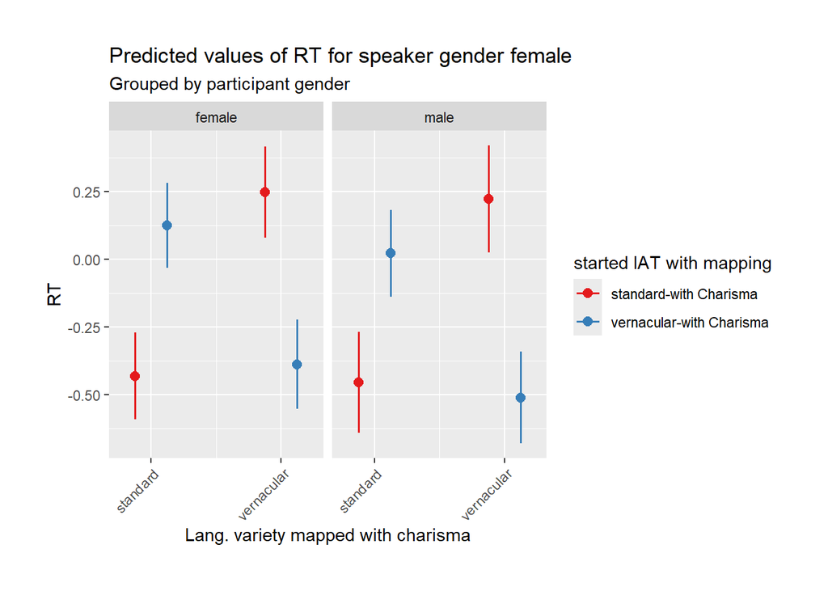

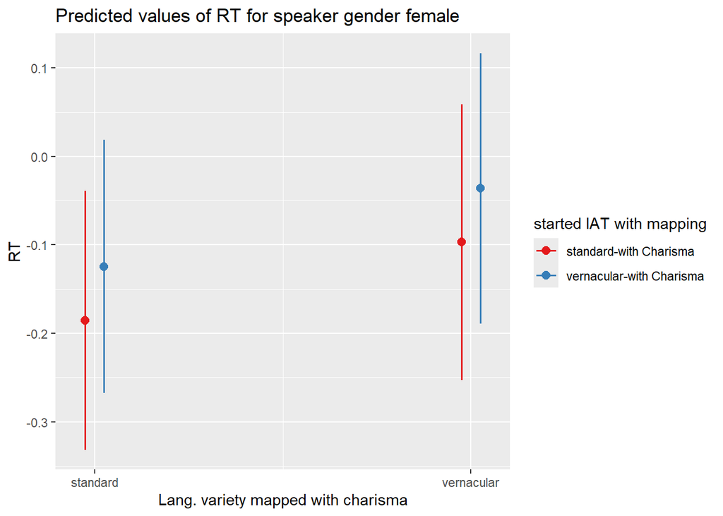

##### male speakers  
language variety impact between 2nd blocks of different study types only approaching significance

```
## Linear mixed model fit by REML. t-tests use Satterthwaite's method [
## lmerModLmerTest]
## Formula: penal_RTs ~ charisma_lang_var * start_iat * pp_gender + trialcount +
##     age + leadership_lang_var + +stim_cat + (charisma_lang_var |
##     bilendi_id) + (start_iat | stimulus_ID)
##    Data: Four_Out_male
## Control: lmerControl(optimizer = "bobyqa", optCtrl = list(maxfun = 2e+05))
##
## REML criterion at convergence: 81513.2
##
## Scaled residuals:
##     Min      1Q  Median      3Q     Max
## -5.9692 -0.5939 -0.1246  0.5089 12.7851
##
## Random effects:
##  Groups      Name                              Variance Std.Dev. Corr
##  bilendi_id  (Intercept)                       0.251196 0.50119
##              charisma_lang_varvernacular       0.266545 0.51628  -0.28
##  stimulus_ID (Intercept)                       0.019649 0.14017
##              start_iatvernacular-with Charisma 0.003139 0.05603  -0.39
##  Residual                                      0.669744 0.81838
## Number of obs: 32603, groups:  bilendi_id, 272; stimulus_ID, 156
##
## Fixed effects:
##                                                                               Estimate
## (Intercept)                                                                  3.999e-01
## charisma_lang_varvernacular                                                  8.917e-01
## start_iatvernacular-with Charisma                                            7.220e-01
## pp_gendermale                                                                1.154e-01
## trialcount                                                                  -8.235e-03
## age                                                                          1.174e-01
## leadership_lang_var2                                                         1.283e-01
## stim_catleadership                                                           1.932e-01
## charisma_lang_varvernacular:start_iatvernacular-with Charisma               -1.490e+00
## charisma_lang_varvernacular:pp_gendermale                                   -1.092e-01
## start_iatvernacular-with Charisma:pp_gendermale                             -1.192e-01
## charisma_lang_varvernacular:start_iatvernacular-with Charisma:pp_gendermale  8.717e-02
##                                                                             Std. Error
## (Intercept)                                                                  7.587e-02
## charisma_lang_varvernacular                                                  7.172e-02
```

[output cut: 75 more lines]

```
## chrsm_ln_:_  0.182 -0.662 -0.152 -0.304  0.000  0.000  0.000  0.000  0.462
## strt_tv-C:_  0.464 -0.148 -0.675 -0.738  0.000 -0.084 -0.072  0.000  0.187
## chr__:_-C:_ -0.134  0.488  0.203  0.224  0.000  0.000  0.000  0.000 -0.620
##             ch__:_ s_-C:_
## chrsm_lng_v
## strt_tvrn-C
## pp_genderml
## trialcount
## age
## ldrshp_ln_2
## stm_ctldrsh
## chrsm__:_-C
## chrsm_ln_:_
## strt_tv-C:_  0.223
## chr__:_-C:_ -0.737 -0.303
```

```
## Type III Analysis of Variance Table with Satterthwaite's method
##                                       Sum Sq Mean Sq NumDF DenDF  F value
## charisma_lang_var                       8.07    8.07     1   268  12.0553
## start_iat                               0.66    0.66     1   268   0.9880
## pp_gender                               0.09    0.09     1   265   0.1415
## trialcount                            660.89  660.89     1 31914 986.7813
## age                                    11.23   11.23     1   266  16.7683
## leadership_lang_var                     3.01    3.01     1   274   4.4950
## stim_cat                               35.65   35.65     1   135  53.2232
## charisma_lang_var:start_iat           215.22  215.22     1   617 321.3399
## charisma_lang_var:pp_gender             0.67    0.67     1   268   1.0049
## start_iat:pp_gender                     0.25    0.25     1   266   0.3794
## charisma_lang_var:start_iat:pp_gender   0.30    0.30     1   268   0.4431
##                                          Pr(>F)
## charisma_lang_var                      0.000602 ***
## start_iat                              0.321115
## pp_gender                              0.707050
## trialcount                            < 2.2e-16 ***
## age                                   5.608e-05 ***
## leadership_lang_var                    0.034893 *
## stim_cat                              2.268e-11 ***
## charisma_lang_var:start_iat           < 2.2e-16 ***
## charisma_lang_var:pp_gender            0.317040
## start_iat:pp_gender                    0.538435
## charisma_lang_var:start_iat:pp_gender  0.506199
## ---
## Signif. codes:  0 '***' 0.001 '**' 0.01 '*' 0.05 '.' 0.1 ' ' 1
```

```
## Linear mixed model fit by REML. t-tests use Satterthwaite's method [
## lmerModLmerTest]
## Formula: penal_RTs ~ charisma_lang_var * pp_gender + trialcount + age +
##     leadership_lang_var + +stim_cat + (charisma_lang_var | bilendi_id) +
##     (start_iat | stimulus_ID)
##    Data: Four_Out_male
## Control: lmerControl(optimizer = "bobyqa", optCtrl = list(maxfun = 2e+05))
##
## REML criterion at convergence: 81753.1
##
## Scaled residuals:
##     Min      1Q  Median      3Q     Max
## -6.0468 -0.5927 -0.1262  0.5080 12.6994
##
## Random effects:
##  Groups      Name                              Variance Std.Dev. Corr
##  bilendi_id  (Intercept)                       0.318466 0.56433
##              charisma_lang_varvernacular       0.602922 0.77648  -0.51
##  stimulus_ID (Intercept)                       0.019700 0.14036
##              start_iatvernacular-with Charisma 0.003129 0.05594  -0.40
##  Residual                                      0.670509 0.81885
## Number of obs: 32603, groups:  bilendi_id, 272; stimulus_ID, 156
##
## Fixed effects:
##                                             Estimate Std. Error         df
## (Intercept)                                6.088e-01  6.557e-02  5.158e+02
## charisma_lang_varvernacular                8.626e-02  6.687e-02  2.135e+02
## pp_gendermale                              4.401e-02  6.969e-02  2.530e+02
## trialcount                                -6.648e-03  2.346e-04  4.839e+03
## age                                        1.219e-01  2.866e-02  2.679e+02
## leadership_lang_var2                       1.247e-01  6.063e-02  2.758e+02
## stim_catleadership                         1.932e-01  2.649e-02  1.353e+02
## charisma_lang_varvernacular:pp_gendermale -4.779e-02  9.594e-02  2.131e+02
##                                           t value Pr(>|t|)
## (Intercept)                                 9.285  < 2e-16 ***
## charisma_lang_varvernacular                 1.290   0.1985
## pp_gendermale                               0.632   0.5283
## trialcount                                -28.331  < 2e-16 ***
## age                                         4.253 2.92e-05 ***
## leadership_lang_var2                        2.057   0.0406 *
## stim_catleadership                          7.294 2.29e-11 ***
## charisma_lang_varvernacular:pp_gendermale  -0.498   0.6189
## ---
## Signif. codes:  0 '***' 0.001 '**' 0.01 '*' 0.05 '.' 0.1 ' ' 1
##
## Correlation of Fixed Effects:
##             (Intr) chrs__ pp_gnd trlcnt age    ldr__2 stm_ct
## chrsm_lng_v -0.398
## pp_genderml -0.514  0.362
## trialcount  -0.429  0.032  0.003
## age          0.033  0.000 -0.026  0.005
## ldrshp_ln_2 -0.387  0.000 -0.010 -0.002  0.037
## stm_ctldrsh -0.296  0.000  0.000  0.001  0.000 -0.004
## chrsm_ln_:_  0.270 -0.696 -0.519 -0.005  0.000  0.000  0.000
```

```
## Type III Analysis of Variance Table with Satterthwaite's method
##                             Sum Sq Mean Sq NumDF  DenDF  F value    Pr(>F)
## charisma_lang_var             1.13    1.13     1  213.7   1.6875    0.1953
## pp_gender                     0.07    0.07     1  267.5   0.1098    0.7406
## trialcount                  538.18  538.18     1 4838.8 802.6364 < 2.2e-16 ***
## age                          12.13   12.13     1  267.9  18.0847 2.922e-05 ***
## leadership_lang_var           2.84    2.84     1  275.8   4.2324    0.0406 *
## stim_cat                     35.67   35.67     1  135.3  53.1965 2.293e-11 ***
## charisma_lang_var:pp_gender   0.17    0.17     1  213.1   0.2481    0.6189
## ---
## Signif. codes:  0 '***' 0.001 '**' 0.01 '*' 0.05 '.' 0.1 ' ' 1
```

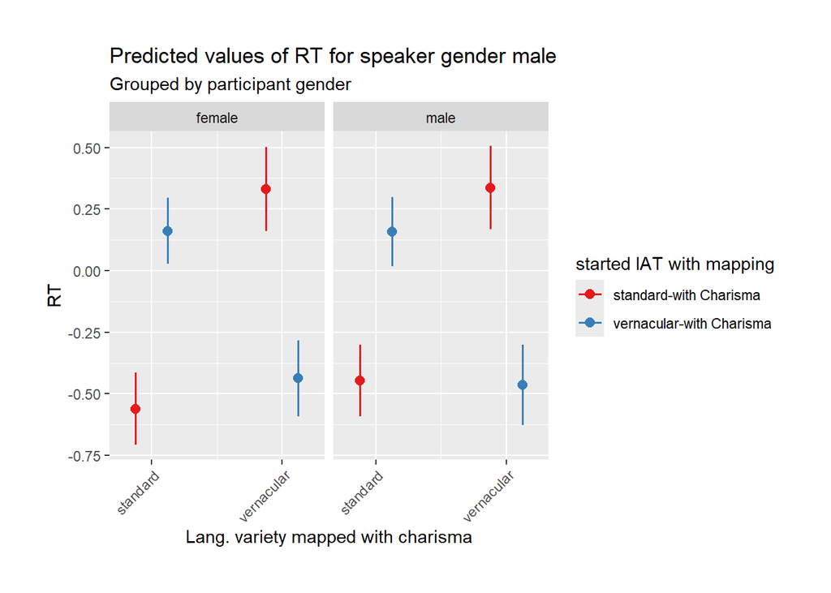

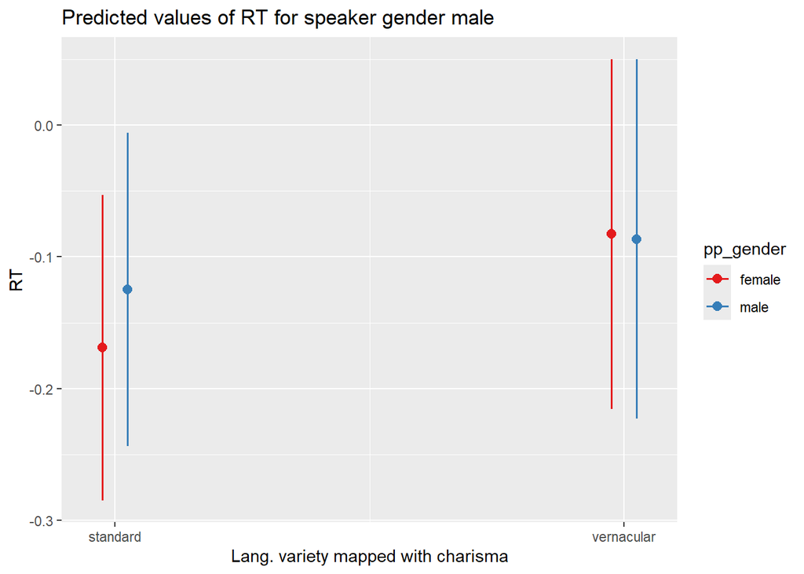

```
## Linear mixed model fit by REML. t-tests use Satterthwaite's method [
## lmerModLmerTest]
## Formula: penal_RTs ~ charisma_lang_var * start_iat + trialcount + stim_cat +
##     age + leadership_lang_var + populism_dim:charisma_lang_var +
##     ideology:charisma_lang_var + voting_behaviour:charisma_lang_var +
##     (charisma_lang_var | bilendi_id) + (start_iat | stimulus_ID)
##    Data: Four_Out
## Control: lmerControl(optimizer = "bobyqa", optCtrl = list(maxfun = 2e+05))
##
## REML criterion at convergence: 153730.1
##
## Scaled residuals:
##    Min     1Q Median     3Q    Max
## -6.293 -0.620 -0.121  0.548 13.530
##
## Random effects:
##  Groups      Name                              Variance Std.Dev. Corr
##  bilendi_id  (Intercept)                       0.299922 0.54765
##              charisma_lang_varvernacular       0.206492 0.45441  -0.25
##  stimulus_ID (Intercept)                       0.016581 0.12877
##              start_iatvernacular-with Charisma 0.001885 0.04341  -0.35
##  Residual                                      0.598256 0.77347
## Number of obs: 64365, groups:  bilendi_id, 537; stimulus_ID, 303
##
## Fixed effects:
##                                                                 Estimate
## (Intercept)                                                    4.685e-01
## charisma_lang_varvernacular                                    6.851e-01
## start_iatvernacular-with Charisma                              5.943e-01
## trialcount                                                    -7.813e-03
## stim_catleadership                                             1.862e-01
## age                                                            1.050e-01
## leadership_lang_var2                                           8.048e-02
## charisma_lang_varvernacular:start_iatvernacular-with Charisma -1.326e+00
## charisma_lang_varstandard:populism_dim                        -1.674e-02
## charisma_lang_varvernacular:populism_dim                       1.739e-02
## charisma_lang_varstandard:ideology                            -3.367e-02
## charisma_lang_varvernacular:ideology                          -3.918e-02
## charisma_lang_varstandard:voting_behaviourandere              -1.206e-01
## charisma_lang_varvernacular:voting_behaviourandere            -2.566e-02
```

[output cut: 127 more lines]

```
## charisma_lang_varvernacular:voting_behaviourDIE LINKE
## charisma_lang_varstandard:voting_behaviourFDP
## charisma_lang_varvernacular:voting_behaviourFDP
## charisma_lang_varstandard:voting_behaviourGRüNE
## charisma_lang_varvernacular:voting_behaviourGRüNE
## charisma_lang_varstandard:voting_behaviourinvalid
## charisma_lang_varvernacular:voting_behaviourinvalid
## charisma_lang_varstandard:voting_behaviourNichtwähler
## charisma_lang_varvernacular:voting_behaviourNichtwähler
## charisma_lang_varstandard:voting_behaviourno_answer
## charisma_lang_varvernacular:voting_behaviourno_answer
## charisma_lang_varstandard:voting_behaviourSPD
## charisma_lang_varvernacular:voting_behaviourSPD
## ---
## Signif. codes:  0 '***' 0.001 '**' 0.01 '*' 0.05 '.' 0.1 ' ' 1
```

```
##
## Correlation matrix not shown by default, as p = 30 > 12.
## Use print(x, correlation=TRUE)  or
##     vcov(x)        if you need it
```

```
## Type III Analysis of Variance Table with Satterthwaite's method
##                                     Sum Sq Mean Sq NumDF DenDF   F value
## charisma_lang_var                     0.06    0.06     1   524    0.1074
## start_iat                             1.26    1.26     1   524    2.1024
## trialcount                         1174.61 1174.61     1 63035 1963.3937
## stim_cat                             66.79   66.79     1   263  111.6368
## age                                  11.67   11.67     1   522   19.5103
## leadership_lang_var                   1.71    1.71     1   532    2.8621
## charisma_lang_var:start_iat         385.52  385.52     1  1311  644.4032
## charisma_lang_var:populism_dim        1.41    0.71     2   522    1.1796
## charisma_lang_var:ideology            0.99    0.50     2   522    0.8279
## charisma_lang_var:voting_behaviour   11.09    0.62    18   522    1.0300
##                                       Pr(>F)
## charisma_lang_var                    0.74330
## start_iat                            0.14766
## trialcount                         < 2.2e-16 ***
## stim_cat                           < 2.2e-16 ***
## age                                1.217e-05 ***
## leadership_lang_var                  0.09128 .
## charisma_lang_var:start_iat        < 2.2e-16 ***
## charisma_lang_var:populism_dim       0.30821
## charisma_lang_var:ideology           0.43755
## charisma_lang_var:voting_behaviour   0.42342
## ---
## Signif. codes:  0 '***' 0.001 '**' 0.01 '*' 0.05 '.' 0.1 ' ' 1
```

### 3.4.2. Populism

#### GLMs all data

*no impact of populism measure, populism_all, populism_dim* First, using variable populism_all (mean of populism questionnaire items 1-3)

```
## Linear mixed model fit by REML. t-tests use Satterthwaite's method [
## lmerModLmerTest]
## Formula:
## penal_RTs ~ charisma_lang_var * populism_all + start_iat + trialcount +
##     age + leadership_lang_var + (charisma_lang_var | bilendi_id) +
##     (start_iat | stimulus_ID)
##    Data: Four_Out
## Control: lmerControl(optimizer = "bobyqa", optCtrl = list(maxfun = 2e+05))
##
## REML criterion at convergence: 154269.3
##
## Scaled residuals:
##     Min      1Q  Median      3Q     Max
## -6.3944 -0.6195 -0.1255  0.5498 13.4543
##
## Random effects:
##  Groups      Name                              Variance Std.Dev. Corr
##  bilendi_id  (Intercept)                       0.32567  0.57068
##              charisma_lang_varvernacular       0.47857  0.69179  -0.36
##  stimulus_ID (Intercept)                       0.02149  0.14659
##              start_iatvernacular-with Charisma 0.00197  0.04439  -0.05
##  Residual                                      0.59896  0.77392
## Number of obs: 64365, groups:  bilendi_id, 537; stimulus_ID, 303
##
## Fixed effects:
##                                            Estimate Std. Error         df
## (Intercept)                               6.241e-01  4.481e-02  6.515e+02
## charisma_lang_varvernacular               5.364e-02  3.049e-02  4.116e+02
## populism_all                             -1.749e-02  2.504e-02  4.095e+02
## start_iatvernacular-with Charisma         1.347e-01  4.702e-02  5.425e+02
## trialcount                               -6.249e-03  1.566e-04  8.462e+03
## age                                       1.054e-01  2.326e-02  5.320e+02
## leadership_lang_var2                      9.602e-02  4.724e-02  5.430e+02
## charisma_lang_varvernacular:populism_all  2.052e-02  3.049e-02  4.107e+02
##                                          t value Pr(>|t|)
## (Intercept)                               13.928  < 2e-16 ***
## charisma_lang_varvernacular                1.759  0.07932 .
## populism_all                              -0.698  0.48530
## start_iatvernacular-with Charisma          2.866  0.00432 **
## trialcount                               -39.905  < 2e-16 ***
## age                                        4.531 7.26e-06 ***
## leadership_lang_var2                       2.033  0.04255 *
## charisma_lang_varvernacular:populism_all   0.673  0.50137
## ---
## Signif. codes:  0 '***' 0.001 '**' 0.01 '*' 0.05 '.' 0.1 ' ' 1
##
## Correlation of Fixed Effects:
##             (Intr) chrs__ pplsm_ str_-C trlcnt age    ldr__2
## chrsm_lng_v -0.220
## populism_ll  0.001 -0.001
## strt_tvrn-C -0.526 -0.004  0.001
## trialcount  -0.350  0.037  0.000 -0.117
## age         -0.027  0.000  0.035  0.023  0.000
## ldrshp_ln_2 -0.462  0.000 -0.001  0.021  0.000  0.033
## chrsm_ln_:_  0.000  0.002 -0.371  0.000  0.000  0.000  0.000
```

```
## Type III Analysis of Variance Table with Satterthwaite's method
##                                Sum Sq Mean Sq NumDF  DenDF   F value    Pr(>F)
## charisma_lang_var                1.85    1.85     1  411.6    3.0941  0.079321
## populism_all                     0.05    0.05     1  464.3    0.0907  0.763452
## start_iat                        4.92    4.92     1  542.5    8.2128  0.004321
## trialcount                     953.81  953.81     1 8462.3 1592.4413 < 2.2e-16
## age                             12.30   12.30     1  532.0   20.5273 7.264e-06
## leadership_lang_var              2.48    2.48     1  543.0    4.1326  0.042551
## charisma_lang_var:populism_all   0.27    0.27     1  410.7    0.4528  0.501371
##
## charisma_lang_var              .
## populism_all
## start_iat                      **
## trialcount                     ***
## age                            ***
## leadership_lang_var            *
## charisma_lang_var:populism_all
## ---
## Signif. codes:  0 '***' 0.001 '**' 0.01 '*' 0.05 '.' 0.1 ' ' 1
```

Second, using variable populism_dim (dimension 1 of Populism PCA)

```
## Linear mixed model fit by REML. t-tests use Satterthwaite's method [
## lmerModLmerTest]
## Formula:
## penal_RTs ~ charisma_lang_var * populism_dim + trialcount + start_iat +
##     age + leadership_lang_var + (charisma_lang_var | bilendi_id) +
##     (start_iat | stimulus_ID)
##    Data: Four_Out
## Control: lmerControl(optimizer = "bobyqa", optCtrl = list(maxfun = 2e+05))
##
## REML criterion at convergence: 154268.7
##
## Scaled residuals:
##     Min      1Q  Median      3Q     Max
## -6.3945 -0.6195 -0.1254  0.5500 13.4546
##
## Random effects:
##  Groups      Name                              Variance Std.Dev. Corr
##  bilendi_id  (Intercept)                       0.32513  0.57021
##              charisma_lang_varvernacular       0.47835  0.69163  -0.36
##  stimulus_ID (Intercept)                       0.02149  0.14659
##              start_iatvernacular-with Charisma 0.00197  0.04438  -0.05
##  Residual                                      0.59896  0.77392
## Number of obs: 64365, groups:  bilendi_id, 537; stimulus_ID, 303
##
## Fixed effects:
##                                            Estimate Std. Error         df
## (Intercept)                               6.234e-01  4.478e-02  6.514e+02
## charisma_lang_varvernacular               5.364e-02  3.049e-02  4.115e+02
## populism_dim                             -2.530e-02  2.503e-02  4.105e+02
## trialcount                               -6.248e-03  1.566e-04  8.456e+03
## start_iatvernacular-with Charisma         1.357e-01  4.701e-02  5.425e+02
## age                                       1.046e-01  2.328e-02  5.320e+02
## leadership_lang_var2                      9.633e-02  4.722e-02  5.430e+02
## charisma_lang_varvernacular:populism_dim  2.450e-02  3.047e-02  4.106e+02
##                                          t value Pr(>|t|)
## (Intercept)                               13.919  < 2e-16 ***
## charisma_lang_varvernacular                1.759  0.07925 .
## populism_dim                              -1.011  0.31284
## trialcount                               -39.904  < 2e-16 ***
## start_iatvernacular-with Charisma          2.888  0.00404 **
## age                                        4.494 8.58e-06 ***
## leadership_lang_var2                       2.040  0.04184 *
## charisma_lang_varvernacular:populism_dim   0.804  0.42188
## ---
## Signif. codes:  0 '***' 0.001 '**' 0.01 '*' 0.05 '.' 0.1 ' ' 1
##
## Correlation of Fixed Effects:
##             (Intr) chrs__ pplsm_ trlcnt str_-C age    ldr__2
## chrsm_lng_v -0.219
## populism_dm  0.002 -0.001
## trialcount  -0.350  0.037  0.000
## strt_tvrn-C -0.526 -0.004  0.003 -0.118
## age         -0.027  0.000  0.058  0.000  0.023
## ldrshp_ln_2 -0.463  0.000 -0.006  0.000  0.021  0.033
## chrsm_ln_:_  0.000  0.002 -0.370 -0.001  0.000  0.000  0.000
```

```
## Type III Analysis of Variance Table with Satterthwaite's method
##                                Sum Sq Mean Sq NumDF  DenDF   F value    Pr(>F)
## charisma_lang_var                1.85    1.85     1  411.5    3.0955  0.079251
## populism_dim                     0.18    0.18     1  464.1    0.2951  0.587220
## trialcount                     953.76  953.76     1 8456.0 1592.3684 < 2.2e-16
## start_iat                        4.99    4.99     1  542.5    8.3377  0.004038
## age                             12.10   12.10     1  532.0   20.1971 8.578e-06
## leadership_lang_var              2.49    2.49     1  543.0    4.1615  0.041836
## charisma_lang_var:populism_dim   0.39    0.39     1  410.6    0.6464  0.421876
##
## charisma_lang_var              .
## populism_dim
## trialcount                     ***
## start_iat                      **
## age                            ***
## leadership_lang_var            *
## charisma_lang_var:populism_dim
## ---
## Signif. codes:  0 '***' 0.001 '**' 0.01 '*' 0.05 '.' 0.1 ' ' 1
```

```
## Linear mixed model fit by REML. t-tests use Satterthwaite's method [
## lmerModLmerTest]
## Formula: penal_RTs ~ charisma_lang_var * start_iat * populism4 + trialcount +
##     age + leadership_lang_var + (charisma_lang_var | bilendi_id) +
##     (start_iat | stimulus_ID)
##    Data: Four_Out
## Control: lmerControl(optimizer = "bobyqa", optCtrl = list(maxfun = 2e+05))
##
## REML criterion at convergence: 153777
##
## Scaled residuals:
##     Min      1Q  Median      3Q     Max
## -6.2816 -0.6200 -0.1219  0.5502 13.5464
##
## Random effects:
##  Groups      Name                              Variance Std.Dev. Corr
##  bilendi_id  (Intercept)                       0.297973 0.54587
##              charisma_lang_varvernacular       0.207320 0.45532  -0.24
##  stimulus_ID (Intercept)                       0.021469 0.14652
##              start_iatvernacular-with Charisma 0.001939 0.04403  -0.05
##  Residual                                      0.598221 0.77345
## Number of obs: 64365, groups:  bilendi_id, 537; stimulus_ID, 303
##
## Fixed effects:
##                                                                           Estimate
## (Intercept)                                                              5.633e-01
## charisma_lang_varvernacular                                              7.582e-01
## start_iatvernacular-with Charisma                                        5.929e-01
## populism4                                                               -8.429e-02
## trialcount                                                              -7.814e-03
## age                                                                      9.851e-02
## leadership_lang_var2                                                     9.615e-02
## charisma_lang_varvernacular:start_iatvernacular-with Charisma           -1.326e+00
## charisma_lang_varvernacular:populism4                                    1.821e-02
## start_iatvernacular-with Charisma:populism4                              8.752e-02
## charisma_lang_varvernacular:start_iatvernacular-with Charisma:populism4  5.062e-03
##                                                                         Std. Error
## (Intercept)                                                              4.362e-02
## charisma_lang_varvernacular                                              3.424e-02
## start_iatvernacular-with Charisma                                        5.071e-02
```

[output cut: 67 more lines]

```
## chrsm__:_-C -0.051 -0.799 -0.385 -0.001  0.609  0.000  0.000
## chrsm_ln_:4  0.001 -0.006 -0.001 -0.257  0.000  0.000  0.000  0.004
## strt_tv-C:4  0.011 -0.001 -0.003 -0.746  0.000 -0.088 -0.012  0.000    0.192
## chr__:_-C:4 -0.001  0.004  0.000  0.191  0.000  0.000  0.000 -0.001   -0.743
##             s_-C:4
## chrsm_lng_v
## strt_tvrn-C
## populism4
## trialcount
## age
## ldrshp_ln_2
## chrsm__:_-C
## chrsm_ln_:4
## strt_tv-C:4
## chr__:_-C:4 -0.258
```

```
## Type III Analysis of Variance Table with Satterthwaite's method
##                                        Sum Sq Mean Sq NumDF DenDF   F value
## charisma_lang_var                       12.78   12.78     1   533   21.3557
## start_iat                                1.31    1.31     1   533    2.1889
## populism4                                0.96    0.96     1   530    1.6080
## trialcount                            1174.59 1174.59     1 63022 1963.4683
## age                                     10.62   10.62     1   531   17.7491
## leadership_lang_var                      2.50    2.50     1   542    4.1716
## charisma_lang_var:start_iat            387.58  387.58     1  1344  647.8825
## charisma_lang_var:populism4              0.60    0.60     1   533    1.0043
## start_iat:populism4                      2.16    2.16     1   530    3.6029
## charisma_lang_var:start_iat:populism4    0.01    0.01     1   533    0.0150
##                                          Pr(>F)
## charisma_lang_var                     4.791e-06 ***
## start_iat                               0.13960
## populism4                               0.20533
## trialcount                            < 2.2e-16 ***
## age                                   2.961e-05 ***
## leadership_lang_var                     0.04159 *
## charisma_lang_var:start_iat           < 2.2e-16 ***
## charisma_lang_var:populism4             0.31672
## start_iat:populism4                     0.05822 .
## charisma_lang_var:start_iat:populism4   0.90270
## ---
## Signif. codes:  0 '***' 0.001 '**' 0.01 '*' 0.05 '.' 0.1 ' ' 1
```

#### Populism subset analyes

difference between 2nd blocks (charisma_lang_var*start_iat), i.e.impact of vernacular when starting with standard-with Charisma vs. impact of standard variety when starting with vernacular-with Charisma) is significant in low populism subset but not significant in high populism subset

```
## Linear mixed model fit by REML. t-tests use Satterthwaite's method [
## lmerModLmerTest]
## Formula: penal_RTs ~ charisma_lang_var * start_iat + trialcount + age +
##     leadership_lang_var + (charisma_lang_var | bilendi_id) +
##     (start_iat | stimulus_ID)
##    Data: Four_Out_high_pop
## Control: lmerControl(optimizer = "bobyqa", optCtrl = list(maxfun = 2e+05))
##
## REML criterion at convergence: 79755.2
##
## Scaled residuals:
##     Min      1Q  Median      3Q     Max
## -6.3516 -0.6123 -0.1105  0.5567 13.5692
##
## Random effects:
##  Groups      Name                              Variance Std.Dev. Corr
##  stimulus_ID (Intercept)                       0.01956  0.13985
##              start_iatvernacular-with Charisma 0.00432  0.06572  -0.05
##  bilendi_id  (Intercept)                       0.33499  0.57878
##              charisma_lang_varvernacular       0.21637  0.46516  -0.16
##  Residual                                      0.55805  0.74703
## Number of obs: 34272, groups:  stimulus_ID, 303; bilendi_id, 286
##
## Fixed effects:
##                                                                 Estimate
## (Intercept)                                                    5.021e-01
## charisma_lang_varvernacular                                    7.187e-01
## start_iatvernacular-with Charisma                              5.641e-01
## trialcount                                                    -7.097e-03
## age                                                            7.975e-02
## leadership_lang_var2                                           5.618e-02
## charisma_lang_varvernacular:start_iatvernacular-with Charisma -1.224e+00
##                                                               Std. Error
## (Intercept)                                                    6.277e-02
## charisma_lang_varvernacular                                    4.716e-02
## start_iatvernacular-with Charisma                              7.290e-02
## trialcount                                                     2.337e-04
## age                                                            3.415e-02
## leadership_lang_var2                                           6.912e-02
## charisma_lang_varvernacular:start_iatvernacular-with Charisma  7.126e-02
```

[output cut: 20 more lines]

```
## trialcount                                                    ***
## age                                                           *
## leadership_lang_var2
## charisma_lang_varvernacular:start_iatvernacular-with Charisma ***
## ---
## Signif. codes:  0 '***' 0.001 '**' 0.01 '*' 0.05 '.' 0.1 ' ' 1
##
## Correlation of Fixed Effects:
##             (Intr) chrs__ str_-C trlcnt age    ldr__2
## chrsm_lng_v -0.014
## strt_tvrn-C -0.511  0.241
## trialcount  -0.262 -0.446 -0.289
## age         -0.014  0.000  0.020  0.000
## ldrshp_ln_2 -0.501  0.000  0.031  0.000  0.003
## chrsm__:_-C -0.068 -0.793 -0.309  0.590  0.000  0.000
```

```
## Type III Analysis of Variance Table with Satterthwaite's method
##                             Sum Sq Mean Sq NumDF DenDF  F value    Pr(>F)
## charisma_lang_var             7.65    7.65     1   284  13.7148 0.0002557 ***
## start_iat                     0.26    0.26     1   283   0.4658 0.4955018
## trialcount                  514.60  514.60     1 33476 922.1280 < 2.2e-16 ***
## age                           3.04    3.04     1   282   5.4522 0.0202449 *
## leadership_lang_var           0.37    0.37     1   286   0.6607 0.4169942
## charisma_lang_var:start_iat 164.76  164.76     1   667 295.2380 < 2.2e-16 ***
## ---
## Signif. codes:  0 '***' 0.001 '**' 0.01 '*' 0.05 '.' 0.1 ' ' 1
```

```
## Note: D.f. calculations have been disabled because the number of observations exceeds 3000.
## To enable adjustments, add the argument 'pbkrtest.limit = 34272' (or larger)
## [or, globally, 'set emm_options(pbkrtest.limit = 34272)' or larger];
## but be warned that this may result in large computation time and memory use.
```

```
## Note: D.f. calculations have been disabled because the number of observations exceeds 3000.
## To enable adjustments, add the argument 'lmerTest.limit = 34272' (or larger)
## [or, globally, 'set emm_options(lmerTest.limit = 34272)' or larger];
## but be warned that this may result in large computation time and memory use.
```

```
## $emmeans
##  charisma_lang_var start_iat                emmean     SE  df asymp.LCL
##  standard          standard-with Charisma   -0.289 0.0529 Inf    -0.393
##  vernacular        standard-with Charisma    0.429 0.0617 Inf     0.308
##  standard          vernacular-with Charisma  0.275 0.0496 Inf     0.178
##  vernacular        vernacular-with Charisma -0.231 0.0576 Inf    -0.344
##  asymp.UCL
##     -0.186
##      0.550
##      0.372
##     -0.118
##
## Results are averaged over the levels of: leadership_lang_var
## Degrees-of-freedom method: asymptotic
## Confidence level used: 0.95
##
## $contrasts
##  contrast
##  (standard standard-with Charisma) - (vernacular standard-with Charisma)
##  (standard standard-with Charisma) - (standard vernacular-with Charisma)
##  (standard standard-with Charisma) - (vernacular vernacular-with Charisma)
##  (vernacular standard-with Charisma) - (standard vernacular-with Charisma)
##  (vernacular standard-with Charisma) - (vernacular vernacular-with Charisma)
##  (standard vernacular-with Charisma) - (vernacular vernacular-with Charisma)
##  estimate     SE  df z.ratio p.value
##   -0.7187 0.0472 Inf -15.240  <.0001
##   -0.5641 0.0729 Inf  -7.738  <.0001
##   -0.0584 0.0757 Inf  -0.771  0.8677
##    0.1547 0.0767 Inf   2.017  0.1815
##    0.6604 0.0848 Inf   7.792  <.0001
##    0.5057 0.0444 Inf  11.396  <.0001
##
## Results are averaged over the levels of: leadership_lang_var
## Degrees-of-freedom method: asymptotic
## P value adjustment: tukey method for comparing a family of 4 estimates
```

```
## Linear mixed model fit by REML. t-tests use Satterthwaite's method [
## lmerModLmerTest]
## Formula: penal_RTs ~ charisma_lang_var * start_iat + trialcount + age +
##     leadership_lang_var + (charisma_lang_var | bilendi_id) +
##     (start_iat | stimulus_ID)
##    Data: Four_Out_low_pop
## Control: lmerControl(optimizer = "bobyqa", optCtrl = list(maxfun = 2e+05))
##
## REML criterion at convergence: 74444.3
##
## Scaled residuals:
##     Min      1Q  Median      3Q     Max
## -4.8443 -0.6288 -0.1344  0.5461 12.3934
##
## Random effects:
##  Groups      Name                              Variance Std.Dev. Corr
##  stimulus_ID (Intercept)                       0.026405 0.16250
##              start_iatvernacular-with Charisma 0.001647 0.04058  -0.01
##  bilendi_id  (Intercept)                       0.256145 0.50611
##              charisma_lang_varvernacular       0.196135 0.44287  -0.36
##  Residual                                      0.649757 0.80608
## Number of obs: 30093, groups:  stimulus_ID, 303; bilendi_id, 251
##
## Fixed effects:
##                                                                 Estimate
## (Intercept)                                                    6.404e-01
## charisma_lang_varvernacular                                    8.087e-01
## start_iatvernacular-with Charisma                              6.307e-01
## trialcount                                                    -8.700e-03
## age                                                            1.360e-01
## leadership_lang_var2                                           1.236e-01
## charisma_lang_varvernacular:start_iatvernacular-with Charisma -1.452e+00
##                                                               Std. Error
## (Intercept)                                                    5.873e-02
## charisma_lang_varvernacular                                    4.982e-02
## start_iatvernacular-with Charisma                              6.988e-02
## trialcount                                                     2.691e-04
## age                                                            3.023e-02
## leadership_lang_var2                                           6.174e-02
## charisma_lang_varvernacular:start_iatvernacular-with Charisma  7.645e-02
```

[output cut: 20 more lines]

```
## trialcount                                                    ***
## age                                                           ***
## leadership_lang_var2                                          *
## charisma_lang_varvernacular:start_iatvernacular-with Charisma ***
## ---
## Signif. codes:  0 '***' 0.001 '**' 0.01 '*' 0.05 '.' 0.1 ' ' 1
##
## Correlation of Fixed Effects:
##             (Intr) chrs__ str_-C trlcnt age    ldr__2
## chrsm_lng_v -0.116
## strt_tvrn-C -0.457  0.398
## trialcount  -0.323 -0.486 -0.346
## age         -0.041  0.000  0.021  0.000
## ldrshp_ln_2 -0.441  0.000  0.006  0.000  0.064
## chrsm__:_-C -0.027 -0.806 -0.496  0.633  0.000  0.000
```

```
## Type III Analysis of Variance Table with Satterthwaite's method
##                             Sum Sq Mean Sq NumDF   DenDF   F value    Pr(>F)
## charisma_lang_var             5.06    5.06     1   248.8    7.7810  0.005688
## start_iat                     1.60    1.60     1   247.4    2.4677  0.117488
## trialcount                  679.22  679.22     1 29375.6 1045.3440 < 2.2e-16
## age                          13.15   13.15     1   246.9   20.2356 1.055e-05
## leadership_lang_var           2.61    2.61     1   253.0    4.0096  0.046309
## charisma_lang_var:start_iat 234.52  234.52     1   691.7  360.9280 < 2.2e-16
##
## charisma_lang_var           **
## start_iat
## trialcount                  ***
## age                         ***
## leadership_lang_var         *
## charisma_lang_var:start_iat ***
## ---
## Signif. codes:  0 '***' 0.001 '**' 0.01 '*' 0.05 '.' 0.1 ' ' 1
```

```
## Note: D.f. calculations have been disabled because the number of observations exceeds 3000.
## To enable adjustments, add the argument 'pbkrtest.limit = 30093' (or larger)
## [or, globally, 'set emm_options(pbkrtest.limit = 30093)' or larger];
## but be warned that this may result in large computation time and memory use.
```

```
## Note: D.f. calculations have been disabled because the number of observations exceeds 3000.
## To enable adjustments, add the argument 'lmerTest.limit = 30093' (or larger)
## [or, globally, 'set emm_options(lmerTest.limit = 30093)' or larger];
## but be warned that this may result in large computation time and memory use.
```

```
## $emmeans
##  charisma_lang_var start_iat                emmean     SE  df asymp.LCL
##  standard          standard-with Charisma   -0.303 0.0509 Inf    -0.402
##  vernacular        standard-with Charisma    0.506 0.0537 Inf     0.401
##  standard          vernacular-with Charisma  0.328 0.0473 Inf     0.235
##  vernacular        vernacular-with Charisma -0.316 0.0499 Inf    -0.413
##  asymp.UCL
##     -0.203
##      0.611
##      0.421
##     -0.218
##
## Results are averaged over the levels of: leadership_lang_var
## Degrees-of-freedom method: asymptotic
## Confidence level used: 0.95
##
## $contrasts
##  contrast
##  (standard standard-with Charisma) - (vernacular standard-with Charisma)
##  (standard standard-with Charisma) - (standard vernacular-with Charisma)
##  (standard standard-with Charisma) - (vernacular vernacular-with Charisma)
##  (vernacular standard-with Charisma) - (standard vernacular-with Charisma)
##  (vernacular standard-with Charisma) - (vernacular vernacular-with Charisma)
##  (standard vernacular-with Charisma) - (vernacular vernacular-with Charisma)
##  estimate     SE  df z.ratio p.value
##    -0.809 0.0498 Inf -16.232  <.0001
##    -0.631 0.0699 Inf  -9.026  <.0001
##     0.013 0.0674 Inf   0.193  0.9975
##     0.178 0.0678 Inf   2.626  0.0429
##     0.822 0.0737 Inf  11.150  <.0001
##     0.644 0.0468 Inf  13.756  <.0001
##
## Results are averaged over the levels of: leadership_lang_var
## Degrees-of-freedom method: asymptotic
## P value adjustment: tukey method for comparing a family of 4 estimates
```

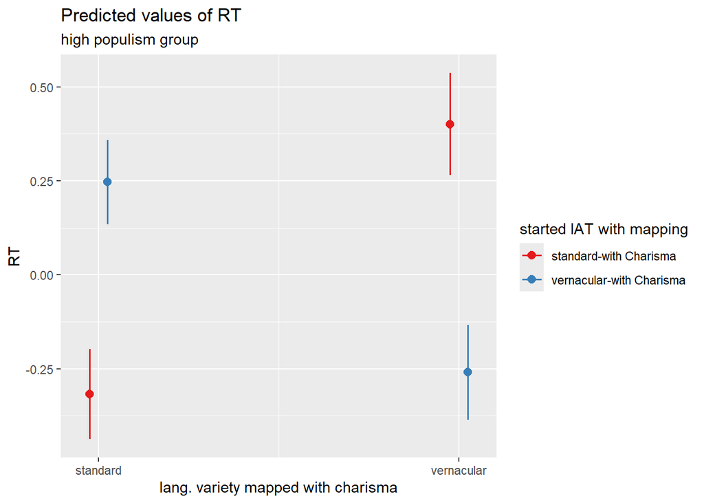

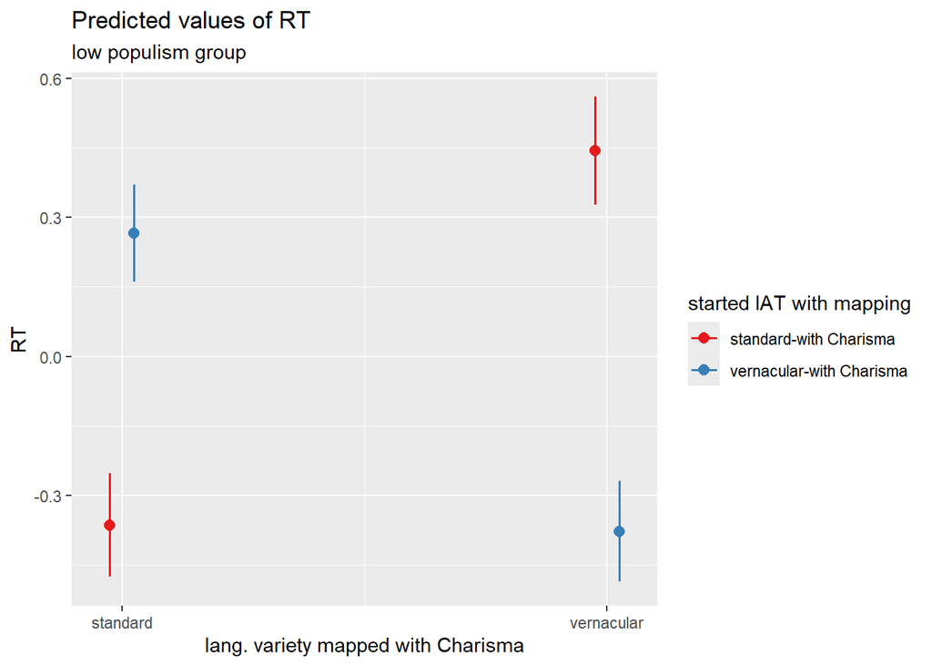

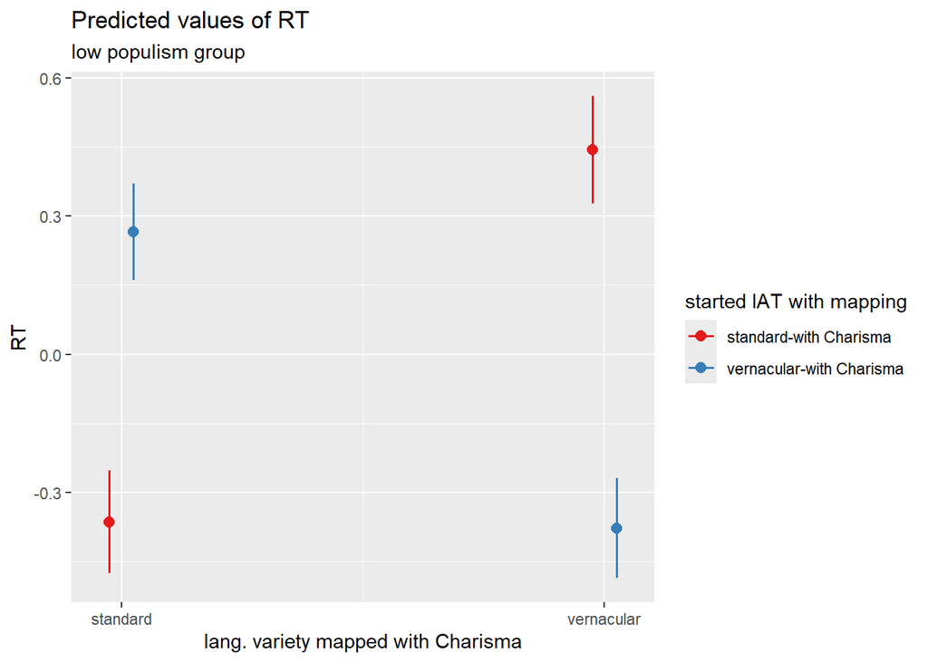

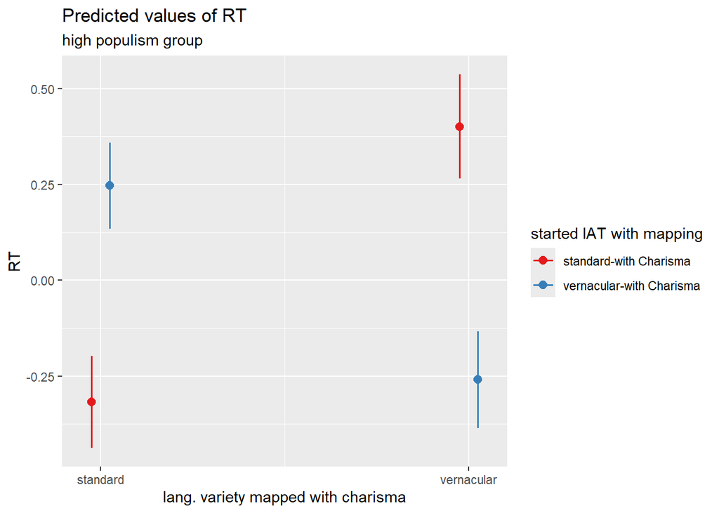

#### Populism & gender Does gender impact on how populism mediates the effect of language variety on RTs?

##### outgroup data

*no impact of stimuli speaker/participant gender in complete data set with neither populism measure* First, variable populism_all (mean of populism items 1-3)

```
## Linear mixed model fit by REML. t-tests use Satterthwaite's method [
## lmerModLmerTest]
## Formula: penal_RTs ~ charisma_lang_var * populism_all * speaker_gender +
##     start_iat + trialcount + age + +leadership_lang_var + (charisma_lang_var |
##     bilendi_id) + (start_iat | stimulus_ID)
##    Data: Four_Out
## Control: lmerControl(optimizer = "bobyqa", optCtrl = list(maxfun = 2e+05))
##
## REML criterion at convergence: 154281.8
##
## Scaled residuals:
##     Min      1Q  Median      3Q     Max
## -6.3956 -0.6195 -0.1258  0.5499 13.4536
##
## Random effects:
##  Groups      Name                              Variance Std.Dev. Corr
##  bilendi_id  (Intercept)                       0.326531 0.57143
##              charisma_lang_varvernacular       0.480728 0.69335  -0.36
##  stimulus_ID (Intercept)                       0.021471 0.14653
##              start_iatvernacular-with Charisma 0.001971 0.04439  -0.05
##  Residual                                      0.598954 0.77392
## Number of obs: 64365, groups:  bilendi_id, 537; stimulus_ID, 303
##
## Fixed effects:
##                                                               Estimate
## (Intercept)                                                  5.856e-01
## charisma_lang_varvernacular                                  4.153e-02
## populism_all                                                -1.593e-02
## speaker_gendermale                                           8.176e-02
## start_iatvernacular-with Charisma                            1.303e-01
## trialcount                                                  -6.254e-03
## age                                                          1.089e-01
## leadership_lang_var2                                         9.613e-02
## charisma_lang_varvernacular:populism_all                     2.665e-02
## charisma_lang_varvernacular:speaker_gendermale               2.430e-02
## populism_all:speaker_gendermale                             -5.707e-03
## charisma_lang_varvernacular:populism_all:speaker_gendermale -1.425e-02
##                                                             Std. Error
## (Intercept)                                                  5.225e-02
## charisma_lang_varvernacular                                  4.351e-02
```

[output cut: 49 more lines]

```
## chrsm_lng_vrvrnclr:s_  0.182 -0.711  0.009 -0.355  0.000  0.004  0.000  0.000
## pplsm_ll:s_           -0.006  0.009 -0.677 -0.001 -0.003 -0.001 -0.017 -0.021
## chrsm__:_:_            0.006 -0.023  0.255  0.000  0.000  0.001  0.000  0.000
##                       chrsm_lng_vrvrnclr:p_ chrsm_lng_vrvrnclr:s_ ppl_:_
## chrsm_lng_v
## populism_ll
## spkr_gndrml
## strt_tvrn-C
## trialcount
## age
## ldrshp_ln_2
## chrsm_lng_vrvrnclr:p_
## chrsm_lng_vrvrnclr:s_ -0.025
## pplsm_ll:s_            0.255                 0.000
## chrsm__:_:_           -0.677                 0.000                -0.376
```

```
## Type III Analysis of Variance Table with Satterthwaite's method
##                                               Sum Sq Mean Sq NumDF  DenDF
## charisma_lang_var                               1.85    1.85     1  410.3
## populism_all                                    0.08    0.08     1  464.6
## speaker_gender                                  2.03    2.03     1  575.7
## start_iat                                       4.61    4.61     1  540.9
## trialcount                                    954.49  954.49     1 8490.1
## age                                            13.08   13.08     1  529.9
## leadership_lang_var                             2.48    2.48     1  541.6
## charisma_lang_var:populism_all                  0.24    0.24     1  409.4
## charisma_lang_var:speaker_gender                0.09    0.09     1  409.4
## populism_all:speaker_gender                     0.04    0.04     1  464.5
## charisma_lang_var:populism_all:speaker_gender   0.03    0.03     1  409.4
##                                                 F value    Pr(>F)
## charisma_lang_var                                3.0813  0.079941 .
## populism_all                                     0.1408  0.707681
## speaker_gender                                   3.3856  0.066284 .
## start_iat                                        7.7026  0.005705 **
## trialcount                                    1593.5922 < 2.2e-16 ***
## age                                             21.8346 3.773e-06 ***
## leadership_lang_var                              4.1477  0.042178 *
## charisma_lang_var:populism_all                   0.4048  0.524952
## charisma_lang_var:speaker_gender                 0.1580  0.691176
## populism_all:speaker_gender                      0.0713  0.789639
## charisma_lang_var:populism_all:speaker_gender    0.0540  0.816426
## ---
## Signif. codes:  0 '***' 0.001 '**' 0.01 '*' 0.05 '.' 0.1 ' ' 1
```

Second, variable populism_dim (first PC dimension reduction)

```
## Linear mixed model fit by REML. t-tests use Satterthwaite's method [
## lmerModLmerTest]
## Formula: penal_RTs ~ charisma_lang_var * populism_dim * speaker_gender +
##     start_iat + trialcount + age + +leadership_lang_var + (charisma_lang_var |
##     bilendi_id) + (start_iat | stimulus_ID)
##    Data: Four_Out
## Control: lmerControl(optimizer = "bobyqa", optCtrl = list(maxfun = 2e+05))
##
## REML criterion at convergence: 154280.7
##
## Scaled residuals:
##     Min      1Q  Median      3Q     Max
## -6.3957 -0.6195 -0.1256  0.5500 13.4541
##
## Random effects:
##  Groups      Name                              Variance Std.Dev. Corr
##  bilendi_id  (Intercept)                       0.325651 0.57066
##              charisma_lang_varvernacular       0.480548 0.69322  -0.36
##  stimulus_ID (Intercept)                       0.021472 0.14653
##              start_iatvernacular-with Charisma 0.001971 0.04439  -0.05
##  Residual                                      0.598954 0.77392
## Number of obs: 64365, groups:  bilendi_id, 537; stimulus_ID, 303
##
## Fixed effects:
##                                                               Estimate
## (Intercept)                                                  5.845e-01
## charisma_lang_varvernacular                                  4.171e-02
## populism_dim                                                -1.287e-02
## speaker_gendermale                                           8.235e-02
## start_iatvernacular-with Charisma                            1.320e-01
## trialcount                                                  -6.254e-03
## age                                                          1.082e-01
## leadership_lang_var2                                         9.707e-02
## charisma_lang_varvernacular:populism_dim                     2.942e-02
## charisma_lang_varvernacular:speaker_gendermale               2.389e-02
## populism_dim:speaker_gendermale                             -2.992e-02
## charisma_lang_varvernacular:populism_dim:speaker_gendermale -1.186e-02
##                                                             Std. Error
## (Intercept)                                                  5.219e-02
## charisma_lang_varvernacular                                  4.351e-02
```

[output cut: 49 more lines]

```
## chrsm_lng_vrvrnclr:s_  0.181 -0.711  0.010 -0.354  0.000  0.004  0.000  0.000
## pplsm_dm:s_           -0.002  0.009 -0.672 -0.002 -0.012 -0.002 -0.006 -0.022
## chrsm__:_:_            0.005 -0.025  0.252  0.000 -0.001  0.006  0.000  0.000
##                       chrsm_lng_vrvrnclr:p_ chrsm_lng_vrvrnclr:s_ ppl_:_
## chrsm_lng_v
## populism_dm
## spkr_gndrml
## strt_tvrn-C
## trialcount
## age
## ldrshp_ln_2
## chrsm_lng_vrvrnclr:p_
## chrsm_lng_vrvrnclr:s_ -0.026
## pplsm_dm:s_            0.252                 0.001
## chrsm__:_:_           -0.672                -0.001                -0.375
```

```
## Type III Analysis of Variance Table with Satterthwaite's method
##                                               Sum Sq Mean Sq NumDF  DenDF
## charisma_lang_var                               1.84    1.84     1  410.2
## populism_dim                                    0.27    0.27     1  464.2
## speaker_gender                                  2.05    2.05     1  574.8
## start_iat                                       4.74    4.74     1  541.0
## trialcount                                    954.47  954.47     1 8487.2
## age                                            12.89   12.89     1  529.9
## leadership_lang_var                             2.54    2.54     1  541.6
## charisma_lang_var:populism_dim                  0.35    0.35     1  409.4
## charisma_lang_var:speaker_gender                0.09    0.09     1  409.4
## populism_dim:speaker_gender                     0.33    0.33     1  463.7
## charisma_lang_var:populism_dim:speaker_gender   0.02    0.02     1  409.4
##                                                 F value    Pr(>F)
## charisma_lang_var                                3.0796  0.080025 .
## populism_dim                                     0.4460  0.504591
## speaker_gender                                   3.4159  0.065084 .
## start_iat                                        7.9058  0.005106 **
## trialcount                                    1593.5585 < 2.2e-16 ***
## age                                             21.5197 4.418e-06 ***
## leadership_lang_var                              4.2349  0.040079 *
## charisma_lang_var:populism_dim                   0.5856  0.444582
## charisma_lang_var:speaker_gender                 0.1528  0.696056
## populism_dim:speaker_gender                      0.5557  0.456384
## charisma_lang_var:populism_dim:speaker_gender    0.0373  0.846887
## ---
## Signif. codes:  0 '***' 0.001 '**' 0.01 '*' 0.05 '.' 0.1 ' ' 1
```

##### Subset analyses

###### low populism & speaker gender

no impact of gender stimuli speaker in populism subset (low) & populism_all/ populism_dim

```
## Linear mixed model fit by REML. t-tests use Satterthwaite's method [
## lmerModLmerTest]
## Formula: penal_RTs ~ charisma_lang_var * populism_all * speaker_gender +
##     start_iat + trialcount + age + pp_gender + leadership_lang_var +
##     (charisma_lang_var | bilendi_id) + (start_iat | stimulus_ID)
##    Data: Four_Out_low_pop
## Control: lmerControl(optimizer = "bobyqa", optCtrl = list(maxfun = 2e+05))
##
## REML criterion at convergence: 74726.1
##
## Scaled residuals:
##     Min      1Q  Median      3Q     Max
## -4.9122 -0.6278 -0.1382  0.5464 12.4006
##
## Random effects:
##  Groups      Name                              Variance Std.Dev. Corr
##  stimulus_ID (Intercept)                       0.026451 0.16264
##              start_iatvernacular-with Charisma 0.001796 0.04238  -0.03
##  bilendi_id  (Intercept)                       0.311569 0.55818
##              charisma_lang_varvernacular       0.529070 0.72737  -0.55
##  Residual                                      0.650601 0.80660
## Number of obs: 30093, groups:  stimulus_ID, 303; bilendi_id, 251
##
## Fixed effects:
##                                                               Estimate
## (Intercept)                                                  8.612e-01
## charisma_lang_varvernacular                                  9.135e-03
## populism_all                                                -5.605e-02
## speaker_gendermale                                           7.743e-02
## start_iatvernacular-with Charisma                           -3.094e-04
## trialcount                                                  -7.008e-03
## age                                                          1.326e-01
## pp_genderfemale                                             -8.632e-02
## pp_gendermale                                               -1.540e-01
## leadership_lang_var2                                         1.216e-01
## charisma_lang_varvernacular:populism_all                     3.808e-02
## charisma_lang_varvernacular:speaker_gendermale               5.449e-02
## populism_all:speaker_gendermale                             -6.407e-02
## charisma_lang_varvernacular:populism_all:speaker_gendermale -3.702e-02
##                                                             Std. Error
```

[output cut: 31 more lines]

```
## charisma_lang_varvernacular                                   0.8902
## populism_all                                                  0.2606
## speaker_gendermale                                            0.3036
## start_iatvernacular-with Charisma                             0.9959
## trialcount                                                   < 2e-16 ***
## age                                                         1.63e-05 ***
## pp_genderfemale                                               0.8573
## pp_gendermale                                                 0.7491
## leadership_lang_var2                                          0.0510 .
## charisma_lang_varvernacular:populism_all                      0.5484
## charisma_lang_varvernacular:speaker_gendermale                0.5630
## populism_all:speaker_gendermale                               0.3807
## charisma_lang_varvernacular:populism_all:speaker_gendermale   0.6959
## ---
## Signif. codes:  0 '***' 0.001 '**' 0.01 '*' 0.05 '.' 0.1 ' ' 1
```

```
##
## Correlation matrix not shown by default, as p = 14 > 12.
## Use print(x, correlation=TRUE)  or
##     vcov(x)        if you need it
```

```
## Type III Analysis of Variance Table with Satterthwaite's method
##                                               Sum Sq Mean Sq NumDF  DenDF
## charisma_lang_var                               0.39    0.39     1  184.7
## populism_all                                    4.01    4.01     1  233.1
## speaker_gender                                  1.74    1.74     1  278.3
## start_iat                                       0.00    0.00     1  243.6
## trialcount                                    557.32  557.32     1 3919.5
## age                                            12.59   12.59     1  242.1
## pp_gender                                       0.79    0.40     2  242.0
## leadership_lang_var                             2.50    2.50     1  247.7
## charisma_lang_var:populism_all                  0.11    0.11     1  184.3
## charisma_lang_var:speaker_gender                0.22    0.22     1  184.3
## populism_all:speaker_gender                     1.18    1.18     1  231.6
## charisma_lang_var:populism_all:speaker_gender   0.10    0.10     1  184.5
##                                                F value    Pr(>F)
## charisma_lang_var                               0.5978   0.44042
## populism_all                                    6.1573   0.01379 *
## speaker_gender                                  2.6728   0.10321
## start_iat                                       0.0000   0.99592
## trialcount                                    856.6170 < 2.2e-16 ***
## age                                            19.3567 1.626e-05 ***
## pp_gender                                       0.6083   0.54510
## leadership_lang_var                             3.8467   0.05096 .
## charisma_lang_var:populism_all                  0.1712   0.67952
## charisma_lang_var:speaker_gender                0.3357   0.56304
## populism_all:speaker_gender                     1.8132   0.17944
## charisma_lang_var:populism_all:speaker_gender   0.1532   0.69594
## ---
## Signif. codes:  0 '***' 0.001 '**' 0.01 '*' 0.05 '.' 0.1 ' ' 1
```

```
## Linear mixed model fit by REML. t-tests use Satterthwaite's method [
## lmerModLmerTest]
## Formula: penal_RTs ~ charisma_lang_var * populism_dim * speaker_gender +
##     start_iat + trialcount + age + pp_gender + leadership_lang_var +
##     (charisma_lang_var | bilendi_id) + (start_iat | stimulus_ID)
##    Data: Four_Out_low_pop
## Control: lmerControl(optimizer = "bobyqa", optCtrl = list(maxfun = 2e+05))
##
## REML criterion at convergence: 74726.8
##
## Scaled residuals:
##     Min      1Q  Median      3Q     Max
## -4.9131 -0.6276 -0.1378  0.5460 12.4024
##
## Random effects:
##  Groups      Name                              Variance Std.Dev. Corr
##  stimulus_ID (Intercept)                       0.026452 0.16264
##              start_iatvernacular-with Charisma 0.001795 0.04237  -0.03
##  bilendi_id  (Intercept)                       0.311073 0.55774
##              charisma_lang_varvernacular       0.528620 0.72706  -0.54
##  Residual                                      0.650600 0.80660
## Number of obs: 30093, groups:  stimulus_ID, 303; bilendi_id, 251
##
## Fixed effects:
##                                                               Estimate
## (Intercept)                                                  8.538e-01
## charisma_lang_varvernacular                                  1.005e-02
## populism_dim                                                -6.036e-02
## speaker_gendermale                                           7.652e-02
## start_iatvernacular-with Charisma                            3.329e-03
## trialcount                                                  -7.009e-03
## age                                                          1.302e-01
## pp_genderfemale                                             -8.366e-02
## pp_gendermale                                               -1.465e-01
## leadership_lang_var2                                         1.233e-01
## charisma_lang_varvernacular:populism_dim                     4.964e-02
## charisma_lang_varvernacular:speaker_gendermale               5.369e-02
## populism_dim:speaker_gendermale                             -5.078e-02
## charisma_lang_varvernacular:populism_dim:speaker_gendermale -5.011e-02
##                                                             Std. Error
```

[output cut: 31 more lines]

```
## charisma_lang_varvernacular                                   0.8793
## populism_dim                                                  0.2225
## speaker_gendermale                                            0.3088
## start_iatvernacular-with Charisma                             0.9563
## trialcount                                                   < 2e-16 ***
## age                                                         2.69e-05 ***
## pp_genderfemale                                               0.8618
## pp_gendermale                                                 0.7611
## leadership_lang_var2                                          0.0480 *
## charisma_lang_varvernacular:populism_dim                      0.4314
## charisma_lang_varvernacular:speaker_gendermale                0.5686
## populism_dim:speaker_gendermale                               0.4871
## charisma_lang_varvernacular:populism_dim:speaker_gendermale   0.5974
## ---
## Signif. codes:  0 '***' 0.001 '**' 0.01 '*' 0.05 '.' 0.1 ' ' 1
```

```
##
## Correlation matrix not shown by default, as p = 14 > 12.
## Use print(x, correlation=TRUE)  or
##     vcov(x)        if you need it
```

```
## Type III Analysis of Variance Table with Satterthwaite's method
##                                               Sum Sq Mean Sq NumDF  DenDF
## charisma_lang_var                               0.40    0.40     1  184.7
## populism_dim                                    3.50    3.50     1  232.5
## speaker_gender                                  1.69    1.69     1  277.2
## start_iat                                       0.00    0.00     1  243.7
## trialcount                                    557.25  557.25     1 3933.9
## age                                            11.92   11.92     1  242.1
## pp_gender                                       0.69    0.35     2  242.0
## leadership_lang_var                             2.57    2.57     1  247.7
## charisma_lang_var:populism_dim                  0.18    0.18     1  184.4
## charisma_lang_var:speaker_gender                0.21    0.21     1  184.4
## populism_dim:speaker_gender                     0.99    0.99     1  230.9
## charisma_lang_var:populism_dim:speaker_gender   0.18    0.18     1  184.8
##                                                F value    Pr(>F)
## charisma_lang_var                               0.6154   0.43378
## populism_dim                                    5.3841   0.02119 *
## speaker_gender                                  2.5964   0.10824
## start_iat                                       0.0030   0.95627
## trialcount                                    856.5122 < 2.2e-16 ***
## age                                            18.3203 2.692e-05 ***
## pp_gender                                       0.5305   0.58897
## leadership_lang_var                             3.9497   0.04798 *
## charisma_lang_var:populism_dim                  0.2700   0.60395
## charisma_lang_var:speaker_gender                0.3263   0.56857
## populism_dim:speaker_gender                     1.5184   0.21911
## charisma_lang_var:populism_dim:speaker_gender   0.2799   0.59739
## ---
## Signif. codes:  0 '***' 0.001 '**' 0.01 '*' 0.05 '.' 0.1 ' ' 1
```

###### low populism & participant gender

no impact of participant gender in populism subset (low) & populism_all/ populism_dim

```
## fixed-effect model matrix is rank deficient so dropping 2 columns / coefficients
## fixed-effect model matrix is rank deficient so dropping 2 columns / coefficients
```

```
## Linear mixed model fit by REML. t-tests use Satterthwaite's method [
## lmerModLmerTest]
## Formula:
## penal_RTs ~ charisma_lang_var * populism_all * pp_gender + start_iat +
##     trialcount + age + speaker_gender + leadership_lang_var +
##     (charisma_lang_var | bilendi_id) + (start_iat | stimulus_ID)
##    Data: Four_Out_low_pop
## Control: lmerControl(optimizer = "bobyqa", optCtrl = list(maxfun = 2e+05))
##
## REML criterion at convergence: 74721.5
##
## Scaled residuals:
##     Min      1Q  Median      3Q     Max
## -4.9129 -0.6277 -0.1374  0.5461 12.3992
##
## Random effects:
##  Groups      Name                              Variance Std.Dev. Corr
##  stimulus_ID (Intercept)                       0.02646  0.16265
##              start_iatvernacular-with Charisma 0.00180  0.04243  -0.03
##  bilendi_id  (Intercept)                       0.30974  0.55654
##              charisma_lang_varvernacular       0.52052  0.72147  -0.54
##  Residual                                      0.65061  0.80660
## Number of obs: 30093, groups:  stimulus_ID, 303; bilendi_id, 251
##
## Fixed effects:
##                                                            Estimate Std. Error
## (Intercept)                                               1.305e+00  5.727e-01
## charisma_lang_varvernacular                              -9.264e-01  7.393e-01
## populism_all                                             -1.172e-01  5.046e-02
## pp_genderfemale                                          -5.870e-01  5.732e-01
## pp_gendermale                                            -5.983e-01  5.748e-01
## start_iatvernacular-with Charisma                        -1.292e-03  6.050e-02
## trialcount                                               -7.002e-03  2.391e-04
## age                                                       1.327e-01  3.024e-02
## speaker_gendermale                                        1.025e-01  6.386e-02
## leadership_lang_var2                                      1.334e-01  6.202e-02
## charisma_lang_varvernacular:populism_all                  6.103e-02  6.521e-02
## charisma_lang_varvernacular:pp_genderfemale               1.040e+00  7.420e-01
## charisma_lang_varvernacular:pp_gendermale                 9.003e-01  7.443e-01
## populism_all:pp_genderfemale                              8.079e-02  7.456e-02
```

[output cut: 20 more lines]

```
## populism_all                                               0.0216 *
## pp_genderfemale                                            0.3075
## pp_gendermale                                              0.2997
## start_iatvernacular-with Charisma                          0.9830
## trialcount                                                < 2e-16 ***
## age                                                       1.7e-05 ***
## speaker_gendermale                                         0.1095
## leadership_lang_var2                                       0.0324 *
## charisma_lang_varvernacular:populism_all                   0.3505
## charisma_lang_varvernacular:pp_genderfemale                0.1626
## charisma_lang_varvernacular:pp_gendermale                  0.2280
## populism_all:pp_genderfemale                               0.2804
## charisma_lang_varvernacular:populism_all:pp_genderfemale   0.2426
## ---
## Signif. codes:  0 '***' 0.001 '**' 0.01 '*' 0.05 '.' 0.1 ' ' 1
```

```
##
## Correlation matrix not shown by default, as p = 15 > 12.
## Use print(x, correlation=TRUE)  or
##     vcov(x)        if you need it
```

```
## fit warnings:
## fixed-effect model matrix is rank deficient so dropping 2 columns / coefficients
```

```
## Type III Analysis of Variance Table with Satterthwaite's method
##                                          Sum Sq Mean Sq NumDF  DenDF  F value
## charisma_lang_var                          0.51    0.51     1  183.4   0.7907
## populism_all                               3.61    3.61     1  231.0   5.5434
## pp_gender                                  1.09    0.55     2  230.8   0.8400
## start_iat                                  0.00    0.00     1  243.7   0.0005
## trialcount                               557.92  557.92     1 3820.5 857.5405
## age                                       12.53   12.53     1  242.1  19.2601
## speaker_gender                             1.68    1.68     1  290.9   2.5768
## leadership_lang_var                        3.01    3.01     1  247.8   4.6291
## charisma_lang_var:populism_all             0.01    0.01     1  183.1   0.0082
## charisma_lang_var:pp_gender                2.41    1.21     2  183.2   1.8538
## populism_all:pp_gender                     0.10    0.10     1  230.7   0.1464
## charisma_lang_var:populism_all:pp_gender   0.89    0.89     1  183.0   1.3743
##                                             Pr(>F)
## charisma_lang_var                          0.37504
## populism_all                               0.01939 *
## pp_gender                                  0.43304
## start_iat                                  0.98298
## trialcount                               < 2.2e-16 ***
## age                                      1.704e-05 ***
## speaker_gender                             0.10952
## leadership_lang_var                        0.03240 *
## charisma_lang_var:populism_all             0.92812
## charisma_lang_var:pp_gender                0.15956
## populism_all:pp_gender                     0.70238
## charisma_lang_var:populism_all:pp_gender   0.24260
## ---
## Signif. codes:  0 '***' 0.001 '**' 0.01 '*' 0.05 '.' 0.1 ' ' 1
```

```
## fixed-effect model matrix is rank deficient so dropping 2 columns / coefficients
## fixed-effect model matrix is rank deficient so dropping 2 columns / coefficients
```

```
## Linear mixed model fit by REML. t-tests use Satterthwaite's method [
## lmerModLmerTest]
## Formula:
## penal_RTs ~ charisma_lang_var * populism_dim * pp_gender + start_iat +
##     trialcount + age + speaker_gender + leadership_lang_var +
##     (charisma_lang_var | bilendi_id) + (start_iat | stimulus_ID)
##    Data: Four_Out_low_pop
## Control: lmerControl(optimizer = "bobyqa", optCtrl = list(maxfun = 2e+05))
##
## REML criterion at convergence: 74723.4
##
## Scaled residuals:
##     Min      1Q  Median      3Q     Max
## -4.9138 -0.6274 -0.1373  0.5458 12.4019
##
## Random effects:
##  Groups      Name                              Variance Std.Dev. Corr
##  stimulus_ID (Intercept)                       0.026455 0.1627
##              start_iatvernacular-with Charisma 0.001798 0.0424   -0.03
##  bilendi_id  (Intercept)                       0.311831 0.5584
##              charisma_lang_varvernacular       0.522946 0.7232   -0.54
##  Residual                                      0.650602 0.8066
## Number of obs: 30093, groups:  stimulus_ID, 303; bilendi_id, 251
##
## Fixed effects:
##                                                            Estimate Std. Error
## (Intercept)                                               1.273e+00  5.739e-01
## charisma_lang_varvernacular                              -9.042e-01  7.402e-01
## populism_dim                                             -9.325e-02  4.921e-02
## pp_genderfemale                                          -5.466e-01  5.744e-01
## pp_gendermale                                            -5.522e-01  5.757e-01
## start_iatvernacular-with Charisma                        -3.804e-03  6.060e-02
## trialcount                                               -7.006e-03  2.392e-04
## age                                                       1.294e-01  3.052e-02
## speaker_gendermale                                        9.958e-02  6.391e-02
## leadership_lang_var2                                      1.304e-01  6.240e-02
## charisma_lang_varvernacular:populism_dim                  4.275e-02  6.345e-02
## charisma_lang_varvernacular:pp_genderfemale               1.010e+00  7.429e-01
## charisma_lang_varvernacular:pp_gendermale                 8.717e-01  7.448e-01
## populism_dim:pp_genderfemale                              3.364e-02  7.500e-02
```

[output cut: 20 more lines]

```
## populism_dim                                               0.0601 .
## pp_genderfemale                                            0.3429
## pp_gendermale                                              0.3391
## start_iatvernacular-with Charisma                          0.9500
## trialcount                                                < 2e-16 ***
## age                                                      3.19e-05 ***
## speaker_gendermale                                         0.1203
## leadership_lang_var2                                       0.0376 *
## charisma_lang_varvernacular:populism_dim                   0.5013
## charisma_lang_varvernacular:pp_genderfemale                0.1756
## charisma_lang_varvernacular:pp_gendermale                  0.2433
## populism_dim:pp_genderfemale                               0.6545
## charisma_lang_varvernacular:populism_dim:pp_genderfemale   0.5348
## ---
## Signif. codes:  0 '***' 0.001 '**' 0.01 '*' 0.05 '.' 0.1 ' ' 1
```

```
##
## Correlation matrix not shown by default, as p = 15 > 12.
## Use print(x, correlation=TRUE)  or
##     vcov(x)        if you need it
```

```
## fit warnings:
## fixed-effect model matrix is rank deficient so dropping 2 columns / coefficients
```

```
## Type III Analysis of Variance Table with Satterthwaite's method
##                                          Sum Sq Mean Sq NumDF  DenDF  F value
## charisma_lang_var                          0.61    0.61     1  183.7   0.9452
## populism_dim                               3.14    3.14     1  231.8   4.8242
## pp_gender                                  0.93    0.46     2  231.2   0.7144
## start_iat                                  0.00    0.00     1  243.6   0.0039
## trialcount                               558.10  558.10     1 3848.4 857.8221
## age                                       11.69   11.69     1  242.1  17.9723
## speaker_gender                             1.58    1.58     1  290.8   2.4275
## leadership_lang_var                        2.84    2.84     1  247.7   4.3680
## charisma_lang_var:populism_dim             0.04    0.04     1  183.3   0.0680
## charisma_lang_var:pp_gender                2.38    1.19     2  183.4   1.8272
## populism_dim:pp_gender                     0.00    0.00     1  231.4   0.0031
## charisma_lang_var:populism_dim:pp_gender   0.25    0.25     1  183.3   0.3867
##                                             Pr(>F)
## charisma_lang_var                          0.33222
## populism_dim                               0.02905 *
## pp_gender                                  0.49055
## start_iat                                  0.95000
## trialcount                               < 2.2e-16 ***
## age                                       3.19e-05 ***
## speaker_gender                             0.12031
## leadership_lang_var                        0.03764 *
## charisma_lang_var:populism_dim             0.79452
## charisma_lang_var:pp_gender                0.16378
## populism_dim:pp_gender                     0.95580
## charisma_lang_var:populism_dim:pp_gender   0.53480
## ---
## Signif. codes:  0 '***' 0.001 '**' 0.01 '*' 0.05 '.' 0.1 ' ' 1
```

###### high populism & speaker gender

no impact of gender stimuli speaker in populism subset (high) & populism_all/ populism_dim

```
## Linear mixed model fit by REML. t-tests use Satterthwaite's method [
## lmerModLmerTest]
## Formula: penal_RTs ~ charisma_lang_var * populism_all * speaker_gender +
##     start_iat + trialcount + age + pp_gender + leadership_lang_var +
##     (charisma_lang_var | bilendi_id) + (start_iat | stimulus_ID)
##    Data: Four_Out_high_pop
## Control: lmerControl(optimizer = "bobyqa", optCtrl = list(maxfun = 2e+05))
##
## REML criterion at convergence: 80009.4
##
## Scaled residuals:
##     Min      1Q  Median      3Q     Max
## -6.4418 -0.6102 -0.1166  0.5583 13.4815
##
## Random effects:
##  Groups      Name                              Variance Std.Dev. Corr
##  stimulus_ID (Intercept)                       0.019596 0.1400
##              start_iatvernacular-with Charisma 0.004277 0.0654   -0.05
##  bilendi_id  (Intercept)                       0.348629 0.5904
##              charisma_lang_varvernacular       0.453420 0.6734   -0.24
##  Residual                                      0.558675 0.7474
## Number of obs: 34272, groups:  stimulus_ID, 303; bilendi_id, 286
##
## Fixed effects:
##                                                               Estimate
## (Intercept)                                                  4.744e-01
## charisma_lang_varvernacular                                  7.212e-02
## populism_all                                                 7.146e-04
## speaker_gendermale                                           1.025e-01
## start_iatvernacular-with Charisma                            2.252e-01
## trialcount                                                  -5.667e-03
## age                                                          8.214e-02
## pp_gendermale                                               -2.181e-02
## leadership_lang_var2                                         5.069e-02
## charisma_lang_varvernacular:populism_all                    -2.472e-02
## charisma_lang_varvernacular:speaker_gendermale              -3.405e-03
## populism_all:speaker_gendermale                              8.997e-03
## charisma_lang_varvernacular:populism_all:speaker_gendermale  5.619e-02
##                                                             Std. Error
## (Intercept)                                                  7.857e-02
```

[output cut: 27 more lines]

```
## (Intercept)                                                 4.42e-09 ***
## charisma_lang_varvernacular                                   0.2193
## populism_all                                                  0.9885
## speaker_gendermale                                            0.1643
## start_iatvernacular-with Charisma                             0.0014 **
## trialcount                                                   < 2e-16 ***
## age                                                           0.0205 *
## pp_gendermale                                                 0.7542
## leadership_lang_var2                                          0.4681
## charisma_lang_varvernacular:populism_all                      0.6610
## charisma_lang_varvernacular:speaker_gendermale                0.9667
## populism_all:speaker_gendermale                               0.8999
## charisma_lang_varvernacular:populism_all:speaker_gendermale   0.4908
## ---
## Signif. codes:  0 '***' 0.001 '**' 0.01 '*' 0.05 '.' 0.1 ' ' 1
```

```
##
## Correlation matrix not shown by default, as p = 13 > 12.
## Use print(x, correlation=TRUE)  or
##     vcov(x)        if you need it
```

```
## Type III Analysis of Variance Table with Satterthwaite's method
##                                               Sum Sq Mean Sq NumDF  DenDF
## charisma_lang_var                               1.67    1.67     1  223.2
## populism_all                                    0.02    0.02     1  239.7
## speaker_gender                                  1.01    1.01     1  261.8
## start_iat                                       5.82    5.82     1  287.5
## trialcount                                    415.48  415.48     1 4659.7
## age                                             3.03    3.03     1  278.0
## pp_gender                                       0.05    0.05     1  278.0
## leadership_lang_var                             0.29    0.29     1  281.9
## charisma_lang_var:populism_all                  0.00    0.00     1  222.8
## charisma_lang_var:speaker_gender                0.00    0.00     1  222.8
## populism_all:speaker_gender                     0.14    0.14     1  236.2
## charisma_lang_var:populism_all:speaker_gender   0.27    0.27     1  222.9
##                                                F value    Pr(>F)
## charisma_lang_var                               2.9916  0.085080 .
## populism_all                                    0.0347  0.852352
## speaker_gender                                  1.8108  0.179573
## start_iat                                      10.4116  0.001397 **
## trialcount                                    743.6901 < 2.2e-16 ***
## age                                             5.4274  0.020540 *
## pp_gender                                       0.0983  0.754168
## leadership_lang_var                             0.5278  0.468136
## charisma_lang_var:populism_all                  0.0069  0.933925
## charisma_lang_var:speaker_gender                0.0018  0.966657
## populism_all:speaker_gender                     0.2590  0.611313
## charisma_lang_var:populism_all:speaker_gender   0.4764  0.490782
## ---
## Signif. codes:  0 '***' 0.001 '**' 0.01 '*' 0.05 '.' 0.1 ' ' 1
```

```
## Linear mixed model fit by REML. t-tests use Satterthwaite's method [
## lmerModLmerTest]
## Formula: penal_RTs ~ charisma_lang_var * populism_dim * speaker_gender +
##     start_iat + trialcount + age + pp_gender + leadership_lang_var +
##     (charisma_lang_var | bilendi_id) + (start_iat | stimulus_ID)
##    Data: Four_Out_high_pop
## Control: lmerControl(optimizer = "bobyqa", optCtrl = list(maxfun = 2e+05))
##
## REML criterion at convergence: 80008.4
##
## Scaled residuals:
##     Min      1Q  Median      3Q     Max
## -6.4420 -0.6100 -0.1163  0.5583 13.4814
##
## Random effects:
##  Groups      Name                              Variance Std.Dev. Corr
##  stimulus_ID (Intercept)                       0.019596 0.1400
##              start_iatvernacular-with Charisma 0.004277 0.0654   -0.05
##  bilendi_id  (Intercept)                       0.347598 0.5896
##              charisma_lang_varvernacular       0.452824 0.6729   -0.23
##  Residual                                      0.558676 0.7474
## Number of obs: 34272, groups:  stimulus_ID, 303; bilendi_id, 286
##
## Fixed effects:
##                                                               Estimate
## (Intercept)                                                  4.746e-01
## charisma_lang_varvernacular                                  7.201e-02
## populism_dim                                                 2.051e-02
## speaker_gendermale                                           1.023e-01
## start_iatvernacular-with Charisma                            2.233e-01
## trialcount                                                  -5.666e-03
## age                                                          8.696e-02
## pp_gendermale                                               -1.908e-02
## leadership_lang_var2                                         4.680e-02
## charisma_lang_varvernacular:populism_dim                    -2.532e-02
## charisma_lang_varvernacular:speaker_gendermale              -3.087e-03
## populism_dim:speaker_gendermale                             -7.061e-02
## charisma_lang_varvernacular:populism_dim:speaker_gendermale  7.126e-02
##                                                             Std. Error
## (Intercept)                                                  7.850e-02
```

[output cut: 27 more lines]

```
## (Intercept)                                                 4.25e-09 ***
## charisma_lang_varvernacular                                  0.21960
## populism_dim                                                 0.67346
## speaker_gendermale                                           0.16449
## start_iatvernacular-with Charisma                            0.00151 **
## trialcount                                                   < 2e-16 ***
## age                                                          0.01316 *
## pp_gendermale                                                0.78389
## leadership_lang_var2                                         0.50159
## charisma_lang_varvernacular:populism_dim                     0.64802
## charisma_lang_varvernacular:speaker_gendermale               0.96975
## populism_dim:speaker_gendermale                              0.32076
## charisma_lang_varvernacular:populism_dim:speaker_gendermale  0.38227
## ---
## Signif. codes:  0 '***' 0.001 '**' 0.01 '*' 0.05 '.' 0.1 ' ' 1
```

```
##
## Correlation matrix not shown by default, as p = 13 > 12.
## Use print(x, correlation=TRUE)  or
##     vcov(x)        if you need it
```

```
## Type III Analysis of Variance Table with Satterthwaite's method
##                                               Sum Sq Mean Sq NumDF  DenDF
## charisma_lang_var                               1.68    1.68     1  223.1
## populism_dim                                    0.04    0.04     1  238.2
## speaker_gender                                  1.01    1.01     1  261.7
## start_iat                                       5.73    5.73     1  287.6
## trialcount                                    415.49  415.49     1 4651.2
## age                                             3.48    3.48     1  278.0
## pp_gender                                       0.04    0.04     1  278.0
## leadership_lang_var                             0.25    0.25     1  281.9
## charisma_lang_var:populism_dim                  0.04    0.04     1  222.7
## charisma_lang_var:speaker_gender                0.00    0.00     1  222.7
## populism_dim:speaker_gender                     0.13    0.13     1  234.7
## charisma_lang_var:populism_dim:speaker_gender   0.43    0.43     1  222.8
##                                                F value    Pr(>F)
## charisma_lang_var                               3.0012  0.084583 .
## populism_dim                                    0.0685  0.793712
## speaker_gender                                  1.8117  0.179467
## start_iat                                      10.2603  0.001512 **
## trialcount                                    743.7086 < 2.2e-16 ***
## age                                             6.2269  0.013163 *
## pp_gender                                       0.0754  0.783893
## leadership_lang_var                             0.4527  0.501594
## charisma_lang_var:populism_dim                  0.0642  0.800232
## charisma_lang_var:speaker_gender                0.0014  0.969745
## populism_dim:speaker_gender                     0.2329  0.629817
## charisma_lang_var:populism_dim:speaker_gender   0.7664  0.382272
## ---
## Signif. codes:  0 '***' 0.001 '**' 0.01 '*' 0.05 '.' 0.1 ' ' 1
```

###### high populism & participant gender

no impact of participant gender in populism subset (high) & populism_all/ populism_dim

```
## Linear mixed model fit by REML. t-tests use Satterthwaite's method [
## lmerModLmerTest]
## Formula:
## penal_RTs ~ charisma_lang_var * populism_all * pp_gender + start_iat +
##     trialcount + age + speaker_gender + leadership_lang_var +
##     (charisma_lang_var | bilendi_id) + (start_iat | stimulus_ID)
##    Data: Four_Out_high_pop
## Control: lmerControl(optimizer = "bobyqa", optCtrl = list(maxfun = 2e+05))
##
## REML criterion at convergence: 80007
##
## Scaled residuals:
##     Min      1Q  Median      3Q     Max
## -6.4410 -0.6102 -0.1156  0.5585 13.4818
##
## Random effects:
##  Groups      Name                              Variance Std.Dev. Corr
##  stimulus_ID (Intercept)                       0.019594 0.1400
##              start_iatvernacular-with Charisma 0.004277 0.0654   -0.05
##  bilendi_id  (Intercept)                       0.348105 0.5900
##              charisma_lang_varvernacular       0.450909 0.6715   -0.24
##  Residual                                      0.558672 0.7474
## Number of obs: 34272, groups:  stimulus_ID, 303; bilendi_id, 286
##
## Fixed effects:
##                                                          Estimate Std. Error
## (Intercept)                                             4.776e-01  7.863e-02
## charisma_lang_varvernacular                             8.666e-02  5.647e-02
## populism_all                                            2.229e-02  5.480e-02
## pp_gendermale                                          -1.876e-02  7.181e-02
## start_iatvernacular-with Charisma                       2.276e-01  6.986e-02
## trialcount                                             -5.671e-03  2.078e-04
## age                                                     8.013e-02  3.522e-02
## speaker_gendermale                                      1.000e-01  7.129e-02
## leadership_lang_var2                                    4.520e-02  6.991e-02
## charisma_lang_varvernacular:populism_all                7.032e-02  6.152e-02
## charisma_lang_varvernacular:pp_gendermale              -2.065e-02  8.182e-02
## populism_all:pp_gendermale                             -3.115e-02  7.274e-02
## charisma_lang_varvernacular:populism_all:pp_gendermale -1.197e-01  8.232e-02
##                                                                df t value
```

[output cut: 14 more lines]

```
## (Intercept)                                            3.61e-09 ***
## charisma_lang_varvernacular                             0.12630
## populism_all                                            0.68460
## pp_gendermale                                           0.79415
## start_iatvernacular-with Charisma                       0.00126 **
## trialcount                                              < 2e-16 ***
## age                                                     0.02367 *
## speaker_gendermale                                      0.16151
## leadership_lang_var2                                    0.51842
## charisma_lang_varvernacular:populism_all                0.25425
## charisma_lang_varvernacular:pp_gendermale               0.80095
## populism_all:pp_gendermale                              0.66890
## charisma_lang_varvernacular:populism_all:pp_gendermale  0.14728
## ---
## Signif. codes:  0 '***' 0.001 '**' 0.01 '*' 0.05 '.' 0.1 ' ' 1
```

```
##
## Correlation matrix not shown by default, as p = 13 > 12.
## Use print(x, correlation=TRUE)  or
##     vcov(x)        if you need it
```

```
## Type III Analysis of Variance Table with Satterthwaite's method
##                                          Sum Sq Mean Sq NumDF  DenDF  F value
## charisma_lang_var                          1.94    1.94     1  223.4   3.4796
## populism_all                               0.06    0.06     1  239.1   0.1029
## pp_gender                                  0.09    0.09     1  236.5   0.1579
## start_iat                                  5.93    5.93     1  287.4  10.6107
## trialcount                               415.89  415.89     1 4673.5 744.4219
## age                                        2.89    2.89     1  278.0   5.1752
## speaker_gender                             1.10    1.10     1  310.8   1.9694
## leadership_lang_var                        0.23    0.23     1  281.9   0.4181
## charisma_lang_var:populism_all             0.04    0.04     1  223.1   0.0648
## charisma_lang_var:pp_gender                0.04    0.04     1  223.2   0.0637
## populism_all:pp_gender                     0.84    0.84     1  237.9   1.5069
## charisma_lang_var:populism_all:pp_gender   1.18    1.18     1  223.5   2.1148
##                                             Pr(>F)
## charisma_lang_var                         0.063442 .
## populism_all                              0.748706
## pp_gender                                 0.691499
## start_iat                                 0.001259 **
## trialcount                               < 2.2e-16 ***
## age                                       0.023674 *
## speaker_gender                            0.161507
## leadership_lang_var                       0.518418
## charisma_lang_var:populism_all            0.799348
## charisma_lang_var:pp_gender               0.800955
## populism_all:pp_gender                    0.220820
## charisma_lang_var:populism_all:pp_gender  0.147284
## ---
## Signif. codes:  0 '***' 0.001 '**' 0.01 '*' 0.05 '.' 0.1 ' ' 1
```

```
## Linear mixed model fit by REML. t-tests use Satterthwaite's method [
## lmerModLmerTest]
## Formula:
## penal_RTs ~ charisma_lang_var * populism_dim * pp_gender + start_iat +
##     trialcount + age + speaker_gender + leadership_lang_var +
##     (charisma_lang_var | bilendi_id) + (start_iat | stimulus_ID)
##    Data: Four_Out_high_pop
## Control: lmerControl(optimizer = "bobyqa", optCtrl = list(maxfun = 2e+05))
##
## REML criterion at convergence: 80007
##
## Scaled residuals:
##     Min      1Q  Median      3Q     Max
## -6.4420 -0.6103 -0.1159  0.5581 13.4812
##
## Random effects:
##  Groups      Name                              Variance Std.Dev. Corr
##  stimulus_ID (Intercept)                       0.019593 0.1400
##              start_iatvernacular-with Charisma 0.004277 0.0654   -0.05
##  bilendi_id  (Intercept)                       0.346928 0.5890
##              charisma_lang_varvernacular       0.452617 0.6728   -0.24
##  Residual                                      0.558675 0.7474
## Number of obs: 34272, groups:  stimulus_ID, 303; bilendi_id, 286
##
## Fixed effects:
##                                                          Estimate Std. Error
## (Intercept)                                             4.824e-01  7.862e-02
## charisma_lang_varvernacular                             8.396e-02  5.652e-02
## populism_dim                                            2.646e-02  5.097e-02
## pp_gendermale                                          -1.327e-02  7.168e-02
## start_iatvernacular-with Charisma                       2.256e-01  6.956e-02
## trialcount                                             -5.668e-03  2.078e-04
## age                                                     8.110e-02  3.492e-02
## speaker_gendermale                                      9.710e-02  7.117e-02
## leadership_lang_var2                                    4.004e-02  6.964e-02
## charisma_lang_varvernacular:populism_dim                4.769e-02  5.776e-02
## charisma_lang_varvernacular:pp_gendermale              -2.030e-02  8.199e-02
## populism_dim:pp_gendermale                             -7.712e-02  7.184e-02
## charisma_lang_varvernacular:populism_dim:pp_gendermale -7.748e-02  8.180e-02
##                                                                df t value
```

[output cut: 14 more lines]

```
## (Intercept)                                            2.54e-09 ***
## charisma_lang_varvernacular                             0.13887
## populism_dim                                            0.60404
## pp_gendermale                                           0.85323
## start_iatvernacular-with Charisma                       0.00132 **
## trialcount                                              < 2e-16 ***
## age                                                     0.02093 *
## speaker_gendermale                                      0.17342
## leadership_lang_var2                                    0.56579
## charisma_lang_varvernacular:populism_dim                0.40989
## charisma_lang_varvernacular:pp_gendermale               0.80470
## populism_dim:pp_gendermale                              0.28412
## charisma_lang_varvernacular:populism_dim:pp_gendermale  0.34461
## ---
## Signif. codes:  0 '***' 0.001 '**' 0.01 '*' 0.05 '.' 0.1 ' ' 1
```

```
##
## Correlation matrix not shown by default, as p = 13 > 12.
## Use print(x, correlation=TRUE)  or
##     vcov(x)        if you need it
```

```
## Type III Analysis of Variance Table with Satterthwaite's method
##                                          Sum Sq Mean Sq NumDF  DenDF  F value
## charisma_lang_var                          1.81    1.81     1  223.2   3.2387
## populism_dim                               0.02    0.02     1  237.3   0.0433
## pp_gender                                  0.06    0.06     1  236.2   0.1029
## start_iat                                  5.88    5.88     1  287.4  10.5167
## trialcount                               415.54  415.54     1 4663.8 743.7894
## age                                        3.01    3.01     1  278.0   5.3937
## speaker_gender                             1.04    1.04     1  310.9   1.8617
## leadership_lang_var                        0.18    0.18     1  281.9   0.3306
## charisma_lang_var:populism_dim             0.03    0.03     1  222.8   0.0479
## charisma_lang_var:pp_gender                0.03    0.03     1  222.9   0.0613
## populism_dim:pp_gender                     1.40    1.40     1  237.1   2.5063
## charisma_lang_var:populism_dim:pp_gender   0.50    0.50     1  222.9   0.8970
##                                             Pr(>F)
## charisma_lang_var                         0.073268 .
## populism_dim                              0.835352
## pp_gender                                 0.748686
## start_iat                                 0.001322 **
## trialcount                               < 2.2e-16 ***
## age                                       0.020932 *
## speaker_gender                            0.173417
## leadership_lang_var                       0.565787
## charisma_lang_var:populism_dim            0.826927
## charisma_lang_var:pp_gender               0.804701
## populism_dim:pp_gender                    0.114722
## charisma_lang_var:populism_dim:pp_gender  0.344613
## ---
## Signif. codes:  0 '***' 0.001 '**' 0.01 '*' 0.05 '.' 0.1 ' ' 1
```

#### Populism & region

##### general GLMs

Simple effects: Sachsen as well as Brandenburg diff. to ref.level (BaWü) in Standard variety & populism scale

```
## Linear mixed model fit by REML. t-tests use Satterthwaite's method [
## lmerModLmerTest]
## Formula: penal_RTs ~ charisma_lang_var:populism_all:bundesland + trialcount +
##     age + leadership_lang_var + start_iat + (charisma_lang_var |
##     bilendi_id) + (populism_all | stimulus_ID)
##    Data: Four_Out
## Control: lmerControl(optimizer = "bobyqa", optCtrl = list(maxfun = 2e+05))
##
## REML criterion at convergence: 154278.2
##
## Scaled residuals:
##     Min      1Q  Median      3Q     Max
## -6.4162 -0.6182 -0.1263  0.5500 13.4829
##
## Random effects:
##  Groups      Name                        Variance  Std.Dev. Corr
##  bilendi_id  (Intercept)                 0.3164016 0.56250
##              charisma_lang_varvernacular 0.4887230 0.69909  -0.36
##  stimulus_ID (Intercept)                 0.0216890 0.14727
##              populism_all                0.0009012 0.03002  -0.15
##  Residual                                0.5985052 0.77363
## Number of obs: 64365, groups:  bilendi_id, 537; stimulus_ID, 303
##
## Fixed effects:
##                                                                             Estimate
## (Intercept)                                                                6.415e-01
## trialcount                                                                -6.313e-03
## age                                                                        9.922e-02
## leadership_lang_var2                                                       9.579e-02
## start_iatvernacular-with Charisma                                          1.338e-01
## charisma_lang_varstandard:populism_all:bundeslandBaden-Württemberg        -1.129e-01
## charisma_lang_varvernacular:populism_all:bundeslandBaden-Württemberg       9.558e-03
## charisma_lang_varstandard:populism_all:bundeslandBayern                    6.296e-02
## charisma_lang_varvernacular:populism_all:bundeslandBayern                  3.086e-02
## charisma_lang_varstandard:populism_all:bundeslandBerlin                    8.603e-02
## charisma_lang_varvernacular:populism_all:bundeslandBerlin                  2.579e-03
## charisma_lang_varstandard:populism_all:bundeslandBrandenburg               6.071e-01
## charisma_lang_varvernacular:populism_all:bundeslandBrandenburg             3.418e-01
## charisma_lang_varstandard:populism_all:bundeslandBremen                   -8.513e-02
## charisma_lang_varvernacular:populism_all:bundeslandBremen                 -3.507e-02
```

[output cut: 199 more lines]

```
## charisma_lang_varvernacular:populism_all:bundeslandNordrhein-Westfalen    .
## charisma_lang_varstandard:populism_all:bundeslandRheinland-Pfalz
## charisma_lang_varvernacular:populism_all:bundeslandRheinland-Pfalz
## charisma_lang_varstandard:populism_all:bundeslandSaarland
## charisma_lang_varvernacular:populism_all:bundeslandSaarland
## charisma_lang_varstandard:populism_all:bundeslandSachsen                  *
## charisma_lang_varvernacular:populism_all:bundeslandSachsen
## charisma_lang_varstandard:populism_all:bundeslandSachsen-Anhalt
## charisma_lang_varvernacular:populism_all:bundeslandSachsen-Anhalt
## charisma_lang_varstandard:populism_all:bundeslandSchleswig-Holstein       .
## charisma_lang_varvernacular:populism_all:bundeslandSchleswig-Holstein
## charisma_lang_varstandard:populism_all:bundeslandThüringen
## charisma_lang_varvernacular:populism_all:bundeslandThüringen
## ---
## Signif. codes:  0 '***' 0.001 '**' 0.01 '*' 0.05 '.' 0.1 ' ' 1
```

```
##
## Correlation matrix not shown by default, as p = 37 > 12.
## Use print(x, correlation=TRUE)  or
##     vcov(x)        if you need it
```

```
## fit warnings:
## Some predictor variables are on very different scales: consider rescaling
```

```
## Type III Analysis of Variance Table with Satterthwaite's method
##                                           Sum Sq Mean Sq NumDF  DenDF   F value
## trialcount                                964.43  964.43     1 8906.9 1611.3976
## age                                        10.77   10.77     1  517.2   17.9951
## leadership_lang_var                         2.47    2.47     1  527.7    4.1225
## start_iat                                   4.85    4.85     1  524.9    8.1082
## charisma_lang_var:populism_all:bundesland  25.32    0.79    32  356.6    1.3220
##                                              Pr(>F)
## trialcount                                < 2.2e-16 ***
## age                                       2.625e-05 ***
## leadership_lang_var                        0.042819 *
## start_iat                                  0.004579 **
## charisma_lang_var:populism_all:bundesland  0.118599
## ---
## Signif. codes:  0 '***' 0.001 '**' 0.01 '*' 0.05 '.' 0.1 ' ' 1
```

```
## Linear mixed model fit by REML. t-tests use Satterthwaite's method [
## lmerModLmerTest]
## Formula: penal_RTs ~ charisma_lang_var:populism_dim:bundesland + trialcount +
##     age + leadership_lang_var + start_iat + (charisma_lang_var |
##     bilendi_id) + (populism_all | stimulus_ID)
##    Data: Four_Out
## Control: lmerControl(optimizer = "bobyqa", optCtrl = list(maxfun = 2e+05))
##
## REML criterion at convergence: 154276.8
##
## Scaled residuals:
##     Min      1Q  Median      3Q     Max
## -6.4158 -0.6186 -0.1265  0.5501 13.4826
##
## Random effects:
##  Groups      Name                        Variance  Std.Dev. Corr
##  bilendi_id  (Intercept)                 0.3156659 0.5618
##              charisma_lang_varvernacular 0.4872209 0.6980   -0.35
##  stimulus_ID (Intercept)                 0.0216922 0.1473
##              populism_all                0.0008998 0.0300   -0.15
##  Residual                                0.5985066 0.7736
## Number of obs: 64365, groups:  bilendi_id, 537; stimulus_ID, 303
##
## Fixed effects:
##                                                                             Estimate
## (Intercept)                                                                6.411e-01
## trialcount                                                                -6.313e-03
## age                                                                        9.787e-02
## leadership_lang_var2                                                       9.265e-02
## start_iatvernacular-with Charisma                                          1.433e-01
## charisma_lang_varstandard:populism_dim:bundeslandBaden-Württemberg        -1.369e-01
## charisma_lang_varvernacular:populism_dim:bundeslandBaden-Württemberg       1.384e-02
## charisma_lang_varstandard:populism_dim:bundeslandBayern                    5.592e-02
## charisma_lang_varvernacular:populism_dim:bundeslandBayern                  2.761e-02
## charisma_lang_varstandard:populism_dim:bundeslandBerlin                    1.108e-01
## charisma_lang_varvernacular:populism_dim:bundeslandBerlin                 -1.827e-03
## charisma_lang_varstandard:populism_dim:bundeslandBrandenburg               6.546e-01
## charisma_lang_varvernacular:populism_dim:bundeslandBrandenburg             3.116e-01
## charisma_lang_varstandard:populism_dim:bundeslandBremen                   -8.200e-02
## charisma_lang_varvernacular:populism_dim:bundeslandBremen                 -4.367e-02
```

[output cut: 199 more lines]

```
## charisma_lang_varvernacular:populism_dim:bundeslandNordrhein-Westfalen
## charisma_lang_varstandard:populism_dim:bundeslandRheinland-Pfalz
## charisma_lang_varvernacular:populism_dim:bundeslandRheinland-Pfalz
## charisma_lang_varstandard:populism_dim:bundeslandSaarland
## charisma_lang_varvernacular:populism_dim:bundeslandSaarland               .
## charisma_lang_varstandard:populism_dim:bundeslandSachsen                  *
## charisma_lang_varvernacular:populism_dim:bundeslandSachsen
## charisma_lang_varstandard:populism_dim:bundeslandSachsen-Anhalt
## charisma_lang_varvernacular:populism_dim:bundeslandSachsen-Anhalt
## charisma_lang_varstandard:populism_dim:bundeslandSchleswig-Holstein
## charisma_lang_varvernacular:populism_dim:bundeslandSchleswig-Holstein
## charisma_lang_varstandard:populism_dim:bundeslandThüringen
## charisma_lang_varvernacular:populism_dim:bundeslandThüringen
## ---
## Signif. codes:  0 '***' 0.001 '**' 0.01 '*' 0.05 '.' 0.1 ' ' 1
```

```
##
## Correlation matrix not shown by default, as p = 37 > 12.
## Use print(x, correlation=TRUE)  or
##     vcov(x)        if you need it
```

```
## fit warnings:
## Some predictor variables are on very different scales: consider rescaling
```

```
## Type III Analysis of Variance Table with Satterthwaite's method
##                                           Sum Sq Mean Sq NumDF  DenDF   F value
## trialcount                                964.61  964.61     1 8890.5 1611.6943
## age                                        10.34   10.34     1  517.2   17.2688
## leadership_lang_var                         2.31    2.31     1  527.6    3.8547
## start_iat                                   5.54    5.54     1  525.0    9.2608
## charisma_lang_var:populism_dim:bundesland  25.70    0.80    32  360.6    1.3417
##                                              Pr(>F)
## trialcount                                < 2.2e-16 ***
## age                                       3.797e-05 ***
## leadership_lang_var                        0.050131 .
## start_iat                                  0.002458 **
## charisma_lang_var:populism_dim:bundesland  0.106743
## ---
## Signif. codes:  0 '***' 0.001 '**' 0.01 '*' 0.05 '.' 0.1 ' ' 1
```

```
## # Predicted values of penal_RTs
##
## charisma_lang_var: standard
## bundesland: Baden-Württemberg
##
## populism_all | Predicted |       95% CI
## ---------------------------------------
##        -2.43 |      0.19 | -0.18,  0.56
##        -1.32 |      0.06 | -0.15,  0.28
##        -0.22 |     -0.06 | -0.15,  0.02
##         1.99 |     -0.31 | -0.62, -0.01
##
## charisma_lang_var: standard
## bundesland: Bayern
##
## populism_all | Predicted |       95% CI
## ---------------------------------------
##        -2.43 |     -0.24 | -0.54,  0.06
##        -1.32 |     -0.17 | -0.35,  0.01
##        -0.22 |     -0.10 | -0.19, -0.02
##         1.99 |      0.04 | -0.21,  0.29
##
## charisma_lang_var: standard
## bundesland: Berlin
##
## populism_all | Predicted |       95% CI
## ---------------------------------------
##        -2.43 |     -0.30 | -0.81,  0.22
##        -1.32 |     -0.20 | -0.49,  0.09
##        -0.22 |     -0.11 | -0.20, -0.02
##         1.99 |      0.08 | -0.35,  0.52
##
## charisma_lang_var: standard
## bundesland: Brandenburg
##
## populism_all | Predicted |       95% CI
## ---------------------------------------
##        -2.43 |     -1.56 | -2.36, -0.76
##        -1.32 |     -0.89 | -1.33, -0.45
##        -0.22 |     -0.22 | -0.33, -0.11
```

[output cut: 274 more lines]

```
##
## populism_all | Predicted |       95% CI
## ---------------------------------------
##        -2.43 |     -0.51 | -1.24,  0.22
##        -1.32 |     -0.32 | -0.72,  0.08
##        -0.22 |     -0.13 | -0.23, -0.02
##         1.99 |      0.26 | -0.34,  0.86
##
## Adjusted for:
## *          trialcount =                 115.49
## *                 age =                   0.00
## * leadership_lang_var =                      1
## *           start_iat = standard-with Charisma
## *          bilendi_id =   0 (population-level)
## *         stimulus_ID =   0 (population-level)
```

```
##
## Not all rows are shown in the output. Use `print(..., n = Inf)` to show
##   all rows.
```

```
##        x             predicted           std.error          conf.low
##  Min.   :-2.4277   Min.   :-2.410834   Min.   :0.04185   Min.   :-5.1733
##  1st Qu.:-1.3229   1st Qu.:-0.175002   1st Qu.:0.08391   1st Qu.:-0.5596
##  Median :-0.2182   Median :-0.089697   Median :0.15121   Median :-0.3406
##  Mean   :-0.2182   Mean   :-0.100695   Mean   :0.19241   Mean   :-0.4778
##  3rd Qu.: 0.8866   3rd Qu.:-0.005015   3rd Qu.:0.24533   3rd Qu.:-0.2018
##  Max.   : 1.9914   Max.   : 1.818192   Max.   :1.40943   Max.   : 0.4714
##
##    conf.high               group                   facet
##  Min.   :-0.76299   standard  :208   Baden-Württemberg: 26
##  1st Qu.: 0.02975   vernacular:208   Bayern           : 26
##  Median : 0.17094                    Berlin           : 26
##  Mean   : 0.27643                    Brandenburg      : 26
##  3rd Qu.: 0.38508                    Bremen           : 26
##  Max.   : 4.08547                    Hamburg          : 26
##                                      (Other)          :260
```

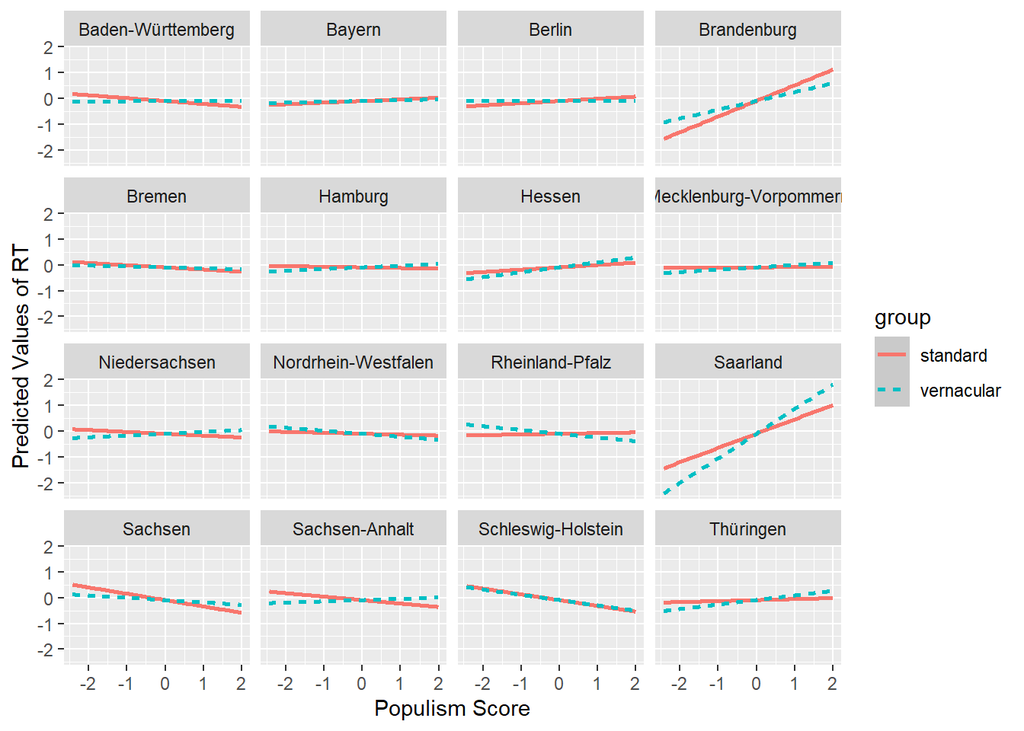

##### subset analyses - low populism

```
## fixed-effect model matrix is rank deficient so dropping 1 column / coefficient
## fixed-effect model matrix is rank deficient so dropping 1 column / coefficient
```

```
## Linear mixed model fit by REML. t-tests use Satterthwaite's method [
## lmerModLmerTest]
## Formula: penal_RTs ~ charisma_lang_var:bundesland + trialcount + age +
##     leadership_lang_var + start_iat + (charisma_lang_var | bilendi_id) +
##     (populism_all | stimulus_ID)
##    Data: Four_Out_low_pop
## Control: lmerControl(optimizer = "bobyqa", optCtrl = list(maxfun = 2e+05))
##
## REML criterion at convergence: 74711.5
##
## Scaled residuals:
##     Min      1Q  Median      3Q     Max
## -4.9202 -0.6277 -0.1368  0.5458 12.3313
##
## Random effects:
##  Groups      Name                        Variance Std.Dev. Corr
##  stimulus_ID (Intercept)                 0.02672  0.16347
##              populism_all                0.00163  0.04037  -0.31
##  bilendi_id  (Intercept)                 0.31405  0.56041
##              charisma_lang_varvernacular 0.54563  0.73867  -0.54
##  Residual                                0.64933  0.80581
## Number of obs: 30093, groups:  stimulus_ID, 303; bilendi_id, 251
##
## Fixed effects:
##                                                                Estimate
## (Intercept)                                                   5.295e-01
## trialcount                                                   -7.115e-03
## age                                                           1.219e-01
## leadership_lang_var2                                          1.352e-01
## start_iatvernacular-with Charisma                            -1.647e-02
## charisma_lang_varstandard:bundeslandBaden-Württemberg         4.709e-01
## charisma_lang_varvernacular:bundeslandBaden-Württemberg       2.157e-01
## charisma_lang_varstandard:bundeslandBayern                    1.082e-01
## charisma_lang_varvernacular:bundeslandBayern                  3.077e-01
## charisma_lang_varstandard:bundeslandBerlin                    2.164e-02
## charisma_lang_varvernacular:bundeslandBerlin                  1.912e-01
## charisma_lang_varstandard:bundeslandBrandenburg              -1.914e-01
## charisma_lang_varvernacular:bundeslandBrandenburg            -1.641e-01
## charisma_lang_varstandard:bundeslandBremen                    6.003e-01
## charisma_lang_varvernacular:bundeslandBremen                  4.163e-01
```

[output cut: 119 more lines]

```
## charisma_lang_varstandard:bundeslandNordrhein-Westfalen      0.210246
## charisma_lang_varvernacular:bundeslandNordrhein-Westfalen    0.105985
## charisma_lang_varstandard:bundeslandRheinland-Pfalz          0.822220
## charisma_lang_varvernacular:bundeslandRheinland-Pfalz        0.500648
## charisma_lang_varstandard:bundeslandSaarland                 0.765897
## charisma_lang_varvernacular:bundeslandSaarland               0.635441
## charisma_lang_varstandard:bundeslandSachsen                  0.310186
## charisma_lang_varvernacular:bundeslandSachsen                0.313173
## charisma_lang_varstandard:bundeslandSachsen-Anhalt           0.825400
## charisma_lang_varvernacular:bundeslandSachsen-Anhalt         0.841546
## charisma_lang_varstandard:bundeslandSchleswig-Holstein       0.128244
## charisma_lang_varvernacular:bundeslandSchleswig-Holstein     0.297545
## charisma_lang_varstandard:bundeslandThüringen                0.231469
## ---
## Signif. codes:  0 '***' 0.001 '**' 0.01 '*' 0.05 '.' 0.1 ' ' 1
```

```
##
## Correlation matrix not shown by default, as p = 36 > 12.
## Use print(x, correlation=TRUE)  or
##     vcov(x)        if you need it
```

```
## fit warnings:
## fixed-effect model matrix is rank deficient so dropping 1 column / coefficient
```

```
## Type III Analysis of Variance Table with Satterthwaite's method
##                              Sum Sq Mean Sq NumDF  DenDF  F value    Pr(>F)
## trialcount                   565.11  565.11     1 4256.3 870.2999 < 2.2e-16 ***
## age                           10.09   10.09     1  231.5  15.5371 0.0001072 ***
## leadership_lang_var            3.05    3.05     1  237.1   4.6980 0.0311935 *
## start_iat                      0.05    0.05     1  232.3   0.0702 0.7913035
## charisma_lang_var:bundesland  17.09    0.55    31  183.2   0.8491 0.6973748
## ---
## Signif. codes:  0 '***' 0.001 '**' 0.01 '*' 0.05 '.' 0.1 ' ' 1
```

```
## fixed-effect model matrix is rank deficient so dropping 1 column / coefficient
## fixed-effect model matrix is rank deficient so dropping 1 column / coefficient
```

```
## Linear mixed model fit by REML. t-tests use Satterthwaite's method [
## lmerModLmerTest]
## Formula: penal_RTs ~ charisma_lang_var:bundesland + trialcount + age +
##     leadership_lang_var + start_iat + (charisma_lang_var | bilendi_id) +
##     (populism_all | stimulus_ID)
##    Data: Four_Out_high_pop
## Control: lmerControl(optimizer = "bobyqa", optCtrl = list(maxfun = 2e+05))
##
## REML criterion at convergence: 79993.3
##
## Scaled residuals:
##     Min      1Q  Median      3Q     Max
## -6.4553 -0.6099 -0.1156  0.5566 13.5242
##
## Random effects:
##  Groups      Name                        Variance Std.Dev. Corr
##  stimulus_ID (Intercept)                 0.020429 0.14293
##              populism_all                0.001096 0.03311  0.26
##  bilendi_id  (Intercept)                 0.341574 0.58444
##              charisma_lang_varvernacular 0.458295 0.67697  -0.24
##  Residual                                0.558570 0.74738
## Number of obs: 34272, groups:  stimulus_ID, 303; bilendi_id, 286
##
## Fixed effects:
##                                                                Estimate
## (Intercept)                                                   4.874e-01
## trialcount                                                   -5.721e-03
## age                                                           9.577e-02
## leadership_lang_var2                                          6.093e-02
## start_iatvernacular-with Charisma                             1.974e-01
## charisma_lang_varstandard:bundeslandBaden-Württemberg         8.488e-02
## charisma_lang_varvernacular:bundeslandBaden-Württemberg       3.334e-02
## charisma_lang_varstandard:bundeslandBayern                    6.531e-02
## charisma_lang_varvernacular:bundeslandBayern                  2.377e-01
## charisma_lang_varstandard:bundeslandBerlin                   -1.643e-02
## charisma_lang_varvernacular:bundeslandBerlin                 -1.268e-01
## charisma_lang_varstandard:bundeslandBrandenburg               7.282e-01
## charisma_lang_varvernacular:bundeslandBrandenburg             5.667e-01
## charisma_lang_varstandard:bundeslandBremen                    6.203e-02
## charisma_lang_varvernacular:bundeslandBremen                 -1.644e-01
```

[output cut: 119 more lines]

```
## charisma_lang_varstandard:bundeslandNordrhein-Westfalen       0.76770
## charisma_lang_varvernacular:bundeslandNordrhein-Westfalen     0.59414
## charisma_lang_varstandard:bundeslandRheinland-Pfalz           0.87009
## charisma_lang_varvernacular:bundeslandRheinland-Pfalz         0.98791
## charisma_lang_varstandard:bundeslandSaarland                  0.31540
## charisma_lang_varvernacular:bundeslandSaarland                0.31183
## charisma_lang_varstandard:bundeslandSachsen                   0.69467
## charisma_lang_varvernacular:bundeslandSachsen                 0.86026
## charisma_lang_varstandard:bundeslandSachsen-Anhalt            0.45589
## charisma_lang_varvernacular:bundeslandSachsen-Anhalt          0.67752
## charisma_lang_varstandard:bundeslandSchleswig-Holstein        0.45679
## charisma_lang_varvernacular:bundeslandSchleswig-Holstein      0.98527
## charisma_lang_varstandard:bundeslandThüringen                 0.92418
## ---
## Signif. codes:  0 '***' 0.001 '**' 0.01 '*' 0.05 '.' 0.1 ' ' 1
```

```
##
## Correlation matrix not shown by default, as p = 36 > 12.
## Use print(x, correlation=TRUE)  or
##     vcov(x)        if you need it
```

```
## fit warnings:
## fixed-effect model matrix is rank deficient so dropping 1 column / coefficient
```

```
## Type III Analysis of Variance Table with Satterthwaite's method
##                              Sum Sq Mean Sq NumDF  DenDF  F value    Pr(>F)
## trialcount                   417.42  417.42     1 4975.6 747.2979 < 2.2e-16 ***
## age                            3.97    3.97     1  267.2   7.1160  0.008107 **
## leadership_lang_var            0.43    0.43     1  270.8   0.7653  0.382436
## start_iat                      4.34    4.34     1  273.8   7.7644  0.005701 **
## charisma_lang_var:bundesland  19.93    0.64    31  219.0   1.1511  0.276194
## ---
## Signif. codes:  0 '***' 0.001 '**' 0.01 '*' 0.05 '.' 0.1 ' ' 1
```

### 3.4.3. Political ideology

#### General

```
## Linear mixed model fit by REML. t-tests use Satterthwaite's method [
## lmerModLmerTest]
## Formula: penal_RTs ~ charisma_lang_var * start_iat * ideology + trialcount +
##     age + leadership_lang_var + (charisma_lang_var | bilendi_id) +
##     (start_iat | stimulus_ID)
##    Data: Four_Out
## Control: lmerControl(optimizer = "bobyqa", optCtrl = list(maxfun = 2e+05))
##
## REML criterion at convergence: 153757.9
##
## Scaled residuals:
##     Min      1Q  Median      3Q     Max
## -6.2927 -0.6203 -0.1218  0.5497 13.5404
##
## Random effects:
##  Groups      Name                              Variance Std.Dev. Corr
##  bilendi_id  (Intercept)                       0.299973 0.54770
##              charisma_lang_varvernacular       0.200112 0.44734  -0.25
##  stimulus_ID (Intercept)                       0.021480 0.14656
##              start_iatvernacular-with Charisma 0.001951 0.04417  -0.05
##  Residual                                      0.598218 0.77345
## Number of obs: 64365, groups:  bilendi_id, 537; stimulus_ID, 303
##
## Fixed effects:
##                                                                          Estimate
## (Intercept)                                                             5.663e-01
## charisma_lang_varvernacular                                             7.603e-01
## start_iatvernacular-with Charisma                                       5.925e-01
## ideology                                                               -5.545e-02
## trialcount                                                             -7.814e-03
## age                                                                     1.052e-01
## leadership_lang_var2                                                    8.970e-02
## charisma_lang_varvernacular:start_iatvernacular-with Charisma          -1.327e+00
## charisma_lang_varvernacular:ideology                                   -1.303e-01
## start_iatvernacular-with Charisma:ideology                              3.624e-02
## charisma_lang_varvernacular:start_iatvernacular-with Charisma:ideology  1.670e-01
##                                                                        Std. Error
## (Intercept)                                                             4.371e-02
## charisma_lang_varvernacular                                             3.382e-02
## start_iatvernacular-with Charisma                                       5.086e-02
```

[output cut: 67 more lines]

[output not shown]

```
## Type III Analysis of Variance Table with Satterthwaite's method
##                                       Sum Sq Mean Sq NumDF DenDF   F value
## charisma_lang_var                      13.53   13.53     1   533   22.6248
## start_iat                               1.37    1.37     1   533    2.2947
## ideology                                3.88    3.88     1   530    6.4828
## trialcount                           1174.57 1174.57     1 63022 1963.4544
## age                                    12.38   12.38     1   531   20.6878
## leadership_lang_var                     2.18    2.18     1   542    3.6404
## charisma_lang_var:start_iat           396.42  396.42     1  1376  662.6644
## charisma_lang_var:ideology              3.06    3.06     1   533    5.1190
## start_iat:ideology                      3.77    3.77     1   530    6.3074
## charisma_lang_var:start_iat:ideology    9.78    9.78     1   533   16.3493
##                                         Pr(>F)
## charisma_lang_var                    2.539e-06 ***
## start_iat                              0.13041
## ideology                               0.01117 *
## trialcount                           < 2.2e-16 ***
## age                                  6.704e-06 ***
## leadership_lang_var                    0.05692 .
## charisma_lang_var:start_iat          < 2.2e-16 ***
## charisma_lang_var:ideology             0.02407 *
## start_iat:ideology                     0.01232 *
## charisma_lang_var:start_iat:ideology 6.046e-05 ***
## ---
## Signif. codes:  0 '***' 0.001 '**' 0.01 '*' 0.05 '.' 0.1 ' ' 1
```

```
## Note: D.f. calculations have been disabled because the number of observations exceeds 3000.
## To enable adjustments, add the argument 'pbkrtest.limit = 64365' (or larger)
## [or, globally, 'set emm_options(pbkrtest.limit = 64365)' or larger];
## but be warned that this may result in large computation time and memory use.
```

```
## Note: D.f. calculations have been disabled because the number of observations exceeds 3000.
## To enable adjustments, add the argument 'lmerTest.limit = 64365' (or larger)
## [or, globally, 'set emm_options(lmerTest.limit = 64365)' or larger];
## but be warned that this may result in large computation time and memory use.
```

```
## start_iat = standard-with Charisma:
##  charisma_lang_var ideology.trend     SE  df asymp.LCL asymp.UCL
##  standard                 -0.0554 0.0380 Inf   -0.1300    0.0191
##  vernacular               -0.1857 0.0424 Inf   -0.2688   -0.1026
##
## start_iat = vernacular-with Charisma:
##  charisma_lang_var ideology.trend     SE  df asymp.LCL asymp.UCL
##  standard                 -0.0192 0.0310 Inf   -0.0800    0.0415
##  vernacular                0.0176 0.0346 Inf   -0.0502    0.0853
##
## Results are averaged over the levels of: leadership_lang_var
## Degrees-of-freedom method: asymptotic
## Confidence level used: 0.95
```

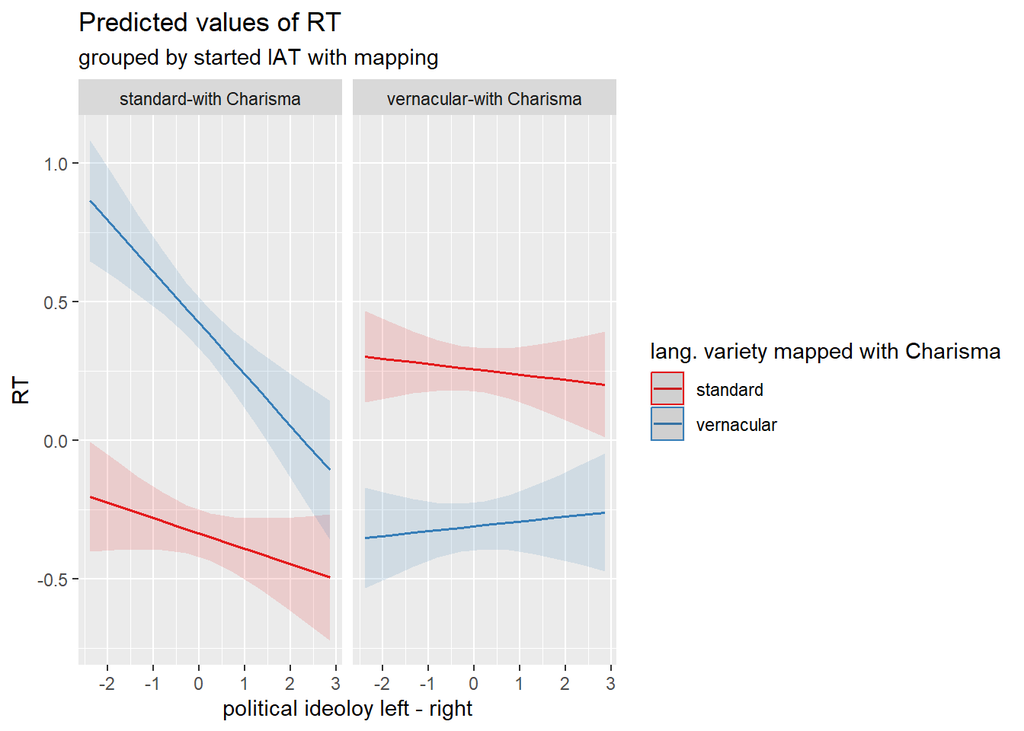

#### Political ideology & gender

```
## Linear mixed model fit by REML. t-tests use Satterthwaite's method [
## lmerModLmerTest]
## Formula:
## penal_RTs ~ charisma_lang_var * ideology * speaker_gender + start_iat +
##     trialcount + age + pp_gender + leadership_lang_var + (charisma_lang_var |
##     bilendi_id) + (start_iat | stimulus_ID)
##    Data: Four_Out
## Control: lmerControl(optimizer = "bobyqa", optCtrl = list(maxfun = 2e+05))
##
## REML criterion at convergence: 154282.1
##
## Scaled residuals:
##     Min      1Q  Median      3Q     Max
## -6.3980 -0.6193 -0.1257  0.5502 13.4532
##
## Random effects:
##  Groups      Name                              Variance Std.Dev. Corr
##  bilendi_id  (Intercept)                       0.327745 0.57249
##              charisma_lang_varvernacular       0.480154 0.69293  -0.37
##  stimulus_ID (Intercept)                       0.021472 0.14653
##              start_iatvernacular-with Charisma 0.001969 0.04438  -0.05
##  Residual                                      0.598957 0.77392
## Number of obs: 64365, groups:  bilendi_id, 537; stimulus_ID, 303
##
## Fixed effects:
##                                                           Estimate Std. Error
## (Intercept)                                              6.034e-01  5.416e-01
## charisma_lang_varvernacular                              4.074e-02  4.350e-02
## ideology                                                -5.034e-02  3.861e-02
## speaker_gendermale                                       7.814e-02  5.335e-02
## start_iatvernacular-with Charisma                        1.234e-01  4.700e-02
## trialcount                                              -6.251e-03  1.567e-04
## age                                                      1.098e-01  2.330e-02
## pp_genderfemale                                         -8.793e-03  5.413e-01
## pp_gendermale                                           -1.234e-02  5.420e-01
## leadership_lang_var2                                     9.209e-02  4.724e-02
## charisma_lang_varvernacular:ideology                    -3.835e-03  4.649e-02
## charisma_lang_varvernacular:speaker_gendermale           2.411e-02  6.109e-02
## ideology:speaker_gendermale                              2.798e-02  5.083e-02
## charisma_lang_varvernacular:ideology:speaker_gendermale -3.182e-02  6.163e-02
```

[output cut: 17 more lines]

```
## charisma_lang_varvernacular                              0.34955
## ideology                                                 0.19313
## speaker_gendermale                                       0.14369
## start_iatvernacular-with Charisma                        0.00889 **
## trialcount                                               < 2e-16 ***
## age                                                     3.12e-06 ***
## pp_genderfemale                                          0.98705
## pp_gendermale                                            0.98184
## leadership_lang_var2                                     0.05175 .
## charisma_lang_varvernacular:ideology                     0.93430
## charisma_lang_varvernacular:speaker_gendermale           0.69326
## ideology:speaker_gendermale                              0.58228
## charisma_lang_varvernacular:ideology:speaker_gendermale  0.60595
## ---
## Signif. codes:  0 '***' 0.001 '**' 0.01 '*' 0.05 '.' 0.1 ' ' 1
```

```
##
## Correlation matrix not shown by default, as p = 14 > 12.
## Use print(x, correlation=TRUE)  or
##     vcov(x)        if you need it
```

```
## Type III Analysis of Variance Table with Satterthwaite's method
##                                           Sum Sq Mean Sq NumDF  DenDF   F value
## charisma_lang_var                           1.79    1.79     1  409.7    2.9829
## ideology                                    2.14    2.14     1  469.9    3.5790
## speaker_gender                              1.87    1.87     1  578.0    3.1219
## start_iat                                   4.13    4.13     1  538.4    6.8956
## trialcount                                953.59  953.59     1 8477.4 1592.0892
## age                                        13.31   13.31     1  527.9   22.2185
## pp_gender                                   0.00    0.00     2  527.9    0.0030
## leadership_lang_var                         2.28    2.28     1  539.6    3.8006
## charisma_lang_var:ideology                  0.25    0.25     1  408.9    0.4106
## charisma_lang_var:speaker_gender            0.09    0.09     1  408.9    0.1558
## ideology:speaker_gender                     0.04    0.04     1  466.8    0.0623
## charisma_lang_var:ideology:speaker_gender   0.16    0.16     1  409.0    0.2665
##                                              Pr(>F)
## charisma_lang_var                          0.084904 .
## ideology                                   0.059129 .
## speaker_gender                             0.077773 .
## start_iat                                  0.008887 **
## trialcount                                < 2.2e-16 ***
## age                                       3.117e-06 ***
## pp_gender                                  0.997014
## leadership_lang_var                        0.051753 .
## charisma_lang_var:ideology                 0.522046
## charisma_lang_var:speaker_gender           0.693260
## ideology:speaker_gender                    0.802968
## charisma_lang_var:ideology:speaker_gender  0.605950
## ---
## Signif. codes:  0 '***' 0.001 '**' 0.01 '*' 0.05 '.' 0.1 ' ' 1
```

### 3.4.4. Voting behaviour

Simple effects in contrasts lang. variety level vernacular and Grün vs. LINKE, CDU/CSU vs. LINKE, AfD vs.LINKe approaching significance

```
## Linear mixed model fit by REML. t-tests use Satterthwaite's method [
## lmerModLmerTest]
## Formula: penal_RTs ~ charisma_lang_var * start_iat * voting_behaviour +
##     trialcount + age + leadership_lang_var + (charisma_lang_var |
##     bilendi_id) + (start_iat | stimulus_ID)
##    Data: Four_Out
## Control: lmerControl(optimizer = "bobyqa", optCtrl = list(maxfun = 2e+05))
##
## REML criterion at convergence: 153806.3
##
## Scaled residuals:
##     Min      1Q  Median      3Q     Max
## -6.2849 -0.6198 -0.1215  0.5499 13.5396
##
## Random effects:
##  Groups      Name                              Variance Std.Dev. Corr
##  bilendi_id  (Intercept)                       0.301842 0.54940
##              charisma_lang_varvernacular       0.205039 0.45281  -0.25
##  stimulus_ID (Intercept)                       0.021459 0.14649
##              start_iatvernacular-with Charisma 0.001946 0.04411  -0.05
##  Residual                                      0.598220 0.77345
## Number of obs: 64365, groups:  bilendi_id, 537; stimulus_ID, 303
##
## Fixed effects:
##                                                                                             Estimate
## (Intercept)                                                                                4.818e-01
## charisma_lang_varvernacular                                                                6.966e-01
## start_iatvernacular-with Charisma                                                          7.204e-01
## voting_behaviourandere                                                                    -6.795e-02
## voting_behaviourCDU/CSU                                                                    5.471e-02
## voting_behaviourDIE LINKE                                                                 -2.260e-02
## voting_behaviourFDP                                                                       -3.994e-02
## voting_behaviourGRüNE                                                                      2.107e-01
## voting_behaviourinvalid                                                                    4.862e-02
## voting_behaviourNichtwähler                                                                6.904e-02
## voting_behaviourno_answer                                                                  1.514e-01
## voting_behaviourSPD                                                                        2.031e-01
## trialcount                                                                                -7.814e-03
## age                                                                                        1.041e-01
## leadership_lang_var2                                                                       8.718e-02
```

[output cut: 235 more lines]

```
## start_iatvernacular-with Charisma:voting_behaviourinvalid
## start_iatvernacular-with Charisma:voting_behaviourNichtwähler
## start_iatvernacular-with Charisma:voting_behaviourno_answer
## start_iatvernacular-with Charisma:voting_behaviourSPD
## charisma_lang_varvernacular:start_iatvernacular-with Charisma:voting_behaviourandere
## charisma_lang_varvernacular:start_iatvernacular-with Charisma:voting_behaviourCDU/CSU
## charisma_lang_varvernacular:start_iatvernacular-with Charisma:voting_behaviourDIE LINKE   .
## charisma_lang_varvernacular:start_iatvernacular-with Charisma:voting_behaviourFDP
## charisma_lang_varvernacular:start_iatvernacular-with Charisma:voting_behaviourGRüNE
## charisma_lang_varvernacular:start_iatvernacular-with Charisma:voting_behaviourinvalid
## charisma_lang_varvernacular:start_iatvernacular-with Charisma:voting_behaviourNichtwähler
## charisma_lang_varvernacular:start_iatvernacular-with Charisma:voting_behaviourno_answer
## charisma_lang_varvernacular:start_iatvernacular-with Charisma:voting_behaviourSPD
## ---
## Signif. codes:  0 '***' 0.001 '**' 0.01 '*' 0.05 '.' 0.1 ' ' 1
```

```
##
## Correlation matrix not shown by default, as p = 43 > 12.
## Use print(x, correlation=TRUE)  or
##     vcov(x)        if you need it
```

```
## Linear mixed model fit by REML. t-tests use Satterthwaite's method [
## lmerModLmerTest]
## Formula: penal_RTs ~ charisma_lang_var * voting_behaviour * start_iat +
##     trialcount + age + leadership_lang_var + (charisma_lang_var |
##     bilendi_id) + (start_iat | stimulus_ID)
##    Data: Four_Out
## Control: lmerControl(optimizer = "bobyqa", optCtrl = list(maxfun = 2e+05))
##
## REML criterion at convergence: 153806.3
##
## Scaled residuals:
##     Min      1Q  Median      3Q     Max
## -6.2849 -0.6198 -0.1215  0.5499 13.5396
##
## Random effects:
##  Groups      Name                              Variance Std.Dev. Corr
##  bilendi_id  (Intercept)                       0.301843 0.54940
##              charisma_lang_varvernacular       0.205038 0.45281  -0.25
##  stimulus_ID (Intercept)                       0.021459 0.14649
##              start_iatvernacular-with Charisma 0.001946 0.04411  -0.05
##  Residual                                      0.598220 0.77345
## Number of obs: 64365, groups:  bilendi_id, 537; stimulus_ID, 303
##
## Fixed effects:
##                                                                                             Estimate
## (Intercept)                                                                                4.418e-01
## charisma_lang_varvernacular                                                                6.172e-01
## voting_behaviourAfD                                                                        3.994e-02
## voting_behaviourandere                                                                    -2.801e-02
## voting_behaviourCDU/CSU                                                                    9.464e-02
## voting_behaviourDIE LINKE                                                                  1.733e-02
## voting_behaviourGRüNE                                                                      2.506e-01
## voting_behaviourinvalid                                                                    8.855e-02
## voting_behaviourNichtwähler                                                                1.090e-01
## voting_behaviourno_answer                                                                  1.913e-01
## voting_behaviourSPD                                                                        2.431e-01
## start_iatvernacular-with Charisma                                                          6.172e-01
## trialcount                                                                                -7.814e-03
## age                                                                                        1.041e-01
## leadership_lang_var2                                                                       8.718e-02
```

[output cut: 235 more lines]

```
## voting_behaviourinvalid:start_iatvernacular-with Charisma
## voting_behaviourNichtwähler:start_iatvernacular-with Charisma
## voting_behaviourno_answer:start_iatvernacular-with Charisma
## voting_behaviourSPD:start_iatvernacular-with Charisma
## charisma_lang_varvernacular:voting_behaviourAfD:start_iatvernacular-with Charisma
## charisma_lang_varvernacular:voting_behaviourandere:start_iatvernacular-with Charisma
## charisma_lang_varvernacular:voting_behaviourCDU/CSU:start_iatvernacular-with Charisma
## charisma_lang_varvernacular:voting_behaviourDIE LINKE:start_iatvernacular-with Charisma
## charisma_lang_varvernacular:voting_behaviourGRüNE:start_iatvernacular-with Charisma
## charisma_lang_varvernacular:voting_behaviourinvalid:start_iatvernacular-with Charisma
## charisma_lang_varvernacular:voting_behaviourNichtwähler:start_iatvernacular-with Charisma
## charisma_lang_varvernacular:voting_behaviourno_answer:start_iatvernacular-with Charisma
## charisma_lang_varvernacular:voting_behaviourSPD:start_iatvernacular-with Charisma
## ---
## Signif. codes:  0 '***' 0.001 '**' 0.01 '*' 0.05 '.' 0.1 ' ' 1
```

```
##
## Correlation matrix not shown by default, as p = 43 > 12.
## Use print(x, correlation=TRUE)  or
##     vcov(x)        if you need it
```

```
## Linear mixed model fit by REML. t-tests use Satterthwaite's method [
## lmerModLmerTest]
## Formula: penal_RTs ~ charisma_lang_var * voting_behaviour * start_iat +
##     trialcount + age + leadership_lang_var + (charisma_lang_var |
##     bilendi_id) + (start_iat | stimulus_ID)
##    Data: Four_Out
## Control: lmerControl(optimizer = "bobyqa", optCtrl = list(maxfun = 2e+05))
##
## REML criterion at convergence: 153806.3
##
## Scaled residuals:
##     Min      1Q  Median      3Q     Max
## -6.2849 -0.6198 -0.1215  0.5499 13.5396
##
## Random effects:
##  Groups      Name                              Variance Std.Dev. Corr
##  bilendi_id  (Intercept)                       0.301843 0.54940
##              charisma_lang_varvernacular       0.205038 0.45281  -0.25
##  stimulus_ID (Intercept)                       0.021459 0.14649
##              start_iatvernacular-with Charisma 0.001946 0.04411  -0.05
##  Residual                                      0.598220 0.77345
## Number of obs: 64365, groups:  bilendi_id, 537; stimulus_ID, 303
##
## Fixed effects:
##                                                                                             Estimate
## (Intercept)                                                                                6.925e-01
## charisma_lang_varvernacular                                                                7.171e-01
## voting_behaviourFDP                                                                       -2.506e-01
## voting_behaviourAfD                                                                       -2.107e-01
## voting_behaviourandere                                                                    -2.786e-01
## voting_behaviourCDU/CSU                                                                   -1.560e-01
## voting_behaviourDIE LINKE                                                                 -2.333e-01
## voting_behaviourinvalid                                                                   -1.621e-01
## voting_behaviourNichtwähler                                                               -1.417e-01
## voting_behaviourno_answer                                                                 -5.934e-02
## voting_behaviourSPD                                                                       -7.574e-03
## start_iatvernacular-with Charisma                                                          5.530e-01
## trialcount                                                                                -7.814e-03
## age                                                                                        1.041e-01
## leadership_lang_var2                                                                       8.718e-02
```

[output cut: 235 more lines]

```
## voting_behaviourinvalid:start_iatvernacular-with Charisma
## voting_behaviourNichtwähler:start_iatvernacular-with Charisma
## voting_behaviourno_answer:start_iatvernacular-with Charisma
## voting_behaviourSPD:start_iatvernacular-with Charisma
## charisma_lang_varvernacular:voting_behaviourFDP:start_iatvernacular-with Charisma
## charisma_lang_varvernacular:voting_behaviourAfD:start_iatvernacular-with Charisma
## charisma_lang_varvernacular:voting_behaviourandere:start_iatvernacular-with Charisma
## charisma_lang_varvernacular:voting_behaviourCDU/CSU:start_iatvernacular-with Charisma
## charisma_lang_varvernacular:voting_behaviourDIE LINKE:start_iatvernacular-with Charisma   *
## charisma_lang_varvernacular:voting_behaviourinvalid:start_iatvernacular-with Charisma
## charisma_lang_varvernacular:voting_behaviourNichtwähler:start_iatvernacular-with Charisma
## charisma_lang_varvernacular:voting_behaviourno_answer:start_iatvernacular-with Charisma   .
## charisma_lang_varvernacular:voting_behaviourSPD:start_iatvernacular-with Charisma
## ---
## Signif. codes:  0 '***' 0.001 '**' 0.01 '*' 0.05 '.' 0.1 ' ' 1
```

```
##
## Correlation matrix not shown by default, as p = 43 > 12.
## Use print(x, correlation=TRUE)  or
##     vcov(x)        if you need it
```

```
## Linear mixed model fit by REML. t-tests use Satterthwaite's method [
## lmerModLmerTest]
## Formula: penal_RTs ~ charisma_lang_var * voting_behaviour * start_iat +
##     trialcount + age + leadership_lang_var + (charisma_lang_var |
##     bilendi_id) + (start_iat | stimulus_ID)
##    Data: Four_Out
## Control: lmerControl(optimizer = "bobyqa", optCtrl = list(maxfun = 2e+05))
##
## REML criterion at convergence: 153806.3
##
## Scaled residuals:
##     Min      1Q  Median      3Q     Max
## -6.2849 -0.6198 -0.1215  0.5499 13.5396
##
## Random effects:
##  Groups      Name                              Variance Std.Dev. Corr
##  bilendi_id  (Intercept)                       0.301843 0.54940
##              charisma_lang_varvernacular       0.205039 0.45281  -0.25
##  stimulus_ID (Intercept)                       0.021459 0.14649
##              start_iatvernacular-with Charisma 0.001946 0.04411  -0.05
##  Residual                                      0.598220 0.77345
## Number of obs: 64365, groups:  bilendi_id, 537; stimulus_ID, 303
##
## Fixed effects:
##                                                                                             Estimate
## (Intercept)                                                                                5.365e-01
## charisma_lang_varvernacular                                                                6.609e-01
## voting_behaviourGRüNE                                                                      1.560e-01
## voting_behaviourFDP                                                                       -9.464e-02
## voting_behaviourAfD                                                                       -5.471e-02
## voting_behaviourandere                                                                    -1.227e-01
## voting_behaviourDIE LINKE                                                                 -7.731e-02
## voting_behaviourinvalid                                                                   -6.092e-03
## voting_behaviourNichtwähler                                                                1.434e-02
## voting_behaviourno_answer                                                                  9.665e-02
## voting_behaviourSPD                                                                        1.484e-01
## start_iatvernacular-with Charisma                                                          5.124e-01
## trialcount                                                                                -7.814e-03
## age                                                                                        1.041e-01
## leadership_lang_var2                                                                       8.718e-02
```

[output cut: 235 more lines]

```
## voting_behaviourinvalid:start_iatvernacular-with Charisma
## voting_behaviourNichtwähler:start_iatvernacular-with Charisma
## voting_behaviourno_answer:start_iatvernacular-with Charisma
## voting_behaviourSPD:start_iatvernacular-with Charisma
## charisma_lang_varvernacular:voting_behaviourGRüNE:start_iatvernacular-with Charisma
## charisma_lang_varvernacular:voting_behaviourFDP:start_iatvernacular-with Charisma
## charisma_lang_varvernacular:voting_behaviourAfD:start_iatvernacular-with Charisma
## charisma_lang_varvernacular:voting_behaviourandere:start_iatvernacular-with Charisma
## charisma_lang_varvernacular:voting_behaviourDIE LINKE:start_iatvernacular-with Charisma   *
## charisma_lang_varvernacular:voting_behaviourinvalid:start_iatvernacular-with Charisma
## charisma_lang_varvernacular:voting_behaviourNichtwähler:start_iatvernacular-with Charisma
## charisma_lang_varvernacular:voting_behaviourno_answer:start_iatvernacular-with Charisma   .
## charisma_lang_varvernacular:voting_behaviourSPD:start_iatvernacular-with Charisma
## ---
## Signif. codes:  0 '***' 0.001 '**' 0.01 '*' 0.05 '.' 0.1 ' ' 1
```

```
##
## Correlation matrix not shown by default, as p = 43 > 12.
## Use print(x, correlation=TRUE)  or
##     vcov(x)        if you need it
```

```
## Linear mixed model fit by REML. t-tests use Satterthwaite's method [
## lmerModLmerTest]
## Formula: penal_RTs ~ charisma_lang_var * voting_behaviour * start_iat +
##     trialcount + age + leadership_lang_var + (charisma_lang_var |
##     bilendi_id) + (start_iat | stimulus_ID)
##    Data: Four_Out
## Control: lmerControl(optimizer = "bobyqa", optCtrl = list(maxfun = 2e+05))
##
## REML criterion at convergence: 153806.3
##
## Scaled residuals:
##     Min      1Q  Median      3Q     Max
## -6.2849 -0.6198 -0.1215  0.5499 13.5396
##
## Random effects:
##  Groups      Name                              Variance Std.Dev. Corr
##  bilendi_id  (Intercept)                       0.301843 0.54940
##              charisma_lang_varvernacular       0.205039 0.45281  -0.25
##  stimulus_ID (Intercept)                       0.021459 0.14649
##              start_iatvernacular-with Charisma 0.001946 0.04411  -0.05
##  Residual                                      0.598220 0.77345
## Number of obs: 64365, groups:  bilendi_id, 537; stimulus_ID, 303
##
## Fixed effects:
##                                                                                             Estimate
## (Intercept)                                                                                4.592e-01
## charisma_lang_varvernacular                                                                1.094e+00
## voting_behaviourCDU/CSU                                                                    7.731e-02
## voting_behaviourGRüNE                                                                      2.333e-01
## voting_behaviourFDP                                                                       -1.733e-02
## voting_behaviourAfD                                                                        2.260e-02
## voting_behaviourandere                                                                    -4.534e-02
## voting_behaviourinvalid                                                                    7.122e-02
## voting_behaviourNichtwähler                                                                9.165e-02
## voting_behaviourno_answer                                                                  1.740e-01
## voting_behaviourSPD                                                                        2.257e-01
## start_iatvernacular-with Charisma                                                          6.215e-01
## trialcount                                                                                -7.814e-03
## age                                                                                        1.041e-01
## leadership_lang_var2                                                                       8.718e-02
```

[output cut: 235 more lines]

```
## voting_behaviourinvalid:start_iatvernacular-with Charisma
## voting_behaviourNichtwähler:start_iatvernacular-with Charisma
## voting_behaviourno_answer:start_iatvernacular-with Charisma
## voting_behaviourSPD:start_iatvernacular-with Charisma
## charisma_lang_varvernacular:voting_behaviourCDU/CSU:start_iatvernacular-with Charisma     *
## charisma_lang_varvernacular:voting_behaviourGRüNE:start_iatvernacular-with Charisma       *
## charisma_lang_varvernacular:voting_behaviourFDP:start_iatvernacular-with Charisma
## charisma_lang_varvernacular:voting_behaviourAfD:start_iatvernacular-with Charisma         .
## charisma_lang_varvernacular:voting_behaviourandere:start_iatvernacular-with Charisma
## charisma_lang_varvernacular:voting_behaviourinvalid:start_iatvernacular-with Charisma     **
## charisma_lang_varvernacular:voting_behaviourNichtwähler:start_iatvernacular-with Charisma .
## charisma_lang_varvernacular:voting_behaviourno_answer:start_iatvernacular-with Charisma
## charisma_lang_varvernacular:voting_behaviourSPD:start_iatvernacular-with Charisma
## ---
## Signif. codes:  0 '***' 0.001 '**' 0.01 '*' 0.05 '.' 0.1 ' ' 1
```

```
##
## Correlation matrix not shown by default, as p = 43 > 12.
## Use print(x, correlation=TRUE)  or
##     vcov(x)        if you need it
```

```
## Type III Analysis of Variance Table with Satterthwaite's method
##                                               Sum Sq Mean Sq NumDF DenDF
## charisma_lang_var                              11.60   11.60     1   517
## voting_behaviour                                8.65    0.96     9   514
## start_iat                                       0.07    0.07     1   517
## trialcount                                   1174.60 1174.60     1 63022
## age                                            11.11   11.11     1   515
## leadership_lang_var                             1.98    1.98     1   525
## charisma_lang_var:voting_behaviour              7.46    0.83     9   517
## charisma_lang_var:start_iat                   300.50  300.50     1  1034
## voting_behaviour:start_iat                      5.35    0.59     9   514
## charisma_lang_var:voting_behaviour:start_iat    7.48    0.83     9   517
##                                                F value    Pr(>F)
## charisma_lang_var                              19.3852 1.299e-05 ***
## voting_behaviour                                1.6067   0.11016
## start_iat                                       0.1204   0.72877
## trialcount                                   1963.4919 < 2.2e-16 ***
## age                                            18.5742 1.958e-05 ***
## leadership_lang_var                             3.3078   0.06952 .
## charisma_lang_var:voting_behaviour              1.3847   0.19180
## charisma_lang_var:start_iat                   502.3316 < 2.2e-16 ***
## voting_behaviour:start_iat                      0.9940   0.44384
## charisma_lang_var:voting_behaviour:start_iat    1.3891   0.18983
## ---
## Signif. codes:  0 '***' 0.001 '**' 0.01 '*' 0.05 '.' 0.1 ' ' 1
```

```
## Note: D.f. calculations have been disabled because the number of observations exceeds 3000.
## To enable adjustments, add the argument 'pbkrtest.limit = 64365' (or larger)
## [or, globally, 'set emm_options(pbkrtest.limit = 64365)' or larger];
## but be warned that this may result in large computation time and memory use.
```

```
## Note: D.f. calculations have been disabled because the number of observations exceeds 3000.
## To enable adjustments, add the argument 'lmerTest.limit = 64365' (or larger)
## [or, globally, 'set emm_options(lmerTest.limit = 64365)' or larger];
## but be warned that this may result in large computation time and memory use.
```

```
## $emmeans
##  charisma_lang_var start_iat                voting_behaviour emmean     SE  df
##  standard          standard-with Charisma   DIE LINKE        -0.400 0.1505 Inf
##  vernacular        standard-with Charisma   DIE LINKE         0.694 0.1682 Inf
##  standard          vernacular-with Charisma DIE LINKE         0.222 0.1172 Inf
##  vernacular        vernacular-with Charisma DIE LINKE        -0.340 0.1310 Inf
##  standard          standard-with Charisma   CDU/CSU          -0.322 0.0841 Inf
##  vernacular        standard-with Charisma   CDU/CSU           0.339 0.0938 Inf
##  standard          vernacular-with Charisma CDU/CSU           0.190 0.0760 Inf
##  vernacular        vernacular-with Charisma CDU/CSU          -0.367 0.0847 Inf
##  standard          standard-with Charisma   GRüNE            -0.166 0.0850 Inf
##  vernacular        standard-with Charisma   GRüNE             0.551 0.0950 Inf
##  standard          vernacular-with Charisma GRüNE             0.387 0.0771 Inf
##  vernacular        vernacular-with Charisma GRüNE            -0.146 0.0861 Inf
##  standard          standard-with Charisma   FDP              -0.417 0.1413 Inf
##  vernacular        standard-with Charisma   FDP               0.200 0.1578 Inf
##  standard          vernacular-with Charisma FDP               0.200 0.1289 Inf
##  vernacular        vernacular-with Charisma FDP              -0.484 0.1441 Inf
##  standard          standard-with Charisma   AfD              -0.377 0.1172 Inf
##  vernacular        standard-with Charisma   AfD               0.320 0.1310 Inf
##  standard          vernacular-with Charisma AfD               0.343 0.0916 Inf
##  vernacular        vernacular-with Charisma AfD              -0.268 0.1023 Inf
##  standard          standard-with Charisma   andere           -0.445 0.1173 Inf
##  vernacular        standard-with Charisma   andere            0.353 0.1311 Inf
##  standard          vernacular-with Charisma andere            0.319 0.1289 Inf
##  vernacular        vernacular-with Charisma andere           -0.225 0.1441 Inf
##  standard          standard-with Charisma   invalid          -0.328 0.1981 Inf
##  vernacular        standard-with Charisma   invalid           0.296 0.2216 Inf
##  standard          vernacular-with Charisma invalid           0.389 0.2511 Inf
##  vernacular        vernacular-with Charisma invalid           0.177 0.2808 Inf
##  standard          standard-with Charisma   Nichtwähler      -0.308 0.1323 Inf
##  vernacular        standard-with Charisma   Nichtwähler       0.364 0.1479 Inf
##  standard          vernacular-with Charisma Nichtwähler       0.547 0.1554 Inf
##  vernacular        vernacular-with Charisma Nichtwähler      -0.048 0.1738 Inf
##  standard          standard-with Charisma   no_answer        -0.226 0.1198 Inf
##  vernacular        standard-with Charisma   no_answer         0.651 0.1339 Inf
##  standard          vernacular-with Charisma no_answer         0.332 0.1130 Inf
##  vernacular        vernacular-with Charisma no_answer        -0.328 0.1262 Inf
##  standard          standard-with Charisma   SPD              -0.174 0.0979 Inf
##  vernacular        standard-with Charisma   SPD               0.718 0.1094 Inf
```

[output cut: 1600 more lines]

```
##   5.77e-01 0.1532 Inf   3.769  0.0747
##  -1.55e-01 0.1589 Inf  -0.973  1.0000
##  -1.05e+00 0.1670 Inf  -6.265  <.0001
##  -6.04e-01 0.1567 Inf  -3.854  0.0561
##  -8.30e-02 0.1624 Inf  -0.511  1.0000
##  -8.91e-01 0.0841 Inf -10.599  <.0001
##  -4.49e-01 0.1344 Inf  -3.343  0.2561
##   7.15e-02 0.1411 Inf   0.507  1.0000
##   4.42e-01 0.1422 Inf   3.109  0.4265
##   9.63e-01 0.1501 Inf   6.414  <.0001
##   5.21e-01 0.0786 Inf   6.628  <.0001
##
## Results are averaged over the levels of: leadership_lang_var
## Degrees-of-freedom method: asymptotic
## P value adjustment: tukey method for comparing a family of 40 estimates
```

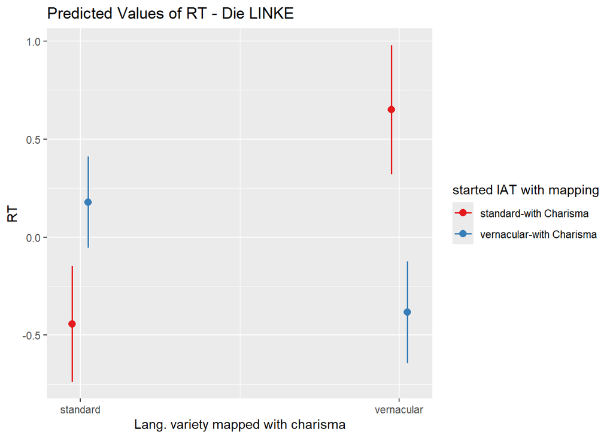

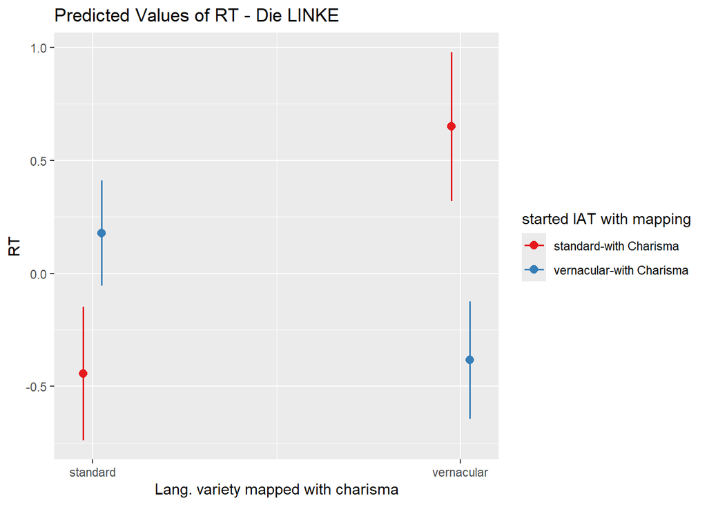

```
## Linear mixed model fit by REML. t-tests use Satterthwaite's method [
## lmerModLmerTest]
## Formula: penal_RTs ~ charisma_lang_var * voting_behaviour * start_iat +
##     trialcount + age + leadership_lang_var + (charisma_lang_var |
##     bilendi_id) + (start_iat | stimulus_ID)
##    Data: Four_Out
## Control: lmerControl(optimizer = "bobyqa", optCtrl = list(maxfun = 2e+05))
##
## REML criterion at convergence: 153806.3
##
## Scaled residuals:
##     Min      1Q  Median      3Q     Max
## -6.2849 -0.6198 -0.1215  0.5499 13.5396
##
## Random effects:
##  Groups      Name                              Variance Std.Dev. Corr
##  bilendi_id  (Intercept)                       0.301842 0.54940
##              charisma_lang_varvernacular       0.205039 0.45281  -0.25
##  stimulus_ID (Intercept)                       0.021459 0.14649
##              start_iatvernacular-with Charisma 0.001946 0.04411  -0.05
##  Residual                                      0.598220 0.77345
## Number of obs: 64365, groups:  bilendi_id, 537; stimulus_ID, 303
##
## Fixed effects:
##                                                                                             Estimate
## (Intercept)                                                                                6.849e-01
## charisma_lang_varvernacular                                                                8.915e-01
## voting_behaviourDIE LINKE                                                                 -2.257e-01
## voting_behaviourCDU/CSU                                                                   -1.484e-01
## voting_behaviourGRüNE                                                                      7.574e-03
## voting_behaviourFDP                                                                       -2.431e-01
## voting_behaviourAfD                                                                       -2.031e-01
## voting_behaviourandere                                                                    -2.711e-01
## voting_behaviourinvalid                                                                   -1.545e-01
## voting_behaviourNichtwähler                                                               -1.341e-01
## voting_behaviourno_answer                                                                 -5.177e-02
## start_iatvernacular-with Charisma                                                          4.494e-01
## trialcount                                                                                -7.814e-03
## age                                                                                        1.041e-01
## leadership_lang_var2                                                                       8.718e-02
```

[output cut: 235 more lines]

```
## voting_behaviourandere:start_iatvernacular-with Charisma
## voting_behaviourinvalid:start_iatvernacular-with Charisma
## voting_behaviourNichtwähler:start_iatvernacular-with Charisma                             .
## voting_behaviourno_answer:start_iatvernacular-with Charisma
## charisma_lang_varvernacular:voting_behaviourDIE LINKE:start_iatvernacular-with Charisma
## charisma_lang_varvernacular:voting_behaviourCDU/CSU:start_iatvernacular-with Charisma
## charisma_lang_varvernacular:voting_behaviourGRüNE:start_iatvernacular-with Charisma
## charisma_lang_varvernacular:voting_behaviourFDP:start_iatvernacular-with Charisma
## charisma_lang_varvernacular:voting_behaviourAfD:start_iatvernacular-with Charisma
## charisma_lang_varvernacular:voting_behaviourandere:start_iatvernacular-with Charisma
## charisma_lang_varvernacular:voting_behaviourinvalid:start_iatvernacular-with Charisma     *
## charisma_lang_varvernacular:voting_behaviourNichtwähler:start_iatvernacular-with Charisma
## charisma_lang_varvernacular:voting_behaviourno_answer:start_iatvernacular-with Charisma
## ---
## Signif. codes:  0 '***' 0.001 '**' 0.01 '*' 0.05 '.' 0.1 ' ' 1
```

```
##
## Correlation matrix not shown by default, as p = 43 > 12.
## Use print(x, correlation=TRUE)  or
##     vcov(x)        if you need it
```

```
## Linear mixed model fit by REML. t-tests use Satterthwaite's method [
## lmerModLmerTest]
## Formula: penal_RTs ~ charisma_lang_var * voting_behaviour * start_iat +
##     trialcount + age + leadership_lang_var + (charisma_lang_var |
##     bilendi_id) + (start_iat | stimulus_ID)
##    Data: Four_Out
## Control: lmerControl(optimizer = "bobyqa", optCtrl = list(maxfun = 2e+05))
##
## REML criterion at convergence: 153806.3
##
## Scaled residuals:
##     Min      1Q  Median      3Q     Max
## -6.2849 -0.6198 -0.1215  0.5499 13.5396
##
## Random effects:
##  Groups      Name                              Variance Std.Dev. Corr
##  bilendi_id  (Intercept)                       0.301842 0.54940
##              charisma_lang_varvernacular       0.205039 0.45281  -0.25
##  stimulus_ID (Intercept)                       0.021459 0.14649
##              start_iatvernacular-with Charisma 0.001946 0.04411  -0.05
##  Residual                                      0.598220 0.77345
## Number of obs: 64365, groups:  bilendi_id, 537; stimulus_ID, 303
##
## Fixed effects:
##                                                                                           Estimate
## (Intercept)                                                                              5.508e-01
## charisma_lang_varvernacular                                                              6.715e-01
## voting_behaviourSPD                                                                      1.341e-01
## voting_behaviourDIE LINKE                                                               -9.165e-02
## voting_behaviourCDU/CSU                                                                 -1.434e-02
## voting_behaviourGRüNE                                                                    1.417e-01
## voting_behaviourFDP                                                                     -1.090e-01
## voting_behaviourAfD                                                                     -6.904e-02
## voting_behaviourandere                                                                  -1.370e-01
## voting_behaviourinvalid                                                                 -2.043e-02
## voting_behaviourno_answer                                                                8.231e-02
## start_iatvernacular-with Charisma                                                        8.547e-01
## trialcount                                                                              -7.814e-03
## age                                                                                      1.041e-01
## leadership_lang_var2                                                                     8.718e-02
```

[output cut: 235 more lines]

```
## voting_behaviourAfD:start_iatvernacular-with Charisma
## voting_behaviourandere:start_iatvernacular-with Charisma
## voting_behaviourinvalid:start_iatvernacular-with Charisma
## voting_behaviourno_answer:start_iatvernacular-with Charisma
## charisma_lang_varvernacular:voting_behaviourSPD:start_iatvernacular-with Charisma
## charisma_lang_varvernacular:voting_behaviourDIE LINKE:start_iatvernacular-with Charisma .
## charisma_lang_varvernacular:voting_behaviourCDU/CSU:start_iatvernacular-with Charisma
## charisma_lang_varvernacular:voting_behaviourGRüNE:start_iatvernacular-with Charisma
## charisma_lang_varvernacular:voting_behaviourFDP:start_iatvernacular-with Charisma
## charisma_lang_varvernacular:voting_behaviourAfD:start_iatvernacular-with Charisma
## charisma_lang_varvernacular:voting_behaviourandere:start_iatvernacular-with Charisma
## charisma_lang_varvernacular:voting_behaviourinvalid:start_iatvernacular-with Charisma
## charisma_lang_varvernacular:voting_behaviourno_answer:start_iatvernacular-with Charisma
## ---
## Signif. codes:  0 '***' 0.001 '**' 0.01 '*' 0.05 '.' 0.1 ' ' 1
```

```
##
## Correlation matrix not shown by default, as p = 43 > 12.
## Use print(x, correlation=TRUE)  or
##     vcov(x)        if you need it
```

## 3.5. Impact of language variety & SES

RQ: Do variables of participants’ SES mediate how language variety impacts on reaction times?

### 3.5.1. Max.model

simple effects for charisma_lang_varvernacular:education Realschulabschluss, Mittlere Reife, Fachschulreife oder Abschluss der polytechnischen Oberschule 10. Klasse, as well as Azubi/SchülerIn

```
## Linear mixed model fit by REML. t-tests use Satterthwaite's method [
## lmerModLmerTest]
## Formula: penal_RTs ~ charisma_lang_var * start_iat + trialcount + stim_cat +
##     leadership_lang_var + sum_education:charisma_lang_var + employment_status:charisma_lang_var +
##     sum_training:charisma_lang_var + monthly_income:charisma_lang_var +
##     (charisma_lang_var | bilendi_id) + (1 | stimulus_ID)
##    Data: Four_Out
## Control: lmerControl(optimizer = "bobyqa", optCtrl = list(maxfun = 2e+05))
##
## REML criterion at convergence: 153493.1
##
## Scaled residuals:
##     Min      1Q  Median      3Q     Max
## -6.3104 -0.6211 -0.1205  0.5494 13.5596
##
## Random effects:
##  Groups      Name                        Variance Std.Dev. Corr
##  bilendi_id  (Intercept)                 0.29989  0.5476
##              charisma_lang_varvernacular 0.21015  0.4584   -0.23
##  stimulus_ID (Intercept)                 0.01502  0.1226
##  Residual                                0.59889  0.7739
## Number of obs: 64245, groups:  bilendi_id, 536; stimulus_ID, 303
##
## Fixed effects:
##                                                                                                 Estimate
## (Intercept)                                                                                   -4.582e-01
## charisma_lang_varvernacular                                                                    7.753e-01
## start_iatvernacular-with Charisma                                                              5.777e-01
## trialcount                                                                                    -7.824e-03
## stim_catleadership                                                                             1.824e-01
## leadership_lang_var2                                                                           8.055e-02
## charisma_lang_varvernacular:start_iatvernacular-with Charisma                                 -1.316e+00
## charisma_lang_varstandard:sum_educationlow                                                    -2.504e-01
## charisma_lang_varvernacular:sum_educationlow                                                  -2.023e-01
## charisma_lang_varstandard:sum_educationmiddle                                                 -1.100e-01
## charisma_lang_varvernacular:sum_educationmiddle                                               -7.546e-02
## charisma_lang_varstandard:sum_educationother                                                   3.980e-01
## charisma_lang_varvernacular:sum_educationother                                                -3.076e-01
## charisma_lang_varstandard:sum_educationstill at school                                        -1.534e-01
## charisma_lang_varvernacular:sum_educationstill at school                                      -7.111e-03
```

[output cut: 379 more lines]

```
## charisma_lang_varvernacular:monthly_income500 bis unter 750 Euro
## charisma_lang_varstandard:monthly_income5000 bis unter 7500 Euro
## charisma_lang_varvernacular:monthly_income5000 bis unter 7500 Euro
## charisma_lang_varstandard:monthly_income750 bis unter 1000 Euro
## charisma_lang_varvernacular:monthly_income750 bis unter 1000 Euro
## charisma_lang_varstandard:monthly_income7500 bis unter 10000 Euro
## charisma_lang_varvernacular:monthly_income7500 bis unter 10000 Euro
## charisma_lang_varstandard:monthly_incomemöchte Frage nicht beantworten
## charisma_lang_varvernacular:monthly_incomemöchte Frage nicht beantworten
## charisma_lang_varstandard:monthly_incomeunter 500 Euro
## charisma_lang_varvernacular:monthly_incomeunter 500 Euro
## charisma_lang_varstandard:monthly_incomeweiß nicht
## charisma_lang_varvernacular:monthly_incomeweiß nicht
## ---
## Signif. codes:  0 '***' 0.001 '**' 0.01 '*' 0.05 '.' 0.1 ' ' 1
```

```
##
## Correlation matrix not shown by default, as p = 67 > 12.
## Use print(x, correlation=TRUE)  or
##     vcov(x)        if you need it
```

```
## Type III Analysis of Variance Table with Satterthwaite's method
##                                      Sum Sq Mean Sq NumDF DenDF   F value
## charisma_lang_var                      0.03    0.03     1   504    0.0561
## start_iat                              1.60    1.60     1   502    2.6794
## trialcount                          1176.38 1176.38     1 62953 1964.2880
## stim_cat                              63.78   63.78     1   264  106.5006
## leadership_lang_var                    1.67    1.67     1   512    2.7954
## charisma_lang_var:start_iat          362.36  362.36     1  1199  605.0610
## charisma_lang_var:sum_education        4.60    0.57     8   503    0.9601
## charisma_lang_var:employment_status   20.42    1.02    20   503    1.7046
## charisma_lang_var:sum_training         0.45    0.11     4   503    0.1859
## charisma_lang_var:monthly_income      15.65    0.56    28   503    0.9331
##                                      Pr(>F)
## charisma_lang_var                   0.81283
## start_iat                           0.10228
## trialcount                          < 2e-16 ***
## stim_cat                            < 2e-16 ***
## leadership_lang_var                 0.09515 .
## charisma_lang_var:start_iat         < 2e-16 ***
## charisma_lang_var:sum_education     0.46654
## charisma_lang_var:employment_status 0.02918 *
## charisma_lang_var:sum_training      0.94575
## charisma_lang_var:monthly_income    0.56622
## ---
## Signif. codes:  0 '***' 0.001 '**' 0.01 '*' 0.05 '.' 0.1 ' ' 1
```

### 3.5.2. Focus income

```
## fixed-effect model matrix is rank deficient so dropping 2 columns / coefficients
## fixed-effect model matrix is rank deficient so dropping 2 columns / coefficients
```

```
## Linear mixed model fit by REML. t-tests use Satterthwaite's method [
## lmerModLmerTest]
## Formula: penal_RTs ~ charisma_lang_var * start_iat * monthly_income +
##     trialcount + stim_cat + age + leadership_lang_var + (charisma_lang_var |
##     bilendi_id) + (start_iat | stimulus_ID)
##    Data: Four_Out
## Control: lmerControl(optimizer = "bobyqa", optCtrl = list(maxfun = 2e+05))
##
## REML criterion at convergence: 153727.1
##
## Scaled residuals:
##     Min      1Q  Median      3Q     Max
## -6.3015 -0.6205 -0.1217  0.5479 13.5363
##
## Random effects:
##  Groups      Name                              Variance Std.Dev. Corr
##  bilendi_id  (Intercept)                       0.293830 0.54206
##              charisma_lang_varvernacular       0.210984 0.45933  -0.23
##  stimulus_ID (Intercept)                       0.016578 0.12876
##              start_iatvernacular-with Charisma 0.001869 0.04323  -0.35
##  Residual                                      0.598258 0.77347
## Number of obs: 64365, groups:  bilendi_id, 537; stimulus_ID, 303
##
## Fixed effects:
##                                                                                                              Estimate
## (Intercept)                                                                                                 3.585e-01
## charisma_lang_varvernacular                                                                                 7.282e-01
## start_iatvernacular-with Charisma                                                                           5.546e-01
## monthly_income10000 Euro und mehr                                                                          -4.287e-01
## monthly_income1250 bis unter 1500 Euro                                                                      5.708e-02
## monthly_income1500 bis unter 2000 Euro                                                                      1.238e-01
## monthly_income2000 bis unter 2500 Euro                                                                      1.399e-01
## monthly_income2500 bis unter 3000 Euro                                                                      4.160e-01
## monthly_income3000 bis unter 4000 Euro                                                                     -6.236e-02
## monthly_income4000 bis unter 5000 Euro                                                                     -1.254e-02
## monthly_income500 bis unter 750 Euro                                                                        2.332e-01
## monthly_income5000 bis unter 7500 Euro                                                                     -8.157e-02
## monthly_income750 bis unter 1000 Euro                                                                      -1.920e-01
## monthly_income7500 bis unter 10000 Euro                                                                    -7.227e-02
## monthly_incomemöchte Frage nicht beantworten                                                                4.917e-01
```

[output cut: 349 more lines]

```
## charisma_lang_varvernacular:start_iatvernacular-with Charisma:monthly_income10000 Euro und mehr
## charisma_lang_varvernacular:start_iatvernacular-with Charisma:monthly_income1250 bis unter 1500 Euro
## charisma_lang_varvernacular:start_iatvernacular-with Charisma:monthly_income1500 bis unter 2000 Euro
## charisma_lang_varvernacular:start_iatvernacular-with Charisma:monthly_income2000 bis unter 2500 Euro
## charisma_lang_varvernacular:start_iatvernacular-with Charisma:monthly_income2500 bis unter 3000 Euro
## charisma_lang_varvernacular:start_iatvernacular-with Charisma:monthly_income3000 bis unter 4000 Euro
## charisma_lang_varvernacular:start_iatvernacular-with Charisma:monthly_income4000 bis unter 5000 Euro
## charisma_lang_varvernacular:start_iatvernacular-with Charisma:monthly_income500 bis unter 750 Euro
## charisma_lang_varvernacular:start_iatvernacular-with Charisma:monthly_income5000 bis unter 7500 Euro
## charisma_lang_varvernacular:start_iatvernacular-with Charisma:monthly_income750 bis unter 1000 Euro
## charisma_lang_varvernacular:start_iatvernacular-with Charisma:monthly_income7500 bis unter 10000 Euro
## charisma_lang_varvernacular:start_iatvernacular-with Charisma:monthly_incomemöchte Frage nicht beantworten
## charisma_lang_varvernacular:start_iatvernacular-with Charisma:monthly_incomeunter 500 Euro
## ---
## Signif. codes:  0 '***' 0.001 '**' 0.01 '*' 0.05 '.' 0.1 ' ' 1
```

```
##
## Correlation matrix not shown by default, as p = 62 > 12.
## Use print(x, correlation=TRUE)  or
##     vcov(x)        if you need it
```

```
## fit warnings:
## fixed-effect model matrix is rank deficient so dropping 2 columns / coefficients
```

```
## Missing cells for: start_iatvernacular-with Charisma:monthly_incomeweiß nicht, charisma_lang_varstandard:start_iatvernacular-with Charisma:monthly_incomeweiß nicht, charisma_lang_varvernacular:start_iatvernacular-with Charisma:monthly_incomeweiß nicht.
## Interpret type III hypotheses with care.
```

```
## Type III Analysis of Variance Table with Satterthwaite's method
##                                             Sum Sq Mean Sq NumDF DenDF
## charisma_lang_var                             3.57    3.57     1   508
## start_iat                                     0.08    0.08     1   507
## monthly_income                               10.82    0.77    14   505
## trialcount                                 1174.56 1174.56     1 63036
## stim_cat                                     66.78   66.78     1   263
## age                                          11.05   11.05     1   506
## leadership_lang_var                           2.08    2.08     1   515
## charisma_lang_var:start_iat                 209.31  209.31     1   790
## charisma_lang_var:monthly_income              4.79    0.34    14   508
## start_iat:monthly_income                      9.51    0.73    13   505
## charisma_lang_var:start_iat:monthly_income    5.68    0.44    13   508
##                                              F value    Pr(>F)
## charisma_lang_var                             5.9755   0.01484 *
## start_iat                                     0.1293   0.71929
## monthly_income                                1.2924   0.20738
## trialcount                                 1963.3067 < 2.2e-16 ***
## stim_cat                                    111.6305 < 2.2e-16 ***
## age                                          18.4721 2.069e-05 ***
## leadership_lang_var                           3.4785   0.06274 .
## charisma_lang_var:start_iat                 349.8620 < 2.2e-16 ***
## charisma_lang_var:monthly_income              0.5715   0.88768
## start_iat:monthly_income                      1.2227   0.25898
## charisma_lang_var:start_iat:monthly_income    0.7302   0.73375
## ---
## Signif. codes:  0 '***' 0.001 '**' 0.01 '*' 0.05 '.' 0.1 ' ' 1
```

### 3.5.2. Focus education

```
## [1] Abitur bzw. erweiterte Oberschule mit Abschluss 12. Klasse (Hochschulreife)
## [2] Fachhochschulreife (Abschluss einer Fachoberschule etc.)
## [3] Realschulabschluss, Mittlere Reife, Fachschulreife oder Abschluss der polytechnischen Oberschule 10. Klasse
## [4] Hauptschulabschluss, Volksschulabschluss, Abschluss der polytechnischen Oberschule 8. oder 9. Klasse
## [5] Schule beendet ohne Abschluss
## [6] andere
## [7] bin noch Schüler/in
## 7 Levels: Abitur bzw. erweiterte Oberschule mit Abschluss 12. Klasse (Hochschulreife) ...
```

```
## fixed-effect model matrix is rank deficient so dropping 4 columns / coefficients
## fixed-effect model matrix is rank deficient so dropping 4 columns / coefficients
```

```
## Linear mixed model fit by REML. t-tests use Satterthwaite's method [
## lmerModLmerTest]
## Formula: penal_RTs ~ charisma_lang_var * start_iat * education + trialcount +
##     stim_cat + age + leadership_lang_var + (charisma_lang_var |
##     bilendi_id) + (start_iat | stimulus_ID)
##    Data: Four_Out
## Control: lmerControl(optimizer = "bobyqa", optCtrl = list(maxfun = 2e+05))
##
## REML criterion at convergence: 153688.2
##
## Scaled residuals:
##     Min      1Q  Median      3Q     Max
## -6.2987 -0.6203 -0.1216  0.5483 13.5237
##
## Random effects:
##  Groups      Name                              Variance Std.Dev. Corr
##  bilendi_id  (Intercept)                       0.297409 0.54535
##              charisma_lang_varvernacular       0.206751 0.45470  -0.23
##  stimulus_ID (Intercept)                       0.016579 0.12876
##              start_iatvernacular-with Charisma 0.001887 0.04344  -0.35
##  Residual                                      0.598255 0.77347
## Number of obs: 64365, groups:  bilendi_id, 537; stimulus_ID, 303
##
## Fixed effects:
##                                                                                                                                                                                      Estimate
## (Intercept)                                                                                                                                                                         5.201e-01
## charisma_lang_varvernacular                                                                                                                                                         7.117e-01
## start_iatvernacular-with Charisma                                                                                                                                                   5.034e-01
## educationandere                                                                                                                                                                     8.854e-01
## educationbin noch Schüler/in                                                                                                                                                        4.839e-02
## educationFachhochschulreife (Abschluss einer Fachoberschule etc.)                                                                                                                  -8.010e-02
## educationHauptschulabschluss, Volksschulabschluss, Abschluss der polytechnischen Oberschule 8. oder 9. Klasse                                                                      -1.524e-01
## educationRealschulabschluss, Mittlere Reife, Fachschulreife oder Abschluss der polytechnischen Oberschule 10. Klasse                                                               -2.294e-01
## educationSchule beendet ohne Abschluss                                                                                                                                             -6.364e-01
## trialcount                                                                                                                                                                         -7.813e-03
## stim_catleadership                                                                                                                                                                  1.862e-01
## age                                                                                                                                                                                 1.188e-01
## leadership_lang_var2                                                                                                                                                                9.125e-02
## charisma_lang_varvernacular:start_iatvernacular-with Charisma                                                                                                                      -1.294e+00
## charisma_lang_varvernacular:educationandere                                                                                                                                        -7.596e-01
```

[output cut: 145 more lines]

```
## charisma_lang_varvernacular:educationbin noch Schüler/in
## charisma_lang_varvernacular:educationFachhochschulreife (Abschluss einer Fachoberschule etc.)                                                                                      .
## charisma_lang_varvernacular:educationHauptschulabschluss, Volksschulabschluss, Abschluss der polytechnischen Oberschule 8. oder 9. Klasse
## charisma_lang_varvernacular:educationRealschulabschluss, Mittlere Reife, Fachschulreife oder Abschluss der polytechnischen Oberschule 10. Klasse
## charisma_lang_varvernacular:educationSchule beendet ohne Abschluss
## start_iatvernacular-with Charisma:educationFachhochschulreife (Abschluss einer Fachoberschule etc.)
## start_iatvernacular-with Charisma:educationHauptschulabschluss, Volksschulabschluss, Abschluss der polytechnischen Oberschule 8. oder 9. Klasse
## start_iatvernacular-with Charisma:educationRealschulabschluss, Mittlere Reife, Fachschulreife oder Abschluss der polytechnischen Oberschule 10. Klasse                             *
## start_iatvernacular-with Charisma:educationSchule beendet ohne Abschluss
## charisma_lang_varvernacular:start_iatvernacular-with Charisma:educationFachhochschulreife (Abschluss einer Fachoberschule etc.)
## charisma_lang_varvernacular:start_iatvernacular-with Charisma:educationHauptschulabschluss, Volksschulabschluss, Abschluss der polytechnischen Oberschule 8. oder 9. Klasse
## charisma_lang_varvernacular:start_iatvernacular-with Charisma:educationRealschulabschluss, Mittlere Reife, Fachschulreife oder Abschluss der polytechnischen Oberschule 10. Klasse
## charisma_lang_varvernacular:start_iatvernacular-with Charisma:educationSchule beendet ohne Abschluss
## ---
## Signif. codes:  0 '***' 0.001 '**' 0.01 '*' 0.05 '.' 0.1 ' ' 1
```

```
##
## Correlation matrix not shown by default, as p = 28 > 12.
## Use print(x, correlation=TRUE)  or
##     vcov(x)        if you need it
```

```
## fit warnings:
## fixed-effect model matrix is rank deficient so dropping 4 columns / coefficients
```

```
## Missing cells for: start_iatstandard-with Charisma:educationandere, start_iatvernacular-with Charisma:educationbin noch Schüler/in, charisma_lang_varstandard:start_iatstandard-with Charisma:educationandere, charisma_lang_varvernacular:start_iatstandard-with Charisma:educationandere, charisma_lang…
## Interpret type III hypotheses with care.
```

```
## Type III Analysis of Variance Table with Satterthwaite's method
##                                        Sum Sq Mean Sq NumDF DenDF   F value
## charisma_lang_var                        0.31    0.31     1   525    0.5185
## start_iat                                0.43    0.43     1   523    0.7118
## education                                3.06    0.51     6   522    0.8521
## trialcount                            1174.59 1174.59     1 63035 1963.3601
## stim_cat                                66.78   66.78     1   263  111.6247
## age                                     14.81   14.81     1   523   24.7587
## leadership_lang_var                      2.22    2.22     1   533    3.7147
## charisma_lang_var:start_iat            111.01  111.01     1   636  185.5537
## charisma_lang_var:education              4.37    0.73     6   525    1.2176
## start_iat:education                      4.21    1.05     4   522    1.7600
## charisma_lang_var:start_iat:education    2.15    0.54     4   525    0.8976
##                                          Pr(>F)
## charisma_lang_var                       0.47180
## start_iat                               0.39925
## education                               0.53013
## trialcount                            < 2.2e-16 ***
## stim_cat                              < 2.2e-16 ***
## age                                   8.832e-07 ***
## leadership_lang_var                     0.05447 .
## charisma_lang_var:start_iat           < 2.2e-16 ***
## charisma_lang_var:education             0.29550
## start_iat:education                     0.13555
## charisma_lang_var:start_iat:education   0.46507
## ---
## Signif. codes:  0 '***' 0.001 '**' 0.01 '*' 0.05 '.' 0.1 ' ' 1
```

```
## fixed-effect model matrix is rank deficient so dropping 4 columns / coefficients
## fixed-effect model matrix is rank deficient so dropping 4 columns / coefficients
```

```
## Linear mixed model fit by REML. t-tests use Satterthwaite's method [
## lmerModLmerTest]
## Formula: penal_RTs ~ charisma_lang_var * start_iat * education + trialcount +
##     stim_cat + age + leadership_lang_var + (charisma_lang_var |
##     bilendi_id) + (start_iat | stimulus_ID)
##    Data: Four_Out
## Control: lmerControl(optimizer = "bobyqa", optCtrl = list(maxfun = 2e+05))
##
## REML criterion at convergence: 153688.2
##
## Scaled residuals:
##     Min      1Q  Median      3Q     Max
## -6.2987 -0.6203 -0.1216  0.5483 13.5237
##
## Random effects:
##  Groups      Name                              Variance Std.Dev. Corr
##  bilendi_id  (Intercept)                       0.297409 0.54535
##              charisma_lang_varvernacular       0.206751 0.45470  -0.23
##  stimulus_ID (Intercept)                       0.016579 0.12876
##              start_iatvernacular-with Charisma 0.001887 0.04344  -0.35
##  Residual                                      0.598255 0.77347
## Number of obs: 64365, groups:  bilendi_id, 537; stimulus_ID, 303
##
## Fixed effects:
##                                                                                                                                                                                      Estimate
## (Intercept)                                                                                                                                                                         3.677e-01
## charisma_lang_varvernacular                                                                                                                                                         9.067e-01
## start_iatvernacular-with Charisma                                                                                                                                                   5.019e-01
## educationAbitur bzw. erweiterte Oberschule mit Abschluss 12. Klasse (Hochschulreife)                                                                                                1.524e-01
## educationandere                                                                                                                                                                     1.039e+00
## educationbin noch Schüler/in                                                                                                                                                        2.008e-01
## educationFachhochschulreife (Abschluss einer Fachoberschule etc.)                                                                                                                   7.230e-02
## educationRealschulabschluss, Mittlere Reife, Fachschulreife oder Abschluss der polytechnischen Oberschule 10. Klasse                                                               -7.697e-02
## educationSchule beendet ohne Abschluss                                                                                                                                             -4.840e-01
## trialcount                                                                                                                                                                         -7.813e-03
## stim_catleadership                                                                                                                                                                  1.862e-01
## age                                                                                                                                                                                 1.188e-01
## leadership_lang_var2                                                                                                                                                                9.125e-02
## charisma_lang_varvernacular:start_iatvernacular-with Charisma                                                                                                                      -1.524e+00
## charisma_lang_varvernacular:educationAbitur bzw. erweiterte Oberschule mit Abschluss 12. Klasse (Hochschulreife)                                                                   -1.951e-01
```

[output cut: 145 more lines]

```
## charisma_lang_varvernacular:educationandere
## charisma_lang_varvernacular:educationbin noch Schüler/in
## charisma_lang_varvernacular:educationFachhochschulreife (Abschluss einer Fachoberschule etc.)
## charisma_lang_varvernacular:educationRealschulabschluss, Mittlere Reife, Fachschulreife oder Abschluss der polytechnischen Oberschule 10. Klasse
## charisma_lang_varvernacular:educationSchule beendet ohne Abschluss
## start_iatvernacular-with Charisma:educationAbitur bzw. erweiterte Oberschule mit Abschluss 12. Klasse (Hochschulreife)
## start_iatvernacular-with Charisma:educationFachhochschulreife (Abschluss einer Fachoberschule etc.)
## start_iatvernacular-with Charisma:educationRealschulabschluss, Mittlere Reife, Fachschulreife oder Abschluss der polytechnischen Oberschule 10. Klasse
## start_iatvernacular-with Charisma:educationSchule beendet ohne Abschluss
## charisma_lang_varvernacular:start_iatvernacular-with Charisma:educationAbitur bzw. erweiterte Oberschule mit Abschluss 12. Klasse (Hochschulreife)
## charisma_lang_varvernacular:start_iatvernacular-with Charisma:educationFachhochschulreife (Abschluss einer Fachoberschule etc.)
## charisma_lang_varvernacular:start_iatvernacular-with Charisma:educationRealschulabschluss, Mittlere Reife, Fachschulreife oder Abschluss der polytechnischen Oberschule 10. Klasse
## charisma_lang_varvernacular:start_iatvernacular-with Charisma:educationSchule beendet ohne Abschluss
## ---
## Signif. codes:  0 '***' 0.001 '**' 0.01 '*' 0.05 '.' 0.1 ' ' 1
```

```
##
## Correlation matrix not shown by default, as p = 28 > 12.
## Use print(x, correlation=TRUE)  or
##     vcov(x)        if you need it
```

```
## fit warnings:
## fixed-effect model matrix is rank deficient so dropping 4 columns / coefficients
```

```
## Missing cells for: start_iatstandard-with Charisma:educationandere, start_iatvernacular-with Charisma:educationbin noch Schüler/in, charisma_lang_varstandard:start_iatstandard-with Charisma:educationandere, charisma_lang_varvernacular:start_iatstandard-with Charisma:educationandere, charisma_lang…
## Interpret type III hypotheses with care.
```

```
## Type III Analysis of Variance Table with Satterthwaite's method
##                                        Sum Sq Mean Sq NumDF DenDF   F value
## charisma_lang_var                        0.31    0.31     1   525    0.5185
## start_iat                                0.43    0.43     1   523    0.7118
## education                                3.06    0.51     6   522    0.8521
## trialcount                            1174.59 1174.59     1 63035 1963.3600
## stim_cat                                66.78   66.78     1   263  111.6247
## age                                     14.81   14.81     1   523   24.7587
## leadership_lang_var                      2.22    2.22     1   533    3.7147
## charisma_lang_var:start_iat            111.01  111.01     1   636  185.5537
## charisma_lang_var:education              4.37    0.73     6   525    1.2176
## start_iat:education                      4.21    1.05     4   522    1.7600
## charisma_lang_var:start_iat:education    2.15    0.54     4   525    0.8976
##                                          Pr(>F)
## charisma_lang_var                       0.47180
## start_iat                               0.39925
## education                               0.53013
## trialcount                            < 2.2e-16 ***
## stim_cat                              < 2.2e-16 ***
## age                                   8.831e-07 ***
## leadership_lang_var                     0.05447 .
## charisma_lang_var:start_iat           < 2.2e-16 ***
## charisma_lang_var:education             0.29550
## start_iat:education                     0.13555
## charisma_lang_var:start_iat:education   0.46507
## ---
## Signif. codes:  0 '***' 0.001 '**' 0.01 '*' 0.05 '.' 0.1 ' ' 1
```

### 3.5.3. Focus training

Training meaning secondary education/ apprenticeship

```
##  [1] Hochschulabschluss (Master)
##  [2] Fachschulabschluss
##  [3] Hochschulabschluss (Bachelor)
##  [4] abgeschlossene gewerbliche oder landwirtschaftliche Lehre
##  [5] Fachhochschulabschluss
##  [6] Berufsfachschulabschluss
##  [7] abgeschlossene kaufmännische Lehre
##  [8] Keinen
##  [9] Hochschulabschluss (Promotion)
## [10] beruflich-betriebliche Anlernzeit mit Abschlusszeugnis, aber keine Lehre
## [11] Teilfacharbeiterabschluss
## [12] andere
## [13] Meister/in, Technikerabschluss
## [14] berufliches Praktikum, Volontariat
## 14 Levels: abgeschlossene gewerbliche oder landwirtschaftliche Lehre ...
```

```
## fixed-effect model matrix is rank deficient so dropping 2 columns / coefficients
## fixed-effect model matrix is rank deficient so dropping 2 columns / coefficients
```

```
## Linear mixed model fit by REML. t-tests use Satterthwaite's method [
## lmerModLmerTest]
## Formula: penal_RTs ~ charisma_lang_var * start_iat * training + trialcount +
##     stim_cat + age + leadership_lang_var + (charisma_lang_var |
##     bilendi_id) + (start_iat | stimulus_ID)
##    Data: Four_Out
## Control: lmerControl(optimizer = "bobyqa", optCtrl = list(maxfun = 2e+05))
##
## REML criterion at convergence: 153706.3
##
## Scaled residuals:
##     Min      1Q  Median      3Q     Max
## -6.2946 -0.6199 -0.1209  0.5479 13.5318
##
## Random effects:
##  Groups      Name                              Variance Std.Dev. Corr
##  bilendi_id  (Intercept)                       0.29438  0.54257
##              charisma_lang_varvernacular       0.21018  0.45846  -0.25
##  stimulus_ID (Intercept)                       0.01659  0.12881
##              start_iatvernacular-with Charisma 0.00189  0.04347  -0.35
##  Residual                                      0.59825  0.77347
## Number of obs: 64365, groups:  bilendi_id, 537; stimulus_ID, 303
##
## Fixed effects:
##                                                                                                                                                  Estimate
## (Intercept)                                                                                                                                     5.257e-01
## charisma_lang_varvernacular                                                                                                                     7.634e-01
## start_iatvernacular-with Charisma                                                                                                               4.905e-01
## trainingabgeschlossene gewerbliche oder landwirtschaftliche Lehre                                                                              -1.623e-01
## trainingabgeschlossene kaufmännische Lehre                                                                                                     -1.408e-01
## trainingandere                                                                                                                                  1.305e-01
## trainingberuflich-betriebliche Anlernzeit mit Abschlusszeugnis, aber keine Lehre                                                               -1.141e-01
## trainingberufliches Praktikum, Volontariat                                                                                                      1.091e-01
## trainingBerufsfachschulabschluss                                                                                                               -1.754e-01
## trainingFachhochschulabschluss                                                                                                                 -1.005e-01
## trainingFachschulabschluss                                                                                                                      3.141e-02
## trainingHochschulabschluss (Bachelor)                                                                                                          -2.035e-01
## trainingHochschulabschluss (Promotion)                                                                                                         -3.011e-01
## trainingKeinen                                                                                                                                 -9.747e-02
## trainingMeister/in, Technikerabschluss                                                                                                         -2.329e-01
```

[output cut: 325 more lines]

```
## start_iatvernacular-with Charisma:trainingTeilfacharbeiterabschluss
## charisma_lang_varvernacular:start_iatvernacular-with Charisma:trainingabgeschlossene gewerbliche oder landwirtschaftliche Lehre
## charisma_lang_varvernacular:start_iatvernacular-with Charisma:trainingabgeschlossene kaufmännische Lehre
## charisma_lang_varvernacular:start_iatvernacular-with Charisma:trainingandere
## charisma_lang_varvernacular:start_iatvernacular-with Charisma:trainingberuflich-betriebliche Anlernzeit mit Abschlusszeugnis, aber keine Lehre
## charisma_lang_varvernacular:start_iatvernacular-with Charisma:trainingBerufsfachschulabschluss
## charisma_lang_varvernacular:start_iatvernacular-with Charisma:trainingFachhochschulabschluss
## charisma_lang_varvernacular:start_iatvernacular-with Charisma:trainingFachschulabschluss
## charisma_lang_varvernacular:start_iatvernacular-with Charisma:trainingHochschulabschluss (Bachelor)
## charisma_lang_varvernacular:start_iatvernacular-with Charisma:trainingHochschulabschluss (Promotion)
## charisma_lang_varvernacular:start_iatvernacular-with Charisma:trainingKeinen
## charisma_lang_varvernacular:start_iatvernacular-with Charisma:trainingMeister/in, Technikerabschluss
## charisma_lang_varvernacular:start_iatvernacular-with Charisma:trainingTeilfacharbeiterabschluss
## ---
## Signif. codes:  0 '***' 0.001 '**' 0.01 '*' 0.05 '.' 0.1 ' ' 1
```

```
##
## Correlation matrix not shown by default, as p = 58 > 12.
## Use print(x, correlation=TRUE)  or
##     vcov(x)        if you need it
```

```
## fit warnings:
## fixed-effect model matrix is rank deficient so dropping 2 columns / coefficients
```

```
## Missing cells for: start_iatstandard-with Charisma:trainingberufliches Praktikum, Volontariat, charisma_lang_varstandard:start_iatstandard-with Charisma:trainingberufliches Praktikum, Volontariat, charisma_lang_varvernacular:start_iatstandard-with Charisma:trainingberufliches Praktikum, Volontari…
## Interpret type III hypotheses with care.
```

```
## Type III Analysis of Variance Table with Satterthwaite's method
##                                       Sum Sq Mean Sq NumDF DenDF   F value
## charisma_lang_var                       1.46    1.46     1   510    2.4352
## start_iat                               0.27    0.27     1   508    0.4481
## training                               14.69    1.13    13   507    1.8886
## trialcount                           1174.61 1174.61     1 63036 1963.3982
## stim_cat                               66.76   66.76     1   263  111.5914
## age                                    11.33   11.33     1   508   18.9301
## leadership_lang_var                     3.44    3.44     1   517    5.7514
## charisma_lang_var:start_iat           137.79  137.79     1   689  230.3230
## charisma_lang_var:training              5.90    0.45    13   510    0.7589
## start_iat:training                      7.92    0.66    12   507    1.1031
## charisma_lang_var:start_iat:training    4.23    0.35    12   510    0.5897
##                                         Pr(>F)
## charisma_lang_var                      0.11926
## start_iat                              0.50352
## training                               0.02904 *
## trialcount                           < 2.2e-16 ***
## stim_cat                             < 2.2e-16 ***
## age                                   1.64e-05 ***
## leadership_lang_var                    0.01683 *
## charisma_lang_var:start_iat          < 2.2e-16 ***
## charisma_lang_var:training             0.70398
## start_iat:training                     0.35501
## charisma_lang_var:start_iat:training   0.85114
## ---
## Signif. codes:  0 '***' 0.001 '**' 0.01 '*' 0.05 '.' 0.1 ' ' 1
```

### 3.5.4. Sum_training

Dummy variable sum training by categorizing levels of variable training into three different categories of sum_traing, i.e. high, middle, low -> see data cleaning file *general impact*

```
## Linear mixed model fit by REML. t-tests use Satterthwaite's method [
## lmerModLmerTest]
## Formula:
## penal_RTs ~ charisma_lang_var * start_iat * sum_training + trialcount +
##     stim_cat + age + leadership_lang_var + (charisma_lang_var |
##     bilendi_id) + (start_iat | stimulus_ID)
##    Data: Four_Out
## Control: lmerControl(optimizer = "bobyqa", optCtrl = list(maxfun = 2e+05))
##
## REML criterion at convergence: 153434.4
##
## Scaled residuals:
##     Min      1Q  Median      3Q     Max
## -6.2900 -0.6201 -0.1211  0.5482 13.5279
##
## Random effects:
##  Groups      Name                              Variance Std.Dev. Corr
##  bilendi_id  (Intercept)                       0.302463 0.54997
##              charisma_lang_varvernacular       0.206833 0.45479  -0.24
##  stimulus_ID (Intercept)                       0.016547 0.12864
##              start_iatvernacular-with Charisma 0.001786 0.04226  -0.35
##  Residual                                      0.598455 0.77360
## Number of obs: 64245, groups:  bilendi_id, 536; stimulus_ID, 303
##
## Fixed effects:
##                                                                                    Estimate
## (Intercept)                                                                       4.296e-01
## charisma_lang_varvernacular                                                       7.581e-01
## start_iatvernacular-with Charisma                                                 6.144e-01
## sum_traininglow                                                                  -5.635e-03
## sum_trainingmiddle                                                               -2.993e-03
## trialcount                                                                       -7.823e-03
## stim_catleadership                                                                1.860e-01
## age                                                                               1.075e-01
## leadership_lang_var2                                                              9.405e-02
## charisma_lang_varvernacular:start_iatvernacular-with Charisma                    -1.344e+00
## charisma_lang_varvernacular:sum_traininglow                                       4.821e-02
## charisma_lang_varvernacular:sum_trainingmiddle                                   -2.296e-02
## start_iatvernacular-with Charisma:sum_traininglow                                 7.758e-03
## start_iatvernacular-with Charisma:sum_trainingmiddle                             -8.021e-02
```

[output cut: 74 more lines]

```
## sum_traininglow
## sum_trainingmiddle
## trialcount                                                                       ***
## stim_catleadership                                                               ***
## age                                                                              ***
## leadership_lang_var2                                                             *
## charisma_lang_varvernacular:start_iatvernacular-with Charisma                    ***
## charisma_lang_varvernacular:sum_traininglow
## charisma_lang_varvernacular:sum_trainingmiddle
## start_iatvernacular-with Charisma:sum_traininglow
## start_iatvernacular-with Charisma:sum_trainingmiddle
## charisma_lang_varvernacular:start_iatvernacular-with Charisma:sum_traininglow
## charisma_lang_varvernacular:start_iatvernacular-with Charisma:sum_trainingmiddle
## ---
## Signif. codes:  0 '***' 0.001 '**' 0.01 '*' 0.05 '.' 0.1 ' ' 1
```

```
##
## Correlation matrix not shown by default, as p = 16 > 12.
## Use print(x, correlation=TRUE)  or
##     vcov(x)        if you need it
```

```
## Type III Analysis of Variance Table with Satterthwaite's method
##                                           Sum Sq Mean Sq NumDF DenDF   F value
## charisma_lang_var                          12.58   12.58     1   530   21.0228
## start_iat                                   1.33    1.33     1   530    2.2237
## sum_training                                0.17    0.08     2   527    0.1410
## trialcount                               1175.37 1175.37     1 62918 1964.0015
## stim_cat                                   66.64   66.64     1   263  111.3558
## age                                        12.21   12.21     1   528   20.4104
## leadership_lang_var                         2.34    2.34     1   538    3.9018
## charisma_lang_var:start_iat               360.71  360.71     1  1225  602.7399
## charisma_lang_var:sum_training              0.30    0.15     2   530    0.2530
## start_iat:sum_training                      0.05    0.02     2   527    0.0393
## charisma_lang_var:start_iat:sum_training    1.69    0.85     2   530    1.4156
##                                             Pr(>F)
## charisma_lang_var                        5.669e-06 ***
## start_iat                                  0.13650
## sum_training                               0.86851
## trialcount                               < 2.2e-16 ***
## stim_cat                                 < 2.2e-16 ***
## age                                      7.716e-06 ***
## leadership_lang_var                        0.04875 *
## charisma_lang_var:start_iat              < 2.2e-16 ***
## charisma_lang_var:sum_training             0.77655
## start_iat:sum_training                     0.96144
## charisma_lang_var:start_iat:sum_training   0.24370
## ---
## Signif. codes:  0 '***' 0.001 '**' 0.01 '*' 0.05 '.' 0.1 ' ' 1
```

```
## Linear mixed model fit by REML. t-tests use Satterthwaite's method [
## lmerModLmerTest]
## Formula:
## penal_RTs ~ charisma_lang_var * sum_training + trialcount + stim_cat +
##     age + leadership_lang_var + (charisma_lang_var | bilendi_id) +
##     (1 | stimulus_ID)
##    Data: Four_Out
## Control: lmerControl(optimizer = "bobyqa", optCtrl = list(maxfun = 2e+05))
##
## REML criterion at convergence: 153922.3
##
## Scaled residuals:
##     Min      1Q  Median      3Q     Max
## -6.4082 -0.6196 -0.1240  0.5489 13.4652
##
## Random effects:
##  Groups      Name                        Variance Std.Dev. Corr
##  bilendi_id  (Intercept)                 0.35084  0.5923
##              charisma_lang_varvernacular 0.47542  0.6895   -0.43
##  stimulus_ID (Intercept)                 0.01503  0.1226
##  Residual                                0.59964  0.7744
## Number of obs: 64245, groups:  bilendi_id, 536; stimulus_ID, 303
##
## Fixed effects:
##                                                Estimate Std. Error         df
## (Intercept)                                   5.111e-01  5.546e-02  7.780e+02
## charisma_lang_varvernacular                   1.339e-01  5.415e-02  4.097e+02
## sum_traininghigh                              7.810e-02  5.967e-02  5.178e+02
## sum_traininglow                               8.431e-02  7.467e-02  5.227e+02
## trialcount                                   -6.246e-03  1.563e-04  8.066e+03
## stim_catleadership                            1.824e-01  1.768e-02  2.635e+02
## age                                           1.115e-01  2.375e-02  5.309e+02
## leadership_lang_var2                          8.622e-02  4.745e-02  5.406e+02
## charisma_lang_varvernacular:sum_traininghigh -1.115e-01  6.975e-02  4.103e+02
## charisma_lang_varvernacular:sum_traininglow  -1.206e-01  8.627e-02  4.102e+02
##                                              t value Pr(>|t|)
## (Intercept)                                    9.215  < 2e-16 ***
## charisma_lang_varvernacular                    2.473   0.0138 *
## sum_traininghigh                               1.309   0.1911
## sum_traininglow                                1.129   0.2594
```

[output cut: 15 more lines]

```
## stm_ctldrsh                  -0.231  0.000  0.000     0.000     0.000
## age                          -0.094  0.000  0.071     0.167     0.001  0.000
## ldrshp_ln_2                  -0.353  0.000 -0.016    -0.012     0.002 -0.004
## chrsm_lng_vrvrnclr:sm_trnngh  0.273 -0.777 -0.437    -0.211     0.030  0.000
## chrsm_lng_vrvrnclr:sm_trnngl  0.220 -0.628 -0.213    -0.432     0.029  0.000
##                              age    ldr__2 chrsm_lng_vrvrnclr:sm_trnngh
## chrsm_lng_v
## sm_trnnghgh
## sum_trnnglw
## trialcount
## stm_ctldrsh
## age
## ldrshp_ln_2                   0.031
## chrsm_lng_vrvrnclr:sm_trnngh  0.000  0.000
## chrsm_lng_vrvrnclr:sm_trnngl  0.000  0.000  0.488
```

```
## Type III Analysis of Variance Table with Satterthwaite's method
##                                Sum Sq Mean Sq NumDF  DenDF   F value    Pr(>F)
## charisma_lang_var                1.84    1.84     1  410.4    3.0689   0.08055
## sum_training                     0.12    0.06     2  530.6    0.0993   0.90549
## trialcount                     957.49  957.49     1 8065.9 1596.7733 < 2.2e-16
## stim_cat                        63.85   63.85     1  263.5  106.4875 < 2.2e-16
## age                             13.23   13.23     1  530.9   22.0647 3.362e-06
## leadership_lang_var              1.98    1.98     1  540.6    3.3018   0.06976
## charisma_lang_var:sum_training   1.83    0.92     2  410.1    1.5275   0.21831
##
## charisma_lang_var              .
## sum_training
## trialcount                     ***
## stim_cat                       ***
## age                            ***
## leadership_lang_var            .
## charisma_lang_var:sum_training
## ---
## Signif. codes:  0 '***' 0.001 '**' 0.01 '*' 0.05 '.' 0.1 ' ' 1
```

#### sum_training & gender

```
## Linear mixed model fit by REML. t-tests use Satterthwaite's method [
## lmerModLmerTest]
## Formula: penal_RTs ~ charisma_lang_var * sum_training * speaker_gender +
##     trialcount + stim_cat + age + leadership_lang_var + (charisma_lang_var |
##     bilendi_id) + (1 | stimulus_ID)
##    Data: Four_Out
## Control: lmerControl(optimizer = "bobyqa", optCtrl = list(maxfun = 2e+05))
##
## REML criterion at convergence: 153931.4
##
## Scaled residuals:
##     Min      1Q  Median      3Q     Max
## -6.4096 -0.6198 -0.1242  0.5485 13.4648
##
## Random effects:
##  Groups      Name                        Variance Std.Dev. Corr
##  bilendi_id  (Intercept)                 0.34953  0.5912
##              charisma_lang_varvernacular 0.47798  0.6914   -0.43
##  stimulus_ID (Intercept)                 0.01502  0.1226
##  Residual                                0.59963  0.7744
## Number of obs: 64245, groups:  bilendi_id, 536; stimulus_ID, 303
##
## Fixed effects:
##                                                                   Estimate
## (Intercept)                                                      5.295e-01
## charisma_lang_varvernacular                                      7.327e-02
## sum_traininghigh                                                 2.230e-02
## sum_traininglow                                                 -6.477e-02
## speaker_gendermale                                              -3.546e-02
## trialcount                                                      -6.256e-03
## stim_catleadership                                               1.823e-01
## age                                                              1.176e-01
## leadership_lang_var2                                             8.425e-02
## charisma_lang_varvernacular:sum_traininghigh                    -4.453e-02
## charisma_lang_varvernacular:sum_traininglow                     -5.784e-02
## charisma_lang_varvernacular:speaker_gendermale                   1.220e-01
## sum_traininghigh:speaker_gendermale                              1.145e-01
## sum_traininglow:speaker_gendermale                               2.873e-01
## charisma_lang_varvernacular:sum_traininghigh:speaker_gendermale -1.350e-01
## charisma_lang_varvernacular:sum_traininglow:speaker_gendermale  -1.262e-01
```

[output cut: 55 more lines]

```
## sum_traininglow                                                   0.5435
## speaker_gendermale                                                0.7047
## trialcount                                                       < 2e-16 ***
## stim_catleadership                                               < 2e-16 ***
## age                                                             1.02e-06 ***
## leadership_lang_var2                                              0.0761 .
## charisma_lang_varvernacular:sum_traininghigh                      0.6518
## charisma_lang_varvernacular:sum_traininglow                       0.6439
## charisma_lang_varvernacular:speaker_gendermale                    0.2618
## sum_traininghigh:speaker_gendermale                               0.3364
## sum_traininglow:speaker_gendermale                                0.0519 .
## charisma_lang_varvernacular:sum_traininghigh:speaker_gendermale   0.3350
## charisma_lang_varvernacular:sum_traininglow:speaker_gendermale    0.4667
## ---
## Signif. codes:  0 '***' 0.001 '**' 0.01 '*' 0.05 '.' 0.1 ' ' 1
```

```
##
## Correlation matrix not shown by default, as p = 16 > 12.
## Use print(x, correlation=TRUE)  or
##     vcov(x)        if you need it
```

```
## Type III Analysis of Variance Table with Satterthwaite's method
##                                               Sum Sq Mean Sq NumDF  DenDF
## charisma_lang_var                               1.83    1.83     1  408.7
## sum_training                                    0.12    0.06     2  528.1
## speaker_gender                                  2.95    2.95     1  609.2
## trialcount                                    959.04  959.04     1 8125.6
## stim_cat                                       63.79   63.79     1  263.8
## age                                            14.67   14.67     1  527.9
## leadership_lang_var                             1.89    1.89     1  538.1
## charisma_lang_var:sum_training                  1.84    0.92     2  408.4
## charisma_lang_var:speaker_gender                0.17    0.17     1  408.0
## sum_training:speaker_gender                     1.79    0.89     2  527.8
## charisma_lang_var:sum_training:speaker_gender   0.61    0.31     2  408.2
##                                                 F value    Pr(>F)
## charisma_lang_var                                3.0549   0.08125 .
## sum_training                                     0.0966   0.90795
## speaker_gender                                   4.9139   0.02701 *
## trialcount                                    1599.3845 < 2.2e-16 ***
## stim_cat                                       106.3862 < 2.2e-16 ***
## age                                             24.4571 1.023e-06 ***
## leadership_lang_var                              3.1581   0.07611 .
## charisma_lang_var:sum_training                   1.5311   0.21754
## charisma_lang_var:speaker_gender                 0.2915   0.58958
## sum_training:speaker_gender                      1.4911   0.22608
## charisma_lang_var:sum_training:speaker_gender    0.5096   0.60114
## ---
## Signif. codes:  0 '***' 0.001 '**' 0.01 '*' 0.05 '.' 0.1 ' ' 1
```

```
## fixed-effect model matrix is rank deficient so dropping 4 columns / coefficients
```

```
## fixed-effect model matrix is rank deficient so dropping 4 columns / coefficients
```

```
## Linear mixed model fit by REML. t-tests use Satterthwaite's method [
## lmerModLmerTest]
## Formula:
## penal_RTs ~ charisma_lang_var * sum_training * pp_gender + trialcount +
##     stim_cat + age + leadership_lang_var + (charisma_lang_var |
##     bilendi_id) + (1 | stimulus_ID)
##    Data: Four_Out
## Control: lmerControl(optimizer = "bobyqa", optCtrl = list(maxfun = 2e+05))
##
## REML criterion at convergence: 153931.2
##
## Scaled residuals:
##     Min      1Q  Median      3Q     Max
## -6.4088 -0.6196 -0.1237  0.5485 13.4662
##
## Random effects:
##  Groups      Name                        Variance Std.Dev. Corr
##  bilendi_id  (Intercept)                 0.35238  0.5936
##              charisma_lang_varvernacular 0.47602  0.6899   -0.43
##  stimulus_ID (Intercept)                 0.01503  0.1226
##  Residual                                0.59963  0.7744
## Number of obs: 64245, groups:  bilendi_id, 536; stimulus_ID, 303
##
## Fixed effects:
##                                                                Estimate
## (Intercept)                                                   9.343e-01
## charisma_lang_varvernacular                                  -8.030e-01
## sum_traininghigh                                              3.924e-02
## sum_traininglow                                               1.423e-01
## pp_genderfemale                                              -4.390e-01
## pp_gendermale                                                -4.062e-01
## trialcount                                                   -6.257e-03
## stim_catleadership                                            1.824e-01
## age                                                           1.135e-01
## leadership_lang_var2                                          8.337e-02
## charisma_lang_varvernacular:sum_traininghigh                 -3.264e-02
## charisma_lang_varvernacular:sum_traininglow                  -5.573e-02
## charisma_lang_varvernacular:pp_genderfemale                   1.026e+00
## charisma_lang_varvernacular:pp_gendermale                     8.489e-01
## sum_traininghigh:pp_genderfemale                              7.744e-02
```

[output cut: 47 more lines]

```
## pp_gendermale                                                  0.5032
## trialcount                                                    < 2e-16 ***
## stim_catleadership                                            < 2e-16 ***
## age                                                          2.56e-06 ***
## leadership_lang_var2                                           0.0808 .
## charisma_lang_varvernacular:sum_traininghigh                   0.7509
## charisma_lang_varvernacular:sum_traininglow                    0.6617
## charisma_lang_varvernacular:pp_genderfemale                    0.1485
## charisma_lang_varvernacular:pp_gendermale                      0.2318
## sum_traininghigh:pp_genderfemale                               0.5189
## sum_traininglow:pp_genderfemale                                0.5062
## charisma_lang_varvernacular:sum_traininghigh:pp_genderfemale   0.2537
## charisma_lang_varvernacular:sum_traininglow:pp_genderfemale    0.4383
## ---
## Signif. codes:  0 '***' 0.001 '**' 0.01 '*' 0.05 '.' 0.1 ' ' 1
```

```
##
## Correlation matrix not shown by default, as p = 18 > 12.
## Use print(x, correlation=TRUE)  or
##     vcov(x)        if you need it
```

```
## fit warnings:
## fixed-effect model matrix is rank deficient so dropping 4 columns / coefficients
```

```
## Missing cells for: sum_traininghigh:pp_genderdivers, sum_traininglow:pp_genderdivers, charisma_lang_varstandard:sum_traininghigh:pp_genderdivers, charisma_lang_varvernacular:sum_traininghigh:pp_genderdivers, charisma_lang_varstandard:sum_traininglow:pp_genderdivers, charisma_lang_varvernacular:su…
## Interpret type III hypotheses with care.
```

```
## Type III Analysis of Variance Table with Satterthwaite's method
##                                          Sum Sq Mean Sq NumDF  DenDF   F value
## charisma_lang_var                          0.53    0.53     1  407.8    0.8811
## sum_training                               0.15    0.07     2  526.6    0.1241
## pp_gender                                  0.00    0.00     2  526.4    0.0036
## trialcount                               959.67  959.67     1 8103.5 1600.4313
## stim_cat                                  63.86   63.86     1  263.5  106.4943
## age                                       13.56   13.56     1  526.9   22.6157
## leadership_lang_var                        1.84    1.84     1  536.5    3.0611
## charisma_lang_var:sum_training             1.87    0.93     2  407.8    1.5562
## charisma_lang_var:pp_gender                1.94    0.97     2  407.6    1.6143
## sum_training:pp_gender                     1.16    0.58     2  526.3    0.9684
## charisma_lang_var:sum_training:pp_gender   0.82    0.41     2  407.5    0.6845
##                                             Pr(>F)
## charisma_lang_var                          0.34846
## sum_training                               0.88335
## pp_gender                                  0.99642
## trialcount                               < 2.2e-16 ***
## stim_cat                                 < 2.2e-16 ***
## age                                      2.558e-06 ***
## leadership_lang_var                        0.08076 .
## charisma_lang_var:sum_training             0.21219
## charisma_lang_var:pp_gender                0.20030
## sum_training:pp_gender                     0.38038
## charisma_lang_var:sum_training:pp_gender   0.50490
## ---
## Signif. codes:  0 '***' 0.001 '**' 0.01 '*' 0.05 '.' 0.1 ' ' 1
```

### 3.5.5. Sum_education

*general*

```
## fixed-effect model matrix is rank deficient so dropping 4 columns / coefficients
## fixed-effect model matrix is rank deficient so dropping 4 columns / coefficients
```

```
## Linear mixed model fit by REML. t-tests use Satterthwaite's method [
## lmerModLmerTest]
## Formula:
## penal_RTs ~ charisma_lang_var * start_iat * sum_education + trialcount +
##     stim_cat + age + leadership_lang_var + (charisma_lang_var |
##     bilendi_id) + (start_iat | stimulus_ID)
##    Data: Four_Out
## Control: lmerControl(optimizer = "bobyqa", optCtrl = list(maxfun = 2e+05))
##
## REML criterion at convergence: 153682.2
##
## Scaled residuals:
##     Min      1Q  Median      3Q     Max
## -6.2909 -0.6204 -0.1212  0.5485 13.5257
##
## Random effects:
##  Groups      Name                              Variance Std.Dev. Corr
##  bilendi_id  (Intercept)                       0.296498 0.54452
##              charisma_lang_varvernacular       0.206853 0.45481  -0.24
##  stimulus_ID (Intercept)                       0.016579 0.12876
##              start_iatvernacular-with Charisma 0.001882 0.04338  -0.35
##  Residual                                      0.598256 0.77347
## Number of obs: 64365, groups:  bilendi_id, 537; stimulus_ID, 303
##
## Fixed effects:
##                                                                                     Estimate
## (Intercept)                                                                        5.057e-01
## charisma_lang_varvernacular                                                        7.429e-01
## start_iatvernacular-with Charisma                                                  5.207e-01
## sum_educationlow                                                                  -2.129e-01
## sum_educationmiddle                                                               -2.147e-01
## sum_educationother                                                                 8.836e-01
## sum_educationstill at school                                                       6.409e-02
## trialcount                                                                        -7.813e-03
## stim_catleadership                                                                 1.862e-01
## age                                                                                1.195e-01
## leadership_lang_var2                                                               9.034e-02
## charisma_lang_varvernacular:start_iatvernacular-with Charisma                     -1.327e+00
## charisma_lang_varvernacular:sum_educationlow                                       2.087e-01
## charisma_lang_varvernacular:sum_educationmiddle                                    1.681e-02
```

[output cut: 98 more lines]

```
## trialcount                                                                        ***
## stim_catleadership                                                                ***
## age                                                                               ***
## leadership_lang_var2                                                              .
## charisma_lang_varvernacular:start_iatvernacular-with Charisma                     ***
## charisma_lang_varvernacular:sum_educationlow
## charisma_lang_varvernacular:sum_educationmiddle
## charisma_lang_varvernacular:sum_educationother
## charisma_lang_varvernacular:sum_educationstill at school
## start_iatvernacular-with Charisma:sum_educationlow
## start_iatvernacular-with Charisma:sum_educationmiddle                             *
## charisma_lang_varvernacular:start_iatvernacular-with Charisma:sum_educationlow
## charisma_lang_varvernacular:start_iatvernacular-with Charisma:sum_educationmiddle
## ---
## Signif. codes:  0 '***' 0.001 '**' 0.01 '*' 0.05 '.' 0.1 ' ' 1
```

```
##
## Correlation matrix not shown by default, as p = 20 > 12.
## Use print(x, correlation=TRUE)  or
##     vcov(x)        if you need it
```

```
## fit warnings:
## fixed-effect model matrix is rank deficient so dropping 4 columns / coefficients
```

```
## Missing cells for: start_iatstandard-with Charisma:sum_educationother, start_iatvernacular-with Charisma:sum_educationstill at school, charisma_lang_varstandard:start_iatstandard-with Charisma:sum_educationother, charisma_lang_varvernacular:start_iatstandard-with Charisma:sum_educationother, char…
## Interpret type III hypotheses with care.
```

```
## Type III Analysis of Variance Table with Satterthwaite's method
##                                            Sum Sq Mean Sq NumDF DenDF   F value
## charisma_lang_var                            0.06    0.06     1   529    0.0941
## start_iat                                    0.76    0.76     1   528    1.2744
## sum_education                                2.59    0.65     4   526    1.0812
## trialcount                                1174.58 1174.58     1 63035 1963.3477
## stim_cat                                    66.78   66.78     1   263  111.6294
## age                                         15.11   15.11     1   527   25.2566
## leadership_lang_var                          2.20    2.20     1   537    3.6727
## charisma_lang_var:start_iat                219.56  219.56     1   815  367.0064
## charisma_lang_var:sum_education              2.84    0.71     4   529    1.1881
## start_iat:sum_education                      4.17    2.08     2   526    3.4837
## charisma_lang_var:start_iat:sum_education    1.18    0.59     2   529    0.9859
##                                              Pr(>F)
## charisma_lang_var                           0.75918
## start_iat                                   0.25946
## sum_education                               0.36500
## trialcount                                < 2.2e-16 ***
## stim_cat                                  < 2.2e-16 ***
## age                                       6.886e-07 ***
## leadership_lang_var                         0.05584 .
## charisma_lang_var:start_iat               < 2.2e-16 ***
## charisma_lang_var:sum_education             0.31503
## start_iat:sum_education                     0.03140 *
## charisma_lang_var:start_iat:sum_education   0.37378
## ---
## Signif. codes:  0 '***' 0.001 '**' 0.01 '*' 0.05 '.' 0.1 ' ' 1
```

### 3.5.6. Subset analyses SES with sum_variables

#### Sum education

##### Subset: High education

difference 2nd blocks: lang. variety “vernacular” start iat “standard-with Charisma” vs. lang. variety “standard” start iat “vernacular-with Charisma” significantly different

```
## Linear mixed model fit by REML. t-tests use Satterthwaite's method [
## lmerModLmerTest]
## Formula: penal_RTs ~ charisma_lang_var * start_iat + trialcount + age +
##     leadership_lang_var + stim_cat + (charisma_lang_var | bilendi_id) +
##     (start_iat | stimulus_ID)
##    Data: Four_Out_high_edu
## Control: lmerControl(optimizer = "bobyqa", optCtrl = list(maxfun = 2e+05))
##
## REML criterion at convergence: 654680.6
##
## Scaled residuals:
##     Min      1Q  Median      3Q     Max
## -6.0411 -0.6169 -0.1276  0.5344 13.1630
##
## Random effects:
##  Groups      Name                              Variance Std.Dev. Corr
##  bilendi_id  (Intercept)                       176899   420.59
##              charisma_lang_varvernacular       116176   340.85   -0.34
##  stimulus_ID (Intercept)                        10182   100.91
##              start_iatvernacular-with Charisma   1695    41.17   -0.50
##  Residual                                      344887   587.27
## Number of obs: 41828, groups:  bilendi_id, 349; stimulus_ID, 303
##
## Fixed effects:
##                                                                 Estimate
## (Intercept)                                                    1707.7531
## charisma_lang_varvernacular                                     585.7143
## start_iatvernacular-with Charisma                               420.5727
## trialcount                                                       -6.1761
## age                                                               5.6802
## leadership_lang_var2                                             67.7308
## stim_catleadership                                              127.2079
## charisma_lang_varvernacular:start_iatvernacular-with Charisma -1053.7242
##                                                               Std. Error
## (Intercept)                                                      70.4084
## charisma_lang_varvernacular                                      32.3766
## start_iatvernacular-with Charisma                                48.5515
## trialcount                                                        0.1662
## age                                                               1.2846
## leadership_lang_var2                                             43.2259
```

[output cut: 26 more lines]

```
## leadership_lang_var2
## stim_catleadership                                            ***
## charisma_lang_varvernacular:start_iatvernacular-with Charisma ***
## ---
## Signif. codes:  0 '***' 0.001 '**' 0.01 '*' 0.05 '.' 0.1 ' ' 1
##
## Correlation of Fixed Effects:
##             (Intr) chrs__ str_-C trlcnt age    ldr__2 stm_ct
## chrsm_lng_v -0.078
## strt_tvrn-C -0.292  0.367
## trialcount  -0.167 -0.462 -0.308
## age         -0.790  0.000 -0.022  0.000
## ldrshp_ln_2 -0.280  0.000  0.043  0.000 -0.011
## stm_ctldrsh -0.140  0.000  0.007  0.001  0.000 -0.003
## chrsm__:_-C  0.001 -0.806 -0.457  0.613  0.000  0.000  0.001
```

```
## Type III Analysis of Variance Table with Satterthwaite's method
##                                Sum Sq   Mean Sq NumDF DenDF   F value    Pr(>F)
## charisma_lang_var             3221994   3221994     1   347    9.3422  0.002413
## start_iat                     2085105   2085105     1   347    6.0458  0.014427
## trialcount                  476279092 476279092     1 40912 1380.9720 < 2.2e-16
## age                           6743158   6743158     1   345   19.5518 1.314e-05
## leadership_lang_var            846762    846762     1   351    2.4552  0.118039
## stim_cat                     30221070  30221070     1   251   87.6260 < 2.2e-16
## charisma_lang_var:start_iat 161035681 161035681     1   889  466.9232 < 2.2e-16
##
## charisma_lang_var           **
## start_iat                   *
## trialcount                  ***
## age                         ***
## leadership_lang_var
## stim_cat                    ***
## charisma_lang_var:start_iat ***
## ---
## Signif. codes:  0 '***' 0.001 '**' 0.01 '*' 0.05 '.' 0.1 ' ' 1
```

```
## Note: D.f. calculations have been disabled because the number of observations exceeds 3000.
## To enable adjustments, add the argument 'pbkrtest.limit = 41828' (or larger)
## [or, globally, 'set emm_options(pbkrtest.limit = 41828)' or larger];
## but be warned that this may result in large computation time and memory use.
```

```
## Note: D.f. calculations have been disabled because the number of observations exceeds 3000.
## To enable adjustments, add the argument 'lmerTest.limit = 41828' (or larger)
## [or, globally, 'set emm_options(lmerTest.limit = 41828)' or larger];
## but be warned that this may result in large computation time and memory use.
```

```
## $emmeans
##  charisma_lang_var start_iat                emmean   SE  df asymp.LCL asymp.UCL
##  standard          standard-with Charisma     1342 35.8 Inf      1271      1412
##  vernacular        standard-with Charisma     1927 37.4 Inf      1854      2001
##  standard          vernacular-with Charisma   1762 32.3 Inf      1699      1825
##  vernacular        vernacular-with Charisma   1294 33.7 Inf      1228      1360
##
## Results are averaged over the levels of: leadership_lang_var, stim_cat
## Degrees-of-freedom method: asymptotic
## Confidence level used: 0.95
##
## $contrasts
##  contrast
##  (standard standard-with Charisma) - (vernacular standard-with Charisma)
##  (standard standard-with Charisma) - (standard vernacular-with Charisma)
##  (standard standard-with Charisma) - (vernacular vernacular-with Charisma)
##  (vernacular standard-with Charisma) - (standard vernacular-with Charisma)
##  (vernacular standard-with Charisma) - (vernacular vernacular-with Charisma)
##  (standard vernacular-with Charisma) - (vernacular vernacular-with Charisma)
##  estimate   SE  df z.ratio p.value
##    -585.7 32.4 Inf -18.091  <.0001
##    -420.6 48.6 Inf  -8.662  <.0001
##      47.4 47.2 Inf   1.005  0.7464
##     165.1 47.4 Inf   3.481  0.0028
##     633.2 50.7 Inf  12.492  <.0001
##     468.0 29.7 Inf  15.757  <.0001
##
## Results are averaged over the levels of: leadership_lang_var, stim_cat
## Degrees-of-freedom method: asymptotic
## P value adjustment: tukey method for comparing a family of 4 estimates
```

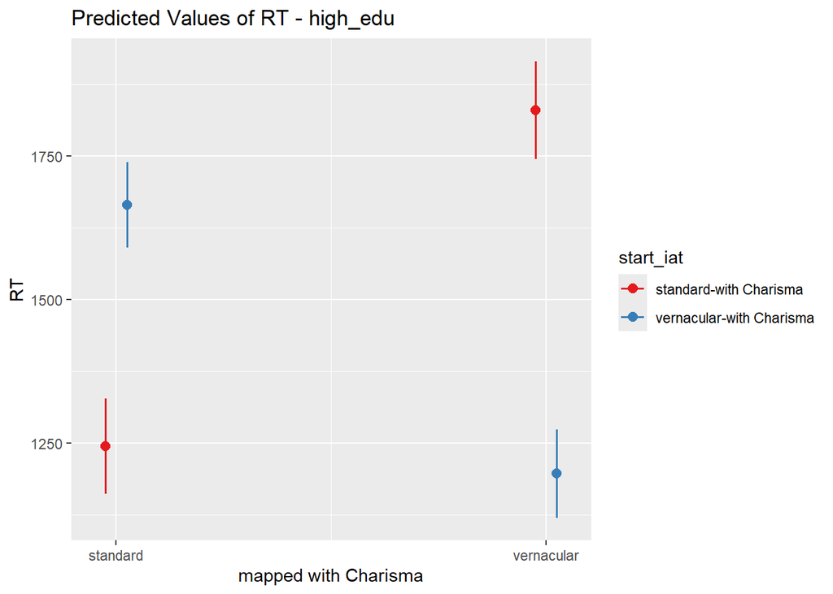

##### Subset: middle education convergence issues no impact of language variety, i.e. no difference in 2nd block

```
## boundary (singular) fit: see help('isSingular')
```

```
## Linear mixed model fit by REML. t-tests use Satterthwaite's method [
## lmerModLmerTest]
## Formula: penal_RTs ~ charisma_lang_var * start_iat + trialcount + age +
##     leadership_lang_var + stim_cat + (charisma_lang_var | bilendi_id) +
##     (start_iat | stimulus_ID)
##    Data: Four_Out_middle_edu
## Control: lmerControl(optimizer = "bobyqa", optCtrl = list(maxfun = 2e+05))
##
## REML criterion at convergence: 283003.6
##
## Scaled residuals:
##     Min      1Q  Median      3Q     Max
## -5.6364 -0.6379 -0.1039  0.5871 12.1213
##
## Random effects:
##  Groups      Name                              Variance Std.Dev. Corr
##  stimulus_ID (Intercept)                            0     0.0
##              start_iatvernacular-with Charisma  12318   111.0     NaN
##  bilendi_id  (Intercept)                       145797   381.8
##              charisma_lang_varvernacular       111171   333.4    0.01
##  Residual                                      305329   552.6
## Number of obs: 18223, groups:  stimulus_ID, 303; bilendi_id, 152
##
## Fixed effects:
##                                                                 Estimate
## (Intercept)                                                    1462.3846
## charisma_lang_varvernacular                                     495.9386
## start_iatvernacular-with Charisma                               497.5087
## trialcount                                                       -5.0524
## age                                                               5.3749
## leadership_lang_var2                                             98.1038
## stim_catleadership                                              148.8694
## charisma_lang_varvernacular:start_iatvernacular-with Charisma  -809.7669
##                                                               Std. Error
## (Intercept)                                                     126.1535
## charisma_lang_varvernacular                                      45.0720
## start_iatvernacular-with Charisma                                67.0723
## trialcount                                                        0.2371
## age                                                               2.1944
## leadership_lang_var2                                             64.6641
```

[output cut: 28 more lines]

```
## charisma_lang_varvernacular:start_iatvernacular-with Charisma ***
## ---
## Signif. codes:  0 '***' 0.001 '**' 0.01 '*' 0.05 '.' 0.1 ' ' 1
##
## Correlation of Fixed Effects:
##             (Intr) chrs__ str_-C trlcnt age    ldr__2 stm_ct
## chrsm_lng_v  0.055
## strt_tvrn-C -0.251  0.165
## trialcount  -0.132 -0.474 -0.318
## age         -0.902  0.000  0.066  0.000
## ldrshp_ln_2 -0.320  0.000  0.022  0.000  0.123
## stm_ctldrsh -0.039  0.001 -0.022 -0.003  0.000 -0.001
## chrsm__:_-C -0.075 -0.779 -0.211  0.602  0.000  0.000 -0.002
## optimizer (bobyqa) convergence code: 0 (OK)
## boundary (singular) fit: see help('isSingular')
```

```
## Type III Analysis of Variance Table with Satterthwaite's method
##                                Sum Sq   Mean Sq NumDF   DenDF  F value
## charisma_lang_var             3167829   3167829     1   149.8  10.3751
## start_iat                      551382    551382     1   149.6   1.8059
## trialcount                  138607501 138607501     1 17818.9 453.9607
## age                           1831728   1831728     1   148.0   5.9992
## leadership_lang_var            702770    702770     1   148.5   2.3017
## stim_cat                     69622265  69622265     1   824.4 228.0235
## charisma_lang_var:start_iat  39900849  39900849     1   368.2 130.6814
##                                Pr(>F)
## charisma_lang_var            0.001567 **
## start_iat                    0.181040
## trialcount                  < 2.2e-16 ***
## age                          0.015480 *
## leadership_lang_var          0.131360
## stim_cat                    < 2.2e-16 ***
## charisma_lang_var:start_iat < 2.2e-16 ***
## ---
## Signif. codes:  0 '***' 0.001 '**' 0.01 '*' 0.05 '.' 0.1 ' ' 1
```

```
## Note: D.f. calculations have been disabled because the number of observations exceeds 3000.
## To enable adjustments, add the argument 'pbkrtest.limit = 18223' (or larger)
## [or, globally, 'set emm_options(pbkrtest.limit = 18223)' or larger];
## but be warned that this may result in large computation time and memory use.
```

```
## Note: D.f. calculations have been disabled because the number of observations exceeds 3000.
## To enable adjustments, add the argument 'lmerTest.limit = 18223' (or larger)
## [or, globally, 'set emm_options(lmerTest.limit = 18223)' or larger];
## but be warned that this may result in large computation time and memory use.
```

```
## $emmeans
##  charisma_lang_var start_iat                emmean   SE  df asymp.LCL asymp.UCL
##  standard          standard-with Charisma     1268 45.9 Inf      1178      1358
##  vernacular        standard-with Charisma     1764 59.9 Inf      1646      1881
##  standard          vernacular-with Charisma   1765 47.2 Inf      1673      1858
##  vernacular        vernacular-with Charisma   1451 61.3 Inf      1331      1571
##
## Results are averaged over the levels of: leadership_lang_var, stim_cat
## Degrees-of-freedom method: asymptotic
## Confidence level used: 0.95
##
## $contrasts
##  contrast
##  (standard standard-with Charisma) - (vernacular standard-with Charisma)
##  (standard standard-with Charisma) - (standard vernacular-with Charisma)
##  (standard standard-with Charisma) - (vernacular vernacular-with Charisma)
##  (vernacular standard-with Charisma) - (standard vernacular-with Charisma)
##  (vernacular standard-with Charisma) - (vernacular vernacular-with Charisma)
##  (standard vernacular-with Charisma) - (vernacular vernacular-with Charisma)
##  estimate   SE  df z.ratio p.value
##   -495.94 45.1 Inf -11.003  <.0001
##   -497.51 67.1 Inf  -7.418  <.0001
##   -183.68 74.6 Inf  -2.461  0.0661
##     -1.57 74.4 Inf  -0.021  1.0000
##    312.26 86.7 Inf   3.603  0.0018
##    313.83 45.6 Inf   6.888  <.0001
##
## Results are averaged over the levels of: leadership_lang_var, stim_cat
## Degrees-of-freedom method: asymptotic
## P value adjustment: tukey method for comparing a family of 4 estimates
```

##### Subset: low education

```
## Linear mixed model fit by REML. t-tests use Satterthwaite's method [
## lmerModLmerTest]
## Formula: penal_RTs ~ charisma_lang_var * start_iat + trialcount + age +
##     leadership_lang_var + stim_cat + (charisma_lang_var | bilendi_id) +
##     (start_iat | stimulus_ID)
##    Data: Four_Out_low_edu
## Control: lmerControl(optimizer = "bobyqa", optCtrl = list(maxfun = 2e+05))
##
## REML criterion at convergence: 60287
##
## Scaled residuals:
##     Min      1Q  Median      3Q     Max
## -3.8023 -0.6564 -0.0805  0.6353 14.6289
##
## Random effects:
##  Groups      Name                              Variance Std.Dev. Corr
##  stimulus_ID (Intercept)                        21679   147.24
##              start_iatvernacular-with Charisma   6601    81.25   -0.90
##  bilendi_id  (Intercept)                        62653   250.31
##              charisma_lang_varvernacular        95953   309.76   -0.04
##  Residual                                      228382   477.89
## Number of obs: 3954, groups:  stimulus_ID, 300; bilendi_id, 33
##
## Fixed effects:
##                                                                 Estimate
## (Intercept)                                                    1941.1667
## charisma_lang_varvernacular                                     642.2933
## start_iatvernacular-with Charisma                               289.3519
## trialcount                                                       -5.0408
## age                                                              -1.9218
## leadership_lang_var2                                            -64.1764
## stim_catleadership                                              153.9444
## charisma_lang_varvernacular:start_iatvernacular-with Charisma -1005.9063
##                                                               Std. Error
## (Intercept)                                                     191.7270
## charisma_lang_varvernacular                                      98.0505
## start_iatvernacular-with Charisma                               110.2096
## trialcount                                                        0.4453
## age                                                               2.8420
## leadership_lang_var2                                            100.3513
```

[output cut: 26 more lines]

```
## leadership_lang_var2
## stim_catleadership                                            ***
## charisma_lang_varvernacular:start_iatvernacular-with Charisma ***
## ---
## Signif. codes:  0 '***' 0.001 '**' 0.01 '*' 0.05 '.' 0.1 ' ' 1
##
## Correlation of Fixed Effects:
##             (Intr) chrs__ str_-C trlcnt age    ldr__2 stm_ct
## chrsm_lng_v  0.038
## strt_tvrn-C -0.445  0.200
## trialcount  -0.164 -0.409 -0.365
## age         -0.905  0.000  0.309  0.001
## ldrshp_ln_2 -0.003  0.000 -0.293  0.000 -0.086
## stm_ctldrsh -0.067 -0.002  0.009  0.000  0.000 -0.004
## chrsm__:_-C -0.074 -0.817 -0.267  0.573  0.001  0.000  0.001
```

```
## Type III Analysis of Variance Table with Satterthwaite's method
##                               Sum Sq  Mean Sq NumDF  DenDF  F value    Pr(>F)
## charisma_lang_var            1344864  1344864     1   31.0   5.8887   0.02126
## start_iat                     805472   805472     1   31.0   3.5269   0.06981
## trialcount                  29266172 29266172     1 3818.8 128.1459 < 2.2e-16
## age                           104434   104434     1   29.0   0.4573   0.50426
## leadership_lang_var            93404    93404     1   29.2   0.4090   0.52748
## stim_cat                    12534996 12534996     1  216.1  54.8862 2.836e-12
## charisma_lang_var:start_iat 11777925 11777925     1   68.4  51.5712 6.505e-10
##
## charisma_lang_var           *
## start_iat                   .
## trialcount                  ***
## age
## leadership_lang_var
## stim_cat                    ***
## charisma_lang_var:start_iat ***
## ---
## Signif. codes:  0 '***' 0.001 '**' 0.01 '*' 0.05 '.' 0.1 ' ' 1
```

```
## Note: D.f. calculations have been disabled because the number of observations exceeds 3000.
## To enable adjustments, add the argument 'pbkrtest.limit = 3954' (or larger)
## [or, globally, 'set emm_options(pbkrtest.limit = 3954)' or larger];
## but be warned that this may result in large computation time and memory use.
```

```
## Note: D.f. calculations have been disabled because the number of observations exceeds 3000.
## To enable adjustments, add the argument 'lmerTest.limit = 3954' (or larger)
## [or, globally, 'set emm_options(lmerTest.limit = 3954)' or larger];
## but be warned that this may result in large computation time and memory use.
```

```
## $emmeans
##  charisma_lang_var start_iat                emmean    SE  df asymp.LCL
##  standard          standard-with Charisma     1298  85.5 Inf      1131
##  vernacular        standard-with Charisma     1941 119.3 Inf      1707
##  standard          vernacular-with Charisma   1588  62.7 Inf      1465
##  vernacular        vernacular-with Charisma   1224  91.8 Inf      1044
##  asymp.UCL
##       1466
##       2174
##       1711
##       1404
##
## Results are averaged over the levels of: leadership_lang_var, stim_cat
## Degrees-of-freedom method: asymptotic
## Confidence level used: 0.95
##
## $contrasts
##  contrast
##  (standard standard-with Charisma) - (vernacular standard-with Charisma)
##  (standard standard-with Charisma) - (standard vernacular-with Charisma)
##  (standard standard-with Charisma) - (vernacular vernacular-with Charisma)
##  (vernacular standard-with Charisma) - (standard vernacular-with Charisma)
##  (vernacular standard-with Charisma) - (vernacular vernacular-with Charisma)
##  (standard vernacular-with Charisma) - (vernacular vernacular-with Charisma)
##  estimate    SE  df z.ratio p.value
##    -642.3  98.1 Inf  -6.551  <.0001
##    -289.4 110.2 Inf  -2.625  0.0430
##      74.3 122.6 Inf   0.606  0.9303
##     352.9 132.1 Inf   2.672  0.0378
##     716.6 153.4 Inf   4.671  <.0001
##     363.6  82.4 Inf   4.413  0.0001
##
## Results are averaged over the levels of: leadership_lang_var, stim_cat
## Degrees-of-freedom method: asymptotic
## P value adjustment: tukey method for comparing a family of 4 estimates
```

##### Subset middle & low education

2nd block non-sig. difference

```
## Linear mixed model fit by REML. t-tests use Satterthwaite's method [
## lmerModLmerTest]
## Formula: penal_RTs ~ charisma_lang_var * start_iat + trialcount + age +
##     leadership_lang_var + stim_cat + (charisma_lang_var | bilendi_id) +
##     (start_iat | stimulus_ID)
##    Data: Four_Out_middle_low_edu
## Control: lmerControl(optimizer = "bobyqa", optCtrl = list(maxfun = 2e+05))
##
## REML criterion at convergence: 343262.7
##
## Scaled residuals:
##     Min      1Q  Median      3Q     Max
## -5.8012 -0.6297 -0.1037  0.5797 13.0225
##
## Random effects:
##  Groups      Name                              Variance Std.Dev. Corr
##  stimulus_ID (Intercept)                         9119    95.50
##              start_iatvernacular-with Charisma   3452    58.75   -0.20
##  bilendi_id  (Intercept)                       134239   366.39
##              charisma_lang_varvernacular       108441   329.30   0.01
##  Residual                                      288202   536.84
## Number of obs: 22177, groups:  stimulus_ID, 303; bilendi_id, 185
##
## Fixed effects:
##                                                                Estimate
## (Intercept)                                                    1562.666
## charisma_lang_varvernacular                                     515.844
## start_iatvernacular-with Charisma                               455.520
## trialcount                                                       -5.043
## age                                                               3.643
## leadership_lang_var2                                             62.301
## stim_catleadership                                              153.206
## charisma_lang_varvernacular:start_iatvernacular-with Charisma  -838.313
##                                                               Std. Error
## (Intercept)                                                      109.240
## charisma_lang_varvernacular                                       40.827
## start_iatvernacular-with Charisma                                 58.431
## trialcount                                                         0.209
## age                                                                1.840
## leadership_lang_var2                                              56.633
```

[output cut: 17 more lines]

```
## leadership_lang_var2                                            0.2727
## stim_catleadership                                             < 2e-16 ***
## charisma_lang_varvernacular:start_iatvernacular-with Charisma  < 2e-16 ***
## ---
## Signif. codes:  0 '***' 0.001 '**' 0.01 '*' 0.05 '.' 0.1 ' ' 1
##
## Correlation of Fixed Effects:
##             (Intr) chrs__ str_-C trlcnt age    ldr__2 stm_ct
## chrsm_lng_v  0.054
## strt_tvrn-C -0.279  0.163
## trialcount  -0.135 -0.461 -0.322
## age         -0.896  0.000  0.095  0.000
## ldrshp_ln_2 -0.289  0.000 -0.021  0.000  0.106
## stm_ctldrsh -0.091  0.001 -0.003 -0.001  0.000 -0.005
## chrsm__:_-C -0.075 -0.785 -0.210  0.597  0.000  0.000 -0.001
```

```
## Type III Analysis of Variance Table with Satterthwaite's method
##                                Sum Sq   Mean Sq NumDF   DenDF  F value
## charisma_lang_var             4214771   4214771     1   182.8  14.6244
## start_iat                      104898    104898     1   180.2   0.3640
## trialcount                  167833703 167833703     1 21616.5 582.3477
## age                           1129096   1129096     1   180.9   3.9177
## leadership_lang_var            348773    348773     1   183.3   1.2102
## stim_cat                     31351587  31351587     1   246.9 108.7834
## charisma_lang_var:start_iat  50992442  50992442     1   440.0 176.9331
##                                Pr(>F)
## charisma_lang_var           0.0001798 ***
## start_iat                   0.5470660
## trialcount                  < 2.2e-16 ***
## age                         0.0492963 *
## leadership_lang_var         0.2727415
## stim_cat                    < 2.2e-16 ***
## charisma_lang_var:start_iat < 2.2e-16 ***
## ---
## Signif. codes:  0 '***' 0.001 '**' 0.01 '*' 0.05 '.' 0.1 ' ' 1
```

```
## Note: D.f. calculations have been disabled because the number of observations exceeds 3000.
## To enable adjustments, add the argument 'pbkrtest.limit = 22177' (or larger)
## [or, globally, 'set emm_options(pbkrtest.limit = 22177)' or larger];
## but be warned that this may result in large computation time and memory use.
```

```
## Note: D.f. calculations have been disabled because the number of observations exceeds 3000.
## To enable adjustments, add the argument 'lmerTest.limit = 22177' (or larger)
## [or, globally, 'set emm_options(lmerTest.limit = 22177)' or larger];
## but be warned that this may result in large computation time and memory use.
```

```
## $emmeans
##  charisma_lang_var start_iat                emmean   SE  df asymp.LCL asymp.UCL
##  standard          standard-with Charisma     1271 41.6 Inf      1190      1353
##  vernacular        standard-with Charisma     1787 54.5 Inf      1680      1894
##  standard          vernacular-with Charisma   1727 40.5 Inf      1648      1806
##  vernacular        vernacular-with Charisma   1404 53.1 Inf      1300      1508
##
## Results are averaged over the levels of: leadership_lang_var, stim_cat
## Degrees-of-freedom method: asymptotic
## Confidence level used: 0.95
##
## $contrasts
##  contrast
##  (standard standard-with Charisma) - (vernacular standard-with Charisma)
##  (standard standard-with Charisma) - (standard vernacular-with Charisma)
##  (standard standard-with Charisma) - (vernacular vernacular-with Charisma)
##  (vernacular standard-with Charisma) - (standard vernacular-with Charisma)
##  (vernacular standard-with Charisma) - (vernacular vernacular-with Charisma)
##  (standard vernacular-with Charisma) - (vernacular vernacular-with Charisma)
##  estimate   SE  df z.ratio p.value
##    -515.8 40.8 Inf -12.635  <.0001
##    -455.5 58.4 Inf  -7.796  <.0001
##    -133.1 65.1 Inf  -2.043  0.1721
##      60.3 65.6 Inf   0.919  0.7945
##     382.8 76.4 Inf   5.010  <.0001
##     322.5 40.0 Inf   8.068  <.0001
##
## Results are averaged over the levels of: leadership_lang_var, stim_cat
## Degrees-of-freedom method: asymptotic
## P value adjustment: tukey method for comparing a family of 4 estimates
```

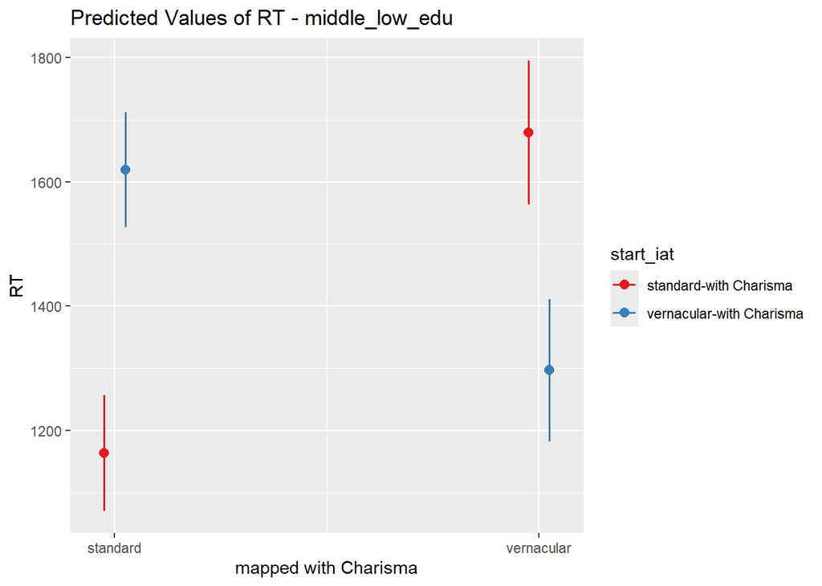

#### Focus sum training ##### Subset: high training no difference of 2nd blocks for no subsets

```
## boundary (singular) fit: see help('isSingular')
```

```
## Linear mixed model fit by REML. t-tests use Satterthwaite's method [
## lmerModLmerTest]
## Formula: penal_RTs ~ charisma_lang_var * start_iat + trialcount + age +
##     leadership_lang_var + stim_cat + (charisma_lang_var | bilendi_id) +
##     (start_iat | stimulus_ID)
##    Data: Four_Out_high_train
## Control: lmerControl(optimizer = "bobyqa", optCtrl = list(maxfun = 2e+05))
##
## REML criterion at convergence: 481904.7
##
## Scaled residuals:
##     Min      1Q  Median      3Q     Max
## -6.2125 -0.6238 -0.1344  0.5517 13.3664
##
## Random effects:
##  Groups      Name                              Variance Std.Dev. Corr
##  stimulus_ID (Intercept)                            0     0.00
##              start_iatvernacular-with Charisma   9647    98.22    NaN
##  bilendi_id  (Intercept)                       125008   353.56
##              charisma_lang_varvernacular       139173   373.06   -0.41
##  Residual                                      343013   585.67
## Number of obs: 30809, groups:  stimulus_ID, 303; bilendi_id, 257
##
## Fixed effects:
##                                                                 Estimate
## (Intercept)                                                    1586.7334
## charisma_lang_varvernacular                                     561.8938
## start_iatvernacular-with Charisma                               457.8610
## trialcount                                                       -5.8118
## age                                                               6.5078
## leadership_lang_var2                                             84.8654
## stim_catleadership                                              119.7413
## charisma_lang_varvernacular:start_iatvernacular-with Charisma  -997.7457
##                                                               Std. Error
## (Intercept)                                                      70.1489
## charisma_lang_varvernacular                                      40.4361
## start_iatvernacular-with Charisma                                49.3335
## trialcount                                                        0.1931
## age                                                               1.2380
## leadership_lang_var2                                             41.5536
```

[output cut: 28 more lines]

```
## charisma_lang_varvernacular:start_iatvernacular-with Charisma ***
## ---
## Signif. codes:  0 '***' 0.001 '**' 0.01 '*' 0.05 '.' 0.1 ' ' 1
##
## Correlation of Fixed Effects:
##             (Intr) chrs__ str_-C trlcnt age    ldr__2 stm_ct
## chrsm_lng_v -0.103
## strt_tvrn-C -0.253  0.417
## trialcount  -0.194 -0.430 -0.352
## age         -0.798  0.000 -0.048  0.000
## ldrshp_ln_2 -0.298  0.000  0.095  0.000  0.005
## stm_ctldrsh -0.061 -0.001 -0.031  0.002  0.000 -0.003
## chrsm__:_-C  0.013 -0.800 -0.524  0.580  0.000  0.000  0.001
## optimizer (bobyqa) convergence code: 0 (OK)
## boundary (singular) fit: see help('isSingular')
```

```
## Type III Analysis of Variance Table with Satterthwaite's method
##                                Sum Sq   Mean Sq NumDF   DenDF  F value
## charisma_lang_var             2289872   2289872     1   254.8   6.6758
## start_iat                      323879    323879     1   263.9   0.9442
## trialcount                  310652432 310652432     1 30171.6 905.6577
## age                           9478649   9478649     1   253.1  27.6335
## leadership_lang_var           1430717   1430717     1   255.1   4.1710
## stim_cat                     67557099  67557099     1  2006.5 196.9520
## charisma_lang_var:start_iat  95161264  95161264     1   578.0 277.4275
##                                Pr(>F)
## charisma_lang_var             0.01033 *
## start_iat                     0.33209
## trialcount                  < 2.2e-16 ***
## age                         3.118e-07 ***
## leadership_lang_var           0.04215 *
## stim_cat                    < 2.2e-16 ***
## charisma_lang_var:start_iat < 2.2e-16 ***
## ---
## Signif. codes:  0 '***' 0.001 '**' 0.01 '*' 0.05 '.' 0.1 ' ' 1
```

```
## Note: D.f. calculations have been disabled because the number of observations exceeds 3000.
## To enable adjustments, add the argument 'pbkrtest.limit = 30809' (or larger)
## [or, globally, 'set emm_options(pbkrtest.limit = 30809)' or larger];
## but be warned that this may result in large computation time and memory use.
```

```
## Note: D.f. calculations have been disabled because the number of observations exceeds 3000.
## To enable adjustments, add the argument 'lmerTest.limit = 30809' (or larger)
## [or, globally, 'set emm_options(lmerTest.limit = 30809)' or larger];
## but be warned that this may result in large computation time and memory use.
```

```
## $emmeans
##  charisma_lang_var start_iat                emmean   SE  df asymp.LCL asymp.UCL
##  standard          standard-with Charisma     1319 35.1 Inf      1250      1388
##  vernacular        standard-with Charisma     1881 38.8 Inf      1805      1957
##  standard          vernacular-with Charisma   1777 32.4 Inf      1713      1840
##  vernacular        vernacular-with Charisma   1341 35.5 Inf      1271      1410
##
## Results are averaged over the levels of: leadership_lang_var, stim_cat
## Degrees-of-freedom method: asymptotic
## Confidence level used: 0.95
##
## $contrasts
##  contrast
##  (standard standard-with Charisma) - (vernacular standard-with Charisma)
##  (standard standard-with Charisma) - (standard vernacular-with Charisma)
##  (standard standard-with Charisma) - (vernacular vernacular-with Charisma)
##  (vernacular standard-with Charisma) - (standard vernacular-with Charisma)
##  (vernacular standard-with Charisma) - (vernacular vernacular-with Charisma)
##  (standard vernacular-with Charisma) - (vernacular vernacular-with Charisma)
##  estimate   SE  df z.ratio p.value
##      -562 40.4 Inf -13.896  <.0001
##      -458 49.3 Inf  -9.281  <.0001
##       -22 48.4 Inf  -0.454  0.9688
##       104 49.0 Inf   2.121  0.1464
##       540 54.1 Inf   9.986  <.0001
##       436 36.7 Inf  11.867  <.0001
##
## Results are averaged over the levels of: leadership_lang_var, stim_cat
## Degrees-of-freedom method: asymptotic
## P value adjustment: tukey method for comparing a family of 4 estimates
```

##### Subset: middle training

```
## boundary (singular) fit: see help('isSingular')
```

```
## Linear mixed model fit by REML. t-tests use Satterthwaite's method [
## lmerModLmerTest]
## Formula: penal_RTs ~ charisma_lang_var * start_iat + trialcount + age +
##     leadership_lang_var + stim_cat + (charisma_lang_var | bilendi_id) +
##     (start_iat | stimulus_ID)
##    Data: Four_Out_middle_train
## Control: lmerControl(optimizer = "bobyqa", optCtrl = list(maxfun = 2e+05))
##
## REML criterion at convergence: 315078.8
##
## Scaled residuals:
##     Min      1Q  Median      3Q     Max
## -6.3795 -0.6377 -0.1180  0.5831 12.5784
##
## Random effects:
##  Groups      Name                              Variance Std.Dev. Corr
##  stimulus_ID (Intercept)                            0     0.00
##              start_iatvernacular-with Charisma   9871    99.35    NaN
##  bilendi_id  (Intercept)                       233566   483.29
##              charisma_lang_varvernacular        83515   288.99   -0.07
##  Residual                                      313228   559.67
## Number of obs: 20256, groups:  stimulus_ID, 303; bilendi_id, 169
##
## Fixed effects:
##                                                                 Estimate
## (Intercept)                                                    1894.6312
## charisma_lang_varvernacular                                     567.5688
## start_iatvernacular-with Charisma                               416.6993
## trialcount                                                       -6.0316
## age                                                               0.8176
## leadership_lang_var2                                             11.3052
## stim_catleadership                                              142.1488
## charisma_lang_varvernacular:start_iatvernacular-with Charisma  -957.1033
##                                                               Std. Error
## (Intercept)                                                     148.0934
## charisma_lang_varvernacular                                      38.7291
## start_iatvernacular-with Charisma                                78.4015
## trialcount                                                        0.2276
## age                                                               2.6245
## leadership_lang_var2                                             76.8719
```

[output cut: 28 more lines]

```
## charisma_lang_varvernacular:start_iatvernacular-with Charisma ***
## ---
## Signif. codes:  0 '***' 0.001 '**' 0.01 '*' 0.05 '.' 0.1 ' ' 1
##
## Correlation of Fixed Effects:
##             (Intr) chrs__ str_-C trlcnt age    ldr__2 stm_ct
## chrsm_lng_v  0.027
## strt_tvrn-C -0.230  0.195
## trialcount  -0.108 -0.529 -0.261
## age         -0.908  0.000  0.037  0.000
## ldrshp_ln_2 -0.306  0.000 -0.053  0.000  0.123
## stm_ctldrsh -0.031  0.002 -0.016 -0.004  0.000 -0.001
## chrsm__:_-C -0.052 -0.793 -0.244  0.656  0.000  0.000 -0.002
## optimizer (bobyqa) convergence code: 0 (OK)
## boundary (singular) fit: see help('isSingular')
```

```
## Type III Analysis of Variance Table with Satterthwaite's method
##                                Sum Sq   Mean Sq NumDF   DenDF  F value
## charisma_lang_var             4455983   4455983     1   166.7  14.2260
## start_iat                      202135    202135     1   167.0   0.6453
## trialcount                  219943366 219943366     1 19808.6 702.1826
## age                             30397     30397     1   165.0   0.0970
## leadership_lang_var              6775      6775     1   165.4   0.0216
## stim_cat                     72989998  72989998     1   347.2 233.0250
## charisma_lang_var:start_iat  73439650  73439650     1   510.2 234.4606
##                                Pr(>F)
## charisma_lang_var           0.0002249 ***
## start_iat                   0.4229297
## trialcount                  < 2.2e-16 ***
## age                         0.7557989
## leadership_lang_var         0.8832598
## stim_cat                    < 2.2e-16 ***
## charisma_lang_var:start_iat < 2.2e-16 ***
## ---
## Signif. codes:  0 '***' 0.001 '**' 0.01 '*' 0.05 '.' 0.1 ' ' 1
```

```
## Note: D.f. calculations have been disabled because the number of observations exceeds 3000.
## To enable adjustments, add the argument 'pbkrtest.limit = 20256' (or larger)
## [or, globally, 'set emm_options(pbkrtest.limit = 20256)' or larger];
## but be warned that this may result in large computation time and memory use.
```

```
## Note: D.f. calculations have been disabled because the number of observations exceeds 3000.
## To enable adjustments, add the argument 'lmerTest.limit = 20256' (or larger)
## [or, globally, 'set emm_options(lmerTest.limit = 20256)' or larger];
## but be warned that this may result in large computation time and memory use.
```

```
## $emmeans
##  charisma_lang_var start_iat                emmean   SE  df asymp.LCL asymp.UCL
##  standard          standard-with Charisma     1315 54.2 Inf      1209      1421
##  vernacular        standard-with Charisma     1883 60.6 Inf      1764      2001
##  standard          vernacular-with Charisma   1732 55.5 Inf      1623      1841
##  vernacular        vernacular-with Charisma   1342 62.2 Inf      1220      1464
##
## Results are averaged over the levels of: leadership_lang_var, stim_cat
## Degrees-of-freedom method: asymptotic
## Confidence level used: 0.95
##
## $contrasts
##  contrast
##  (standard standard-with Charisma) - (vernacular standard-with Charisma)
##  (standard standard-with Charisma) - (standard vernacular-with Charisma)
##  (standard standard-with Charisma) - (vernacular vernacular-with Charisma)
##  (vernacular standard-with Charisma) - (standard vernacular-with Charisma)
##  (vernacular standard-with Charisma) - (vernacular vernacular-with Charisma)
##  (standard vernacular-with Charisma) - (vernacular vernacular-with Charisma)
##  estimate   SE  df z.ratio p.value
##    -567.6 38.7 Inf -14.655  <.0001
##    -416.7 78.4 Inf  -5.315  <.0001
##     -27.2 80.7 Inf  -0.337  0.9869
##     150.9 80.4 Inf   1.877  0.2381
##     540.4 87.5 Inf   6.173  <.0001
##     389.5 39.6 Inf   9.838  <.0001
##
## Results are averaged over the levels of: leadership_lang_var, stim_cat
## Degrees-of-freedom method: asymptotic
## P value adjustment: tukey method for comparing a family of 4 estimates
```

##### Subset: low training summary variable

```
## boundary (singular) fit: see help('isSingular')
```

```
## Linear mixed model fit by REML. t-tests use Satterthwaite's method [
## lmerModLmerTest]
## Formula: penal_RTs ~ charisma_lang_var * start_iat + trialcount + age +
##     leadership_lang_var + stim_cat + (charisma_lang_var | bilendi_id) +
##     (start_iat | stimulus_ID)
##    Data: Four_Out_low_train
## Control: lmerControl(optimizer = "bobyqa", optCtrl = list(maxfun = 2e+05))
##
## REML criterion at convergence: 205762
##
## Scaled residuals:
##     Min      1Q  Median      3Q     Max
## -4.2917 -0.6124 -0.0931  0.5609 11.8843
##
## Random effects:
##  Groups      Name                              Variance Std.Dev. Corr
##  stimulus_ID (Intercept)                            0     0.00
##              start_iatvernacular-with Charisma   9574    97.85    NaN
##  bilendi_id  (Intercept)                       153802   392.18
##              charisma_lang_varvernacular        96059   309.93   -0.10
##  Residual                                      332694   576.80
## Number of obs: 13180, groups:  stimulus_ID, 303; bilendi_id, 110
##
## Fixed effects:
##                                                                 Estimate
## (Intercept)                                                    1648.7360
## charisma_lang_varvernacular                                     553.6844
## start_iatvernacular-with Charisma                               419.5189
## trialcount                                                       -5.3542
## age                                                               4.4212
## leadership_lang_var2                                             68.1833
## stim_catleadership                                              131.7601
## charisma_lang_varvernacular:start_iatvernacular-with Charisma  -968.9904
##                                                               Std. Error
## (Intercept)                                                     113.7251
## charisma_lang_varvernacular                                      54.4734
## start_iatvernacular-with Charisma                                82.2370
## trialcount                                                        0.2913
## age                                                               2.1292
## leadership_lang_var2                                             76.3320
```

[output cut: 28 more lines]

```
## charisma_lang_varvernacular:start_iatvernacular-with Charisma ***
## ---
## Signif. codes:  0 '***' 0.001 '**' 0.01 '*' 0.05 '.' 0.1 ' ' 1
##
## Correlation of Fixed Effects:
##             (Intr) chrs__ str_-C trlcnt age    ldr__2 stm_ct
## chrsm_lng_v  0.026
## strt_tvrn-C -0.385  0.238
## trialcount  -0.180 -0.481 -0.318
## age         -0.793  0.000  0.119  0.000
## ldrshp_ln_2 -0.230  0.000 -0.058  0.000 -0.051
## stm_ctldrsh -0.052  0.001 -0.017 -0.003  0.000  0.000
## chrsm__:_-C -0.075 -0.818 -0.302  0.639  0.000  0.000 -0.002
## optimizer (bobyqa) convergence code: 0 (OK)
## boundary (singular) fit: see help('isSingular')
```

```
## Type III Analysis of Variance Table with Satterthwaite's method
##                                Sum Sq   Mean Sq NumDF   DenDF  F value  Pr(>F)
## charisma_lang_var             1599150   1599150     1   108.0   4.8067 0.03050
## start_iat                      219085    219085     1   106.9   0.6585 0.41889
## trialcount                  112432681 112432681     1 12884.2 337.9467 < 2e-16
## age                           1434467   1434467     1   105.9   4.3117 0.04027
## leadership_lang_var            265452    265452     1   106.2   0.7979 0.37375
## stim_cat                     40620131  40620131     1   319.3 122.0947 < 2e-16
## charisma_lang_var:start_iat  46406604  46406604     1   307.1 139.4875 < 2e-16
##
## charisma_lang_var           *
## start_iat
## trialcount                  ***
## age                         *
## leadership_lang_var
## stim_cat                    ***
## charisma_lang_var:start_iat ***
## ---
## Signif. codes:  0 '***' 0.001 '**' 0.01 '*' 0.05 '.' 0.1 ' ' 1
```

```
## Note: D.f. calculations have been disabled because the number of observations exceeds 3000.
## To enable adjustments, add the argument 'pbkrtest.limit = 13180' (or larger)
## [or, globally, 'set emm_options(pbkrtest.limit = 13180)' or larger];
## but be warned that this may result in large computation time and memory use.
```

```
## Note: D.f. calculations have been disabled because the number of observations exceeds 3000.
## To enable adjustments, add the argument 'lmerTest.limit = 13180' (or larger)
## [or, globally, 'set emm_options(lmerTest.limit = 13180)' or larger];
## but be warned that this may result in large computation time and memory use.
```

```
## $emmeans
##  charisma_lang_var start_iat                emmean   SE  df asymp.LCL asymp.UCL
##  standard          standard-with Charisma     1310 60.4 Inf      1191      1428
##  vernacular        standard-with Charisma     1863 71.9 Inf      1722      2004
##  standard          vernacular-with Charisma   1729 52.6 Inf      1626      1832
##  vernacular        vernacular-with Charisma   1314 62.5 Inf      1191      1436
##
## Results are averaged over the levels of: leadership_lang_var, stim_cat
## Degrees-of-freedom method: asymptotic
## Confidence level used: 0.95
##
## $contrasts
##  contrast
##  (standard standard-with Charisma) - (vernacular standard-with Charisma)
##  (standard standard-with Charisma) - (standard vernacular-with Charisma)
##  (standard standard-with Charisma) - (vernacular vernacular-with Charisma)
##  (vernacular standard-with Charisma) - (standard vernacular-with Charisma)
##  (vernacular standard-with Charisma) - (vernacular vernacular-with Charisma)
##  (standard vernacular-with Charisma) - (vernacular vernacular-with Charisma)
##  estimate   SE  df z.ratio p.value
##   -553.68 54.5 Inf -10.164  <.0001
##   -419.52 82.2 Inf  -5.101  <.0001
##     -4.21 84.9 Inf  -0.050  1.0000
##    134.17 87.2 Inf   1.539  0.4141
##    549.47 97.1 Inf   5.660  <.0001
##    415.31 48.9 Inf   8.495  <.0001
##
## Results are averaged over the levels of: leadership_lang_var, stim_cat
## Degrees-of-freedom method: asymptotic
## P value adjustment: tukey method for comparing a family of 4 estimates
```

##### Subset: middle & low training

```
## Linear mixed model fit by REML. t-tests use Satterthwaite's method [
## lmerModLmerTest]
## Formula: penal_RTs ~ charisma_lang_var * start_iat + trialcount + age +
##     leadership_lang_var + stim_cat + (charisma_lang_var | bilendi_id) +
##     (start_iat | stimulus_ID)
##    Data: Four_Out_middle_low_train
## Control: lmerControl(optimizer = "bobyqa", optCtrl = list(maxfun = 2e+05))
##
## REML criterion at convergence: 520526.4
##
## Scaled residuals:
##     Min      1Q  Median      3Q     Max
## -6.1195 -0.6222 -0.1084  0.5615 12.4420
##
## Random effects:
##  Groups      Name                              Variance Std.Dev. Corr
##  stimulus_ID (Intercept)                         8957.2  94.64
##              start_iatvernacular-with Charisma    557.6  23.61   -0.38
##  bilendi_id  (Intercept)                       200255.0 447.50
##              charisma_lang_varvernacular        88891.1 298.15   -0.08
##  Residual                                      316575.6 562.65
## Number of obs: 33436, groups:  stimulus_ID, 303; bilendi_id, 279
##
## Fixed effects:
##                                                                 Estimate
## (Intercept)                                                    1764.6874
## charisma_lang_varvernacular                                     557.2030
## start_iatvernacular-with Charisma                               412.8259
## trialcount                                                       -5.7330
## age                                                               2.5782
## leadership_lang_var2                                             41.4633
## stim_catleadership                                              145.3495
## charisma_lang_varvernacular:start_iatvernacular-with Charisma  -957.2347
##                                                               Std. Error
## (Intercept)                                                      92.8456
## charisma_lang_varvernacular                                      31.6189
## start_iatvernacular-with Charisma                                57.0102
## trialcount                                                        0.1781
## age                                                               1.6552
## leadership_lang_var2                                             55.0092
```

[output cut: 26 more lines]

```
## leadership_lang_var2
## stim_catleadership                                            ***
## charisma_lang_varvernacular:start_iatvernacular-with Charisma ***
## ---
## Signif. codes:  0 '***' 0.001 '**' 0.01 '*' 0.05 '.' 0.1 ' ' 1
##
## Correlation of Fixed Effects:
##             (Intr) chrs__ str_-C trlcnt age    ldr__2 stm_ct
## chrsm_lng_v  0.029
## strt_tvrn-C -0.319  0.207
## trialcount  -0.135 -0.507 -0.281
## age         -0.858  0.000  0.092  0.000
## ldrshp_ln_2 -0.272  0.000 -0.053  0.000  0.049
## stm_ctldrsh -0.105  0.001  0.004 -0.001  0.000 -0.003
## chrsm__:_-C -0.062 -0.802 -0.261  0.647  0.000  0.000 -0.001
```

```
## Type III Analysis of Variance Table with Satterthwaite's method
##                                Sum Sq   Mean Sq NumDF DenDF   F value    Pr(>F)
## charisma_lang_var             5471845   5471845     1   277   17.2845 4.296e-05
## start_iat                      438250    438250     1   275    1.3843    0.2404
## trialcount                  328124921 328124921     1 32681 1036.4819 < 2.2e-16
## age                            768051    768051     1   275    2.4261    0.1205
## leadership_lang_var            179860    179860     1   278    0.5681    0.4516
## stim_cat                     35538894  35538894     1   249  112.2604 < 2.2e-16
## charisma_lang_var:start_iat 118082614 118082614     1   814  372.9997 < 2.2e-16
##
## charisma_lang_var           ***
## start_iat
## trialcount                  ***
## age
## leadership_lang_var
## stim_cat                    ***
## charisma_lang_var:start_iat ***
## ---
## Signif. codes:  0 '***' 0.001 '**' 0.01 '*' 0.05 '.' 0.1 ' ' 1
```

```
## Note: D.f. calculations have been disabled because the number of observations exceeds 3000.
## To enable adjustments, add the argument 'pbkrtest.limit = 33436' (or larger)
## [or, globally, 'set emm_options(pbkrtest.limit = 33436)' or larger];
## but be warned that this may result in large computation time and memory use.
```

```
## Note: D.f. calculations have been disabled because the number of observations exceeds 3000.
## To enable adjustments, add the argument 'lmerTest.limit = 33436' (or larger)
## [or, globally, 'set emm_options(lmerTest.limit = 33436)' or larger];
## but be warned that this may result in large computation time and memory use.
```

```
## $emmeans
##  charisma_lang_var start_iat                emmean   SE  df asymp.LCL asymp.UCL
##  standard          standard-with Charisma     1314 41.0 Inf      1234      1395
##  vernacular        standard-with Charisma     1871 46.8 Inf      1780      1963
##  standard          vernacular-with Charisma   1727 39.2 Inf      1650      1804
##  vernacular        vernacular-with Charisma   1327 44.8 Inf      1239      1415
##
## Results are averaged over the levels of: leadership_lang_var, stim_cat
## Degrees-of-freedom method: asymptotic
## Confidence level used: 0.95
##
## $contrasts
##  contrast
##  (standard standard-with Charisma) - (vernacular standard-with Charisma)
##  (standard standard-with Charisma) - (standard vernacular-with Charisma)
##  (standard standard-with Charisma) - (vernacular vernacular-with Charisma)
##  (vernacular standard-with Charisma) - (standard vernacular-with Charisma)
##  (vernacular standard-with Charisma) - (vernacular vernacular-with Charisma)
##  (standard vernacular-with Charisma) - (vernacular vernacular-with Charisma)
##  estimate   SE  df z.ratio p.value
##    -557.2 31.6 Inf -17.622  <.0001
##    -412.8 57.0 Inf  -7.241  <.0001
##     -12.8 58.9 Inf  -0.217  0.9964
##     144.4 59.2 Inf   2.439  0.0699
##     544.4 65.1 Inf   8.369  <.0001
##     400.0 30.7 Inf  13.026  <.0001
##
## Results are averaged over the levels of: leadership_lang_var, stim_cat
## Degrees-of-freedom method: asymptotic
## P value adjustment: tukey method for comparing a family of 4 estimates
```

## 3.6. SES & Populism

### all data

Impact of language variety in high education subset might be due to correlation of education with populism. -> sum_education/ sum_training positive slopes: the lower educated the higher populism scores, biggest difference between high and middle educated -> income less clear pattern

```
##  [1] "Bundesfreiwilligendienst, Freiwilliges Soziales Jahr (FSJ), Freiwilliges Ökologisches Jahr (FÖJ)"
##  [2] "geringfügig erwerbstätig, 450-Euro-Job, Minijob"
##  [3] "in Mutterschutz, Elternzeit"
##  [4] "Lehrling/Azubi"
##  [5] "nicht berufstätig (Hausfrau/Hausmann)"
##  [6] "Pensionär/in, Rentner/in (früher berufstätig)"
##  [7] "Schüler/in"
##  [8] "Student/in"
##  [9] "Teilzeit berufstätig (bis 30 Stunden/Woche)"
## [10] "Vollzeit berufstätig (mehr als 30 Stunden/Woche)"
## [11] "zurzeit arbeitslos"
```

```
##  [1] "1000 bis unter 1250 Euro"       "10000 Euro und mehr"
##  [3] "1250 bis unter 1500 Euro"       "1500 bis unter 2000 Euro"
##  [5] "2000 bis unter 2500 Euro"       "2500 bis unter 3000 Euro"
##  [7] "3000 bis unter 4000 Euro"       "4000 bis unter 5000 Euro"
##  [9] "500 bis unter 750 Euro"         "5000 bis unter 7500 Euro"
## [11] "750 bis unter 1000 Euro"        "7500 bis unter 10000 Euro"
## [13] "möchte Frage nicht beantworten" "unter 500 Euro"
## [15] "weiß nicht"
```

```
##
## Call:
## lm(formula = populism_all ~ sum_education + sum_training + employment_status +
##     monthly_income, data = Four_Out)
##
## Residuals:
##      Min       1Q   Median       3Q      Max
## -2.91412 -0.61819  0.06176  0.61288  2.36576
##
## Coefficients:
##                                                                                                                    Estimate
## (Intercept)                                                                                                        0.175841
## sum_educationlow                                                                                                   0.340368
## sum_educationmiddle                                                                                                0.398038
## sum_educationother                                                                                                 1.173134
## sum_educationstill at school                                                                                      -0.646486
## sum_traininghigh                                                                                                  -0.171047
## sum_traininglow                                                                                                   -0.034453
## employment_statusBundesfreiwilligendienst, Freiwilliges Soziales Jahr (FSJ), Freiwilliges Ökologisches Jahr (FÖJ) -1.158912
## employment_statusgeringfügig erwerbstätig, 450-Euro-Job, Minijob                                                  -0.509327
## employment_statusin Mutterschutz, Elternzeit                                                                       0.807036
## employment_statusLehrling/Azubi                                                                                   -0.639005
## employment_statusnicht berufstätig (Hausfrau/Hausmann)                                                            -0.540983
## employment_statusPensionär/in, Rentner/in (früher berufstätig)                                                    -0.153425
## employment_statusSchüler/in                                                                                        0.459813
## employment_statusStudent/in                                                                                        0.006661
## employment_statusTeilzeit berufstätig (bis 30 Stunden/Woche)                                                      -0.141926
## employment_statuszurzeit arbeitslos                                                                               -0.101383
## monthly_income1000 bis unter 1250 Euro                                                                             0.008589
## monthly_income10000 Euro und mehr                                                                                 -0.616642
## monthly_income1250 bis unter 1500 Euro                                                                            -0.048711
## monthly_income1500 bis unter 2000 Euro                                                                            -0.168825
## monthly_income2000 bis unter 2500 Euro                                                                            -0.139390
## monthly_income2500 bis unter 3000 Euro                                                                            -0.117333
## monthly_income3000 bis unter 4000 Euro                                                                            -0.192401
## monthly_income4000 bis unter 5000 Euro                                                                            -0.087493
## monthly_income500 bis unter 750 Euro                                                                               0.041760
## monthly_income5000 bis unter 7500 Euro                                                                            -0.379129
## monthly_income750 bis unter 1000 Euro                                                                             -0.109904
## monthly_income7500 bis unter 10000 Euro                                                                           -0.022476
```

[output cut: 122 more lines]

```
## monthly_income3000 bis unter 4000 Euro                                                                            ***
## monthly_income4000 bis unter 5000 Euro                                                                            **
## monthly_income500 bis unter 750 Euro
## monthly_income5000 bis unter 7500 Euro                                                                            ***
## monthly_income750 bis unter 1000 Euro                                                                             **
## monthly_income7500 bis unter 10000 Euro
## monthly_incomemöchte Frage nicht beantworten                                                                      *
## monthly_incomeweiß nicht                                                                                          ***
## ---
## Signif. codes:  0 '***' 0.001 '**' 0.01 '*' 0.05 '.' 0.1 ' ' 1
##
## Residual standard error: 0.947 on 64214 degrees of freedom
##   (120 Beobachtungen als fehlend gelöscht)
## Multiple R-squared:  0.09445,    Adjusted R-squared:  0.09403
## F-statistic: 223.2 on 30 and 64214 DF,  p-value: < 2.2e-16
```

```
## Analysis of Variance Table
##
## Response: populism_all
##                      Df Sum Sq Mean Sq F value    Pr(>F)
## sum_education         4   3337  834.37 930.468 < 2.2e-16 ***
## sum_training          2    376  187.93 209.577 < 2.2e-16 ***
## employment_status    10   1393  139.34 155.387 < 2.2e-16 ***
## monthly_income       14    899   64.22  71.614 < 2.2e-16 ***
## Residuals         64214  57582    0.90
## ---
## Signif. codes:  0 '***' 0.001 '**' 0.01 '*' 0.05 '.' 0.1 ' ' 1
```

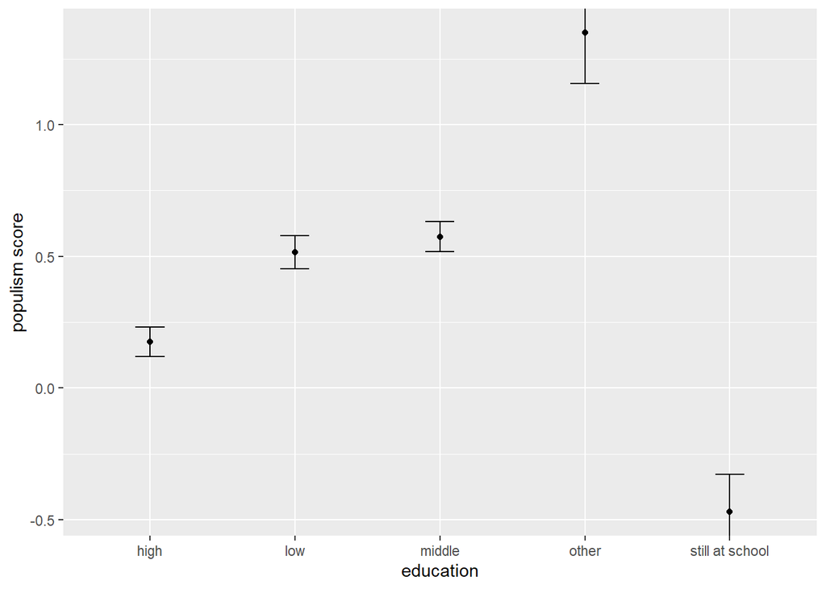

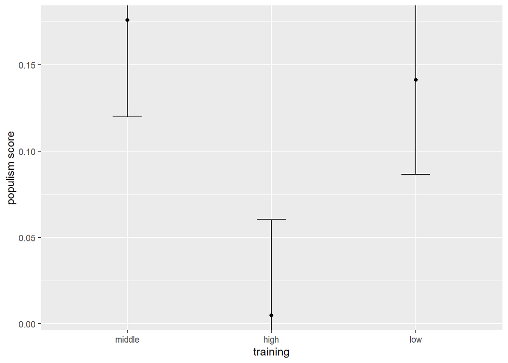

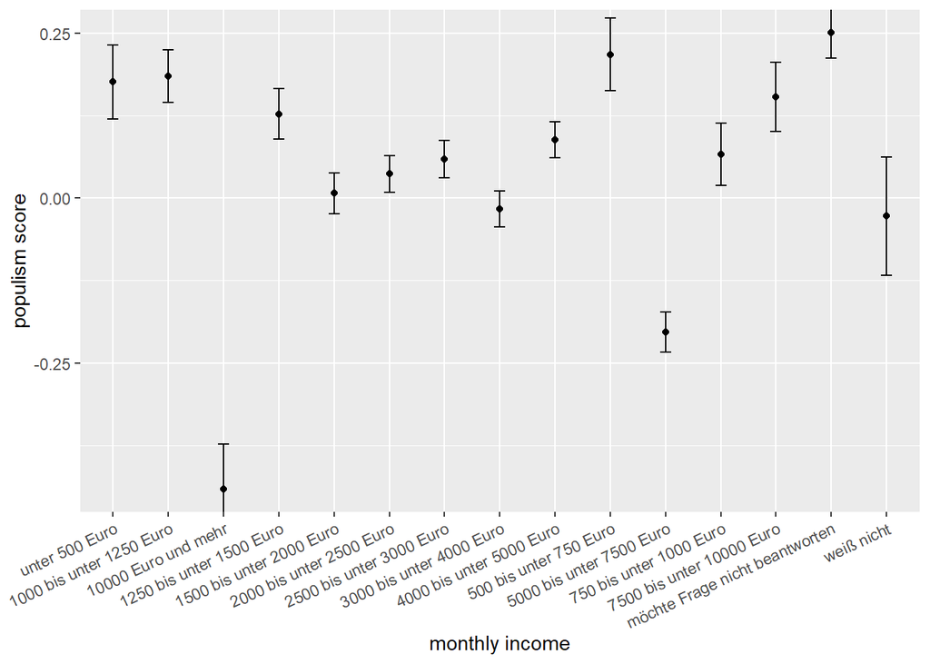

## 3.7. MC Social Desirebility SCale Interaction charisma_lang_var standard:start_iat standard-with Charisma:score_MCSD sig. and negative => the stronger the socially desirable behaviour the stronger the association of standard & charisma (standard language ideology?)

```
## Linear mixed model fit by REML. t-tests use Satterthwaite's method [
## lmerModLmerTest]
## Formula: penal_RTs ~ charisma_lang_var:start_iat:score_MCSD + trialcount +
##     age + leadership_lang_var + stim_cat + (charisma_lang_var |
##     bilendi_id) + (1 | stimulus_ID)
##    Data: Four_Out
## Control: lmerControl(optimizer = "bobyqa", optCtrl = list(maxfun = 2e+05))
##
## REML criterion at convergence: 154185.8
##
## Scaled residuals:
##     Min      1Q  Median      3Q     Max
## -6.4072 -0.6194 -0.1248  0.5484 13.4635
##
## Random effects:
##  Groups      Name                        Variance Std.Dev. Corr
##  bilendi_id  (Intercept)                 0.34934  0.5911
##              charisma_lang_varvernacular 0.47308  0.6878   -0.43
##  stimulus_ID (Intercept)                 0.01504  0.1226
##  Residual                                0.59945  0.7742
## Number of obs: 64365, groups:  bilendi_id, 537; stimulus_ID, 303
##
## Fixed effects:
##                                                                            Estimate
## (Intercept)                                                               5.892e-01
## trialcount                                                               -6.250e-03
## age                                                                       1.133e-01
## leadership_lang_var2                                                      8.355e-02
## stim_catleadership                                                        1.826e-01
## charisma_lang_varstandard:start_iatstandard-with Charisma:score_MCSD     -7.732e-02
## charisma_lang_varvernacular:start_iatstandard-with Charisma:score_MCSD    5.457e-02
## charisma_lang_varstandard:start_iatvernacular-with Charisma:score_MCSD   -1.669e-02
## charisma_lang_varvernacular:start_iatvernacular-with Charisma:score_MCSD  2.543e-02
##                                                                          Std. Error
## (Intercept)                                                               3.886e-02
## trialcount                                                                1.560e-04
## age                                                                       2.420e-02
## leadership_lang_var2                                                      4.748e-02
## stim_catleadership                                                        1.768e-02
## charisma_lang_varstandard:start_iatstandard-with Charisma:score_MCSD      3.885e-02
```

[output cut: 68 more lines]

```
## ldrshp_ln_2
## stm_ctldrsh
## chrsm_lng_vrstndrd:strt_ts-C:_MCSD
## chrsm_lng_vrvrnclr:strt_ts-C:_MCSD
## chrsm_lng_vrstndrd:strt_tv-C:_MCSD  0.023
## chrsm_lng_vrvrnclr:strt_tv-C:_MCSD  0.020
##                                    chrsm_lng_vrstndrd:strt_tv-C:_MCSD
## trialcount
## age
## ldrshp_ln_2
## stm_ctldrsh
## chrsm_lng_vrstndrd:strt_ts-C:_MCSD
## chrsm_lng_vrvrnclr:strt_ts-C:_MCSD
## chrsm_lng_vrstndrd:strt_tv-C:_MCSD
## chrsm_lng_vrvrnclr:strt_tv-C:_MCSD  0.433
```

```
## Type III Analysis of Variance Table with Satterthwaite's method
##                                        Sum Sq Mean Sq NumDF  DenDF   F value
## trialcount                             962.17  962.17     1 8051.8 1605.0796
## age                                     13.13   13.13     1  531.8   21.9023
## leadership_lang_var                      1.86    1.86     1  541.7    3.0970
## stim_cat                                63.97   63.97     1  263.4  106.7176
## charisma_lang_var:start_iat:score_MCSD   6.30    1.57     4  468.2    2.6259
##                                           Pr(>F)
## trialcount                             < 2.2e-16 ***
## age                                    3.645e-06 ***
## leadership_lang_var                      0.07900 .
## stim_cat                               < 2.2e-16 ***
## charisma_lang_var:start_iat:score_MCSD   0.03406 *
## ---
## Signif. codes:  0 '***' 0.001 '**' 0.01 '*' 0.05 '.' 0.1 ' ' 1
```

```
## Note: D.f. calculations have been disabled because the number of observations exceeds 3000.
## To enable adjustments, add the argument 'pbkrtest.limit = 64365' (or larger)
## [or, globally, 'set emm_options(pbkrtest.limit = 64365)' or larger];
## but be warned that this may result in large computation time and memory use.
```

```
## Note: D.f. calculations have been disabled because the number of observations exceeds 3000.
## To enable adjustments, add the argument 'lmerTest.limit = 64365' (or larger)
## [or, globally, 'set emm_options(lmerTest.limit = 64365)' or larger];
## but be warned that this may result in large computation time and memory use.
```

```
## start_iat = standard-with Charisma:
##  charisma_lang_var score_MCSD.trend     SE  df asymp.LCL asymp.UCL
##  standard                   -0.0773 0.0388 Inf   -0.1535  -0.00119
##  vernacular                  0.0546 0.0449 Inf   -0.0334   0.14250
##
## start_iat = vernacular-with Charisma:
##  charisma_lang_var score_MCSD.trend     SE  df asymp.LCL asymp.UCL
##  standard                   -0.0167 0.0359 Inf   -0.0870   0.05362
##  vernacular                  0.0254 0.0416 Inf   -0.0560   0.10690
##
## Results are averaged over the levels of: leadership_lang_var, stim_cat
## Degrees-of-freedom method: asymptotic
## Confidence level used: 0.95
```

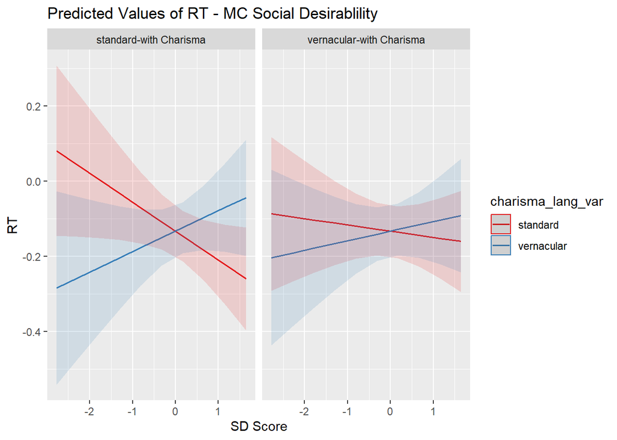

# 4. Ingroup convergence issues, 2nd block diff. Hochdeutsch Dialect-w/oCharisma) - (Dialekt Hochdeutsch-w/oCharisma not sign, 1st block neither

```
## Linear mixed model fit by REML. t-tests use Satterthwaite's method [
## lmerModLmerTest]
## Formula: penal_RTs ~ charisma_lang_var * start_iat + trialcount + age +
##     (1 | bilendi_id) + (1 | stimulus_ID)
##    Data: Four_In
## Control: lmerControl(optimizer = "bobyqa", optCtrl = list(maxfun = 2e+05))
##
## REML criterion at convergence: 11273.2
##
## Scaled residuals:
##     Min      1Q  Median      3Q     Max
## -2.5081 -0.6194 -0.1732  0.4721  7.5383
##
## Random effects:
##  Groups      Name        Variance Std.Dev.
##  stimulus_ID (Intercept) 0.05302  0.2303
##  bilendi_id  (Intercept) 0.13849  0.3721
##  Residual                0.73876  0.8595
## Number of obs: 4316, groups:  stimulus_ID, 301; bilendi_id, 36
##
## Fixed effects:
##                                                                 Estimate
## (Intercept)                                                    3.840e-01
## charisma_lang_varvernacular                                    8.199e-01
## start_iatvernacular-with Charisma                              8.316e-01
## trialcount                                                    -7.004e-03
## age                                                            2.350e-01
## charisma_lang_varvernacular:start_iatvernacular-with Charisma -1.417e+00
##                                                               Std. Error
## (Intercept)                                                    1.035e-01
## charisma_lang_varvernacular                                    7.736e-02
## start_iatvernacular-with Charisma                              1.483e-01
## trialcount                                                     7.622e-04
## age                                                            6.395e-02
## charisma_lang_varvernacular:start_iatvernacular-with Charisma  1.472e-01
##                                                                       df
## (Intercept)                                                    7.085e+01
## charisma_lang_varvernacular                                    4.174e+03
## start_iatvernacular-with Charisma                              5.823e+01
## trialcount                                                     4.145e+03
```

[output cut: 11 more lines]

```
## charisma_lang_varvernacular                                   ***
## start_iatvernacular-with Charisma                             ***
## trialcount                                                    ***
## age                                                           ***
## charisma_lang_varvernacular:start_iatvernacular-with Charisma ***
## ---
## Signif. codes:  0 '***' 0.001 '**' 0.01 '*' 0.05 '.' 0.1 ' ' 1
##
## Correlation of Fixed Effects:
##             (Intr) chrs__ str_-C trlcnt age
## chrsm_lng_v  0.380
## strt_tvrn-C -0.261  0.466
## trialcount  -0.519 -0.887 -0.462
## age          0.065  0.000 -0.102  0.000
## chrsm__:_-C -0.441 -0.938 -0.497  0.931  0.000
```

```
## Note: D.f. calculations have been disabled because the number of observations exceeds 3000.
## To enable adjustments, add the argument 'pbkrtest.limit = 4316' (or larger)
## [or, globally, 'set emm_options(pbkrtest.limit = 4316)' or larger];
## but be warned that this may result in large computation time and memory use.
```

```
## Note: D.f. calculations have been disabled because the number of observations exceeds 3000.
## To enable adjustments, add the argument 'lmerTest.limit = 4316' (or larger)
## [or, globally, 'set emm_options(lmerTest.limit = 4316)' or larger];
## but be warned that this may result in large computation time and memory use.
```

```
## $emmeans
##  charisma_lang_var start_iat                emmean     SE  df asymp.LCL
##  standard          standard-with Charisma   -0.425 0.0949 Inf    -0.611
##  vernacular        standard-with Charisma    0.395 0.0949 Inf     0.209
##  standard          vernacular-with Charisma  0.406 0.1045 Inf     0.202
##  vernacular        vernacular-with Charisma -0.191 0.1046 Inf    -0.396
##  asymp.UCL
##     -0.239
##      0.581
##      0.611
##      0.014
##
## Degrees-of-freedom method: asymptotic
## Confidence level used: 0.95
##
## $contrasts
##  contrast
##  (standard standard-with Charisma) - (vernacular standard-with Charisma)
##  (standard standard-with Charisma) - (standard vernacular-with Charisma)
##  (standard standard-with Charisma) - (vernacular vernacular-with Charisma)
##  (vernacular standard-with Charisma) - (standard vernacular-with Charisma)
##  (vernacular standard-with Charisma) - (vernacular vernacular-with Charisma)
##  (standard vernacular-with Charisma) - (vernacular vernacular-with Charisma)
##  estimate     SE  df z.ratio p.value
##   -0.8199 0.0774 Inf -10.599  <.0001
##   -0.8316 0.1483 Inf  -5.606  <.0001
##   -0.2343 0.1315 Inf  -1.781  0.2823
##   -0.0117 0.1315 Inf  -0.089  0.9997
##    0.5856 0.1483 Inf   3.949  0.0005
##    0.5973 0.0793 Inf   7.532  <.0001
##
## Degrees-of-freedom method: asymptotic
## P value adjustment: tukey method for comparing a family of 4 estimates
```

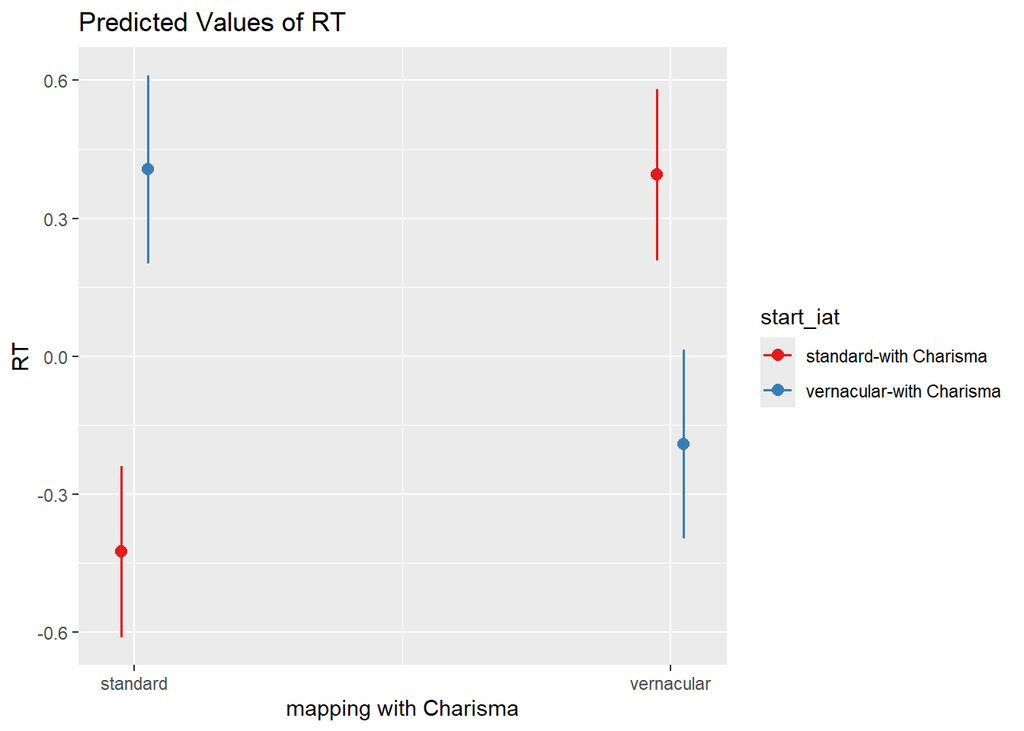